# Analyses in Perceiving through the Grapevine: A Network Approach to Reputations

Cory K. Costello & Sanjay Srivastava

last knitted: 2019-08-09 18:50:30

# Data & Libraries

Here I’ll read in the data and load the libraries I’ll use, including the `ReputationModelR` package I created for these analyses.

```r
knitr::opts_chunk$set(message = FALSE, warning = FALSE, cache = TRUE)
# Make sure necessary packages are installed
if("rio" %in% installed.packages()[,1] == FALSE){install.packages("rio")}
if("magrittr" %in% installed.packages()[,1] == FALSE){install.packages("tidyverse")}
if("ReputationModelR" %in% installed.packages()[,1] == FALSE){devtools::install_github("Coryc3133/ReputationModelR")}
library(rio)
library(tidyverse)
library(ReputationModelR)
study1 <- import("Data/rep_s1_4ms.csv")
study2 <- import("Data/rep_s2_4ms.csv") %>%
  # missing condition are "", but need to be NA
  mutate(condition = ifelse(condition == "", NA, condition))
```

## Calculate Scale Scores

Here I’ll score the BFI into domain scores and the IRI into its subscales. I’ll also produce coefficeint alphas and basic descriptives.

I’m going to use the `scoreItems()` function from the `psych` package. This both reverse scores items and calculates scale scores. It also provide some information about the scores.

### Study 1 Data: Score Big Six Domains

- agreeableness = 2, 7, 12R, 17R, 22R, 27, 32, 37R, 42R, 47R, 52, 57
- conscientiousness = 3R, 8R, 13, 18, 23R, 28R, 33, 38, 43, 48R, 53, 58R
- hp = HP45r HP46r HP47r HP48r HP49r HP50 HP51 HP52
- neuroticism = 4R, 9R, 14, 19, 24R, 29R, 34, 39, 44R, 49R, 54, 59
- extraversion = 1, 6, 11R, 16R, 21, 26R, 31R, 36R, 41, 46, 51R, 56
- openness = 5R, 10, 15, 20, 25R, 30R, 35, 40, 45R, 50R, 55R, 60

For now, first make the key:

```r
# Make keys
big6_keys <- list(
                 agreeableness = c("bfi_2", "bfi_7", "-bfi_12", "-bfi_17",
                                   "-bfi_22", "bfi_27", "bfi_32", "-bfi_37",
                                   "-bfi_42", "-bfi_47", "bfi_52", "bfi_57"),
                 conscientiousness = c("-bfi_3", "-bfi_8", "bfi_13", "bfi_18",
                                       "-bfi_23", "-bfi_28", "bfi_33", "bfi_38",
                                       "bfi_43", "-bfi_48", "bfi_53", "-bfi_58"),
                 hp = c("-bfi_hp45", "-bfi_hp46", "-bfi_hp47", "-bfi_hp48",
                            "-bfi_hp49", "bfi_hp50", "bfi_hp51", "bfi_hp52"),
                 neuroticism = c("-bfi_4", "-bfi_9", "bfi_14", "bfi_19",
                                 "-bfi_24", "-bfi_29", "bfi_34", "bfi_39",
                                 "-bfi_44", "-bfi_49", "bfi_54", "bfi_59"),
                 extraversion = c("bfi_1", "bfi_6", "-bfi_11", "-bfi_16",
                                  "bfi_21", "-bfi_26", "-bfi_31", "-bfi_36",
                                  "bfi_41", "bfi_46", "-bfi_51", "bfi_56"),
                 openness = c("-bfi_5", "bfi_10", "bfi_15", "bfi_20",
                              "-bfi_25", "-bfi_30", "bfi_35", "bfi_40",
                              "-bfi_45", "-bfi_50", "-bfi_55", "bfi_60"))
```

Next, I’ll score the Big Six. I’ll turn the data into long format to make things a little easier, since it’s the same scoring used for all of the Big Six ratings.

```r
# Lengthen Data
study1_big6_long <-
study1 %>%
  select(sess_id, contains("bfi")) %>%
  gather(variable, rating, -sess_id) %>%
  separate(variable,
           c("perceiver", "target", "item"),
           extra = "merge") %>%
  spread(item, rating)

# Score long data and bind the scores to
# the end of the long data, then widen it back out
# and call it study1, replacing the raw data
study1 <-
  psych::scoreItems(big6_keys,
                    items = study1_big6_long,
                    impute = "none") %>%
  .[["scores"]] %>%
  cbind(study1_big6_long, .) %>%
  gather(variable, rating, -(1:3)) %>%
  unite(variable, perceiver, target, variable) %>%
  spread(variable, rating) %>%
  select(sess_id,
         ends_with("agreeableness"),
         ends_with("conscientiousness"),
         ends_with("hp"),
         ends_with("neuroticism"),
         ends_with("extraversion"),
         ends_with("openness")) %>%
  right_join(study1)
```

Finally, I’ll get the coefficient alphas for each subscale.

```r
library(kableExtra)

study1_big6_long %>%
  mutate(rating_type = case_when(perceiver == target ~ "Self",
                               perceiver == "A" & target == "C" |
                                 perceiver == "C" & target == "A" ~ "P1",
                               perceiver == "B" & target == "C" |
                                 perceiver == "D" & target == "A" ~ "P2")) %>%
  split(.$rating_type) %>%
  map_df(~ psych::scoreItems(big6_keys,
                          items = .,
                          impute = "none") %>% pluck("alpha")) %>%
  mutate(domain = names(big6_keys),
         domain = ifelse(domain == "hp", "honesty-propriety", domain)) %>%
  gather(report, alpha, -domain) %>%
  mutate(report = fct_relevel(report,
                              "Self",
                              "P1",
                              "P2")) %>%
  select(report, domain, alpha) %>%
  arrange(report) %>%
  knitr::kable(digits = c(NA, NA, 2),
               caption = "Coefficient Alphas for Big Six Ratings Study 1",
               format = "html", escape = F) %>%
  kable_styling("striped", full_width = F)
```

Coefficient Alphas for Big Six Ratings Study 1

| report | domain | alpha |
| --- | --- | --- |
| Self | agreeableness | 0.76 |
| Self | conscientiousness | 0.83 |
| Self | honesty-propriety | 0.61 |
| Self | neuroticism | 0.89 |
| Self | extraversion | 0.87 |
| Self | openness | 0.81 |
| P1 | agreeableness | 0.80 |
| P1 | conscientiousness | 0.83 |
| P1 | honesty-propriety | 0.66 |
| P1 | neuroticism | 0.75 |
| P1 | extraversion | 0.88 |
| P1 | openness | 0.78 |
| P2 | agreeableness | 0.84 |
| P2 | conscientiousness | 0.89 |
| P2 | honesty-propriety | 0.75 |
| P2 | neuroticism | 0.87 |
| P2 | extraversion | 0.89 |
| P2 | openness | 0.83 |

### Study 1 Data: Calculate scale scores: IRI

- Empathic Concern = q2_emp, q4_empr, q9_emp, q14_empr, q18_empr, q20_emp, q22_emp
- Fantasy Scale = q1_fs, q5_fs, q7_fsr, q12_fsr, q16_fs, q23_fs, q26_fs
- Personal Distress = q6_pd, q10_pd, q13_pdr, q17_pd, q19_pdr, q24_pd, q27_pd
- Perspective Taking = q3_ptr, q8_pt, q11_pt, q15_ptr, q21_pt, q25_pt, q28_pt

Using the `scoreItems()` function from the psych package again. Then, Ill save out and cbind the scores to the data, and produce a table for the alphas.

First make the key:

```r
iri_keys <- list(
  iri_empathic = c("q2_emp", "-q4_emp", "q9_emp", "-q14_emp", "-q18_emp", "q20_emp", "q22_emp"),
  iri_fantasy = c("q1_fs", "q5_fs", "-q7_fs", "-q12_fs", "q16_fs", "q23_fs", "q26_fs"),
  iri_distress = c("q6_pd", "q10_pd", "-q13_pd", "q17_pd", "-q19_pd", "q24_pd", "q27_pd"),
  iri_perspective = c("-q3_pt", "q8_pt", "q11_pt", "-q15_pt", "q21_pt", "q25_pt", "q28_pt")
)
```

Next, I’ll score the IRI. I’ll turn the data into long format like above with the Big Six.

```r
# Lengthen Data
study1_iri_long <-
study1 %>%
  select(sess_id, starts_with("B_q"), starts_with("D_q")) %>%
  gather(variable, rating, -sess_id) %>%
  separate(variable,
           c("perceiver", "item"),
           extra = "merge") %>%
  spread(item, rating)

# Score long data and bind the scores to
# the end of the long data, then widen it back out
# and call it study1, replacing the raw data
study1 <-
  psych::scoreItems(iri_keys,
                    items = study1_iri_long,
                    impute = "none") %>%
  .[["scores"]] %>%
  cbind(study1_iri_long, .) %>%
  gather(variable, rating, -(1:3)) %>%
  unite(variable, perceiver, variable) %>%
  spread(variable, rating) %>%
  select(sess_id, contains("iri")) %>%
  right_join(study1)
```

Finally, I’ll get the coefficient alphas for each subscale.

```r
library(kableExtra)

 psych::scoreItems(iri_keys,
                    items = study1_iri_long,
                    impute = "none") %>%
  .[["alpha"]] %>%
   as_tibble() %>%
   gather(subscale, alpha) %>%
   mutate(subscale =
            case_when(subscale == "iri_empathic" ~ "empathic concern",
                      subscale == "iri_fantasy" ~ "fantasy",
                      subscale == "iri_distress" ~ "distress tolerance",
                      subscale == "iri_perspective" ~ "perspective taking")) %>%
  knitr::kable(digits = c(NA, 2),
               caption = "Coefficient Alphas for Perspective Taking Study 1",
               format = "html", escape = F) %>%
  kable_styling("striped", full_width = F)
```

Coefficient Alphas for Perspective Taking Study 1

| subscale | alpha |
| --- | --- |
| empathic concern | 0.73 |
| fantasy | 0.82 |
| distress tolerance | 0.82 |
| perspective taking | 0.76 |

### Study 2 Data: Score Big Six Domains

```r
# Lengthen Data
study2_big6_long <-
study2 %>%
  select(sess_id, contains("bfi")) %>%
  gather(variable, rating, -sess_id) %>%
  separate(variable,
           c("perceiver", "target", "item"),
           extra = "merge") %>%
  spread(item, rating)

# Score long data and bind the scores to
# the end of the long data, then widen it back out
# and call it study2, replacing the raw data
study2 <-
  psych::scoreItems(big6_keys,
                    items = study2_big6_long,
                    impute = "none") %>%
  .[["scores"]] %>%
  cbind(study2_big6_long, .) %>%
  gather(variable, rating, -(1:3)) %>%
  unite(variable, perceiver, target, variable) %>%
  spread(variable, rating) %>%
  select(sess_id,
         ends_with("agreeableness"),
         ends_with("conscientiousness"),
         ends_with("hp"),
         ends_with("neuroticism"),
         ends_with("extraversion"),
         ends_with("openness")) %>%
  right_join(study2)
```

Finally, I’ll get the coefficient alphas for each subscale.

```r
library(kableExtra)

study2_big6_long %>%
  mutate(rating_type = case_when(perceiver == target ~ "Self",
                               perceiver == "A" & target == "C" |
                                 perceiver == "C" & target == "A" ~ "P1",
                               perceiver == "B" & target == "C" |
                                 perceiver == "D" & target == "A" ~ "P2")) %>%
  split(.$rating_type) %>%
  map_df(~ psych::scoreItems(big6_keys,
                          items = .,
                          impute = "none") %>% pluck("alpha")) %>%
  mutate(domain = names(big6_keys),
         domain = ifelse(domain == "hp", "honesty-propriety", domain)) %>%
  gather(report, alpha, -domain) %>%
  mutate(report = fct_relevel(report,
                              "Self",
                              "P1",
                              "P2")) %>%
  select(report, domain, alpha) %>%
  arrange(report) %>%
  knitr::kable(digits = c(NA, NA, 2),
               caption = "Coefficient Alphas for Big Six Ratings Study 2",
               format = "html", escape = F) %>%
  kable_styling("striped", full_width = F)
```

Coefficient Alphas for Big Six Ratings Study 2

| report | domain | alpha |
| --- | --- | --- |
| Self | agreeableness | 0.76 |
| Self | conscientiousness | 0.86 |
| Self | honesty-propriety | 0.62 |
| Self | neuroticism | 0.88 |
| Self | extraversion | 0.87 |
| Self | openness | 0.81 |
| P1 | agreeableness | 0.82 |
| P1 | conscientiousness | 0.88 |
| P1 | honesty-propriety | 0.76 |
| P1 | neuroticism | 0.84 |
| P1 | extraversion | 0.88 |
| P1 | openness | 0.87 |
| P2 | agreeableness | 0.83 |
| P2 | conscientiousness | 0.91 |
| P2 | honesty-propriety | 0.79 |
| P2 | neuroticism | 0.83 |
| P2 | extraversion | 0.91 |
| P2 | openness | 0.77 |

### Study 2 Data: Calculate scale scores: IRI

Same keys as before

Next, I’ll score the IRI. I’ll turn the data into long format like above with the Big Six.

```r
# Lengthen Data
study2_iri_long <-
study2 %>%
  select(sess_id, starts_with("B_q"), starts_with("D_q")) %>%
  gather(variable, rating, -sess_id) %>%
  separate(variable,
           c("perceiver", "item"),
           extra = "merge") %>%
  spread(item, rating)

# Score long data and bind the scores to
# the end of the long data, then widen it back out
# and call it study2, replacing the raw data
study2 <-
  psych::scoreItems(iri_keys,
                    items = study2_iri_long,
                    impute = "none") %>%
  .[["scores"]] %>%
  cbind(study2_iri_long, .) %>%
  gather(variable, rating, -(1:3)) %>%
  unite(variable, perceiver, variable) %>%
  spread(variable, rating) %>%
  select(sess_id, contains("iri")) %>%
  right_join(study2)
```

Finally, I’ll get the coefficient alphas for each subscale.

```r
library(kableExtra)

 psych::scoreItems(iri_keys,
                    items = study2_iri_long,
                    impute = "none") %>%
  .[["alpha"]] %>%
   as_tibble() %>%
   gather(subscale, alpha) %>%
   mutate(subscale =
            case_when(subscale == "iri_empathic" ~ "empathic concern",
                      subscale == "iri_fantasy" ~ "fantasy",
                      subscale == "iri_distress" ~ "distress tolerance",
                      subscale == "iri_perspective" ~ "perspective taking")) %>%
  knitr::kable(digits = c(NA, 2),
               caption = "Coefficient Alphas for Perspective Taking Study 2",
               format = "html", escape = F) %>%
  kable_styling("striped", full_width = F)
```

Coefficient Alphas for Perspective Taking Study 2

| subscale | alpha |
| --- | --- |
| empathic concern | 0.70 |
| fantasy | 0.82 |
| distress tolerance | 0.78 |
| perspective taking | 0.75 |

## Individual Difference Moderator Data Prep Study 1

Next up, prepping data for the individual difference moderators. These analyses require first mean-centering predictors and creating interaction terms, which the next chunk of code does.

```r
study1 <-
study1 %>%
  # First, mean center the predictors,
  # since this is a continuous by continuous interaction.
  # We'll do this scale()
  mutate(
    # first, mean center P2 ratings for each domain
    B_C_extraversion_cent      = scale(B_C_extraversion, scale = FALSE),
    D_A_extraversion_cent      = scale(D_A_extraversion, scale = FALSE),
    B_C_agreeableness_cent     = scale(B_C_agreeableness, scale = FALSE),
    D_A_agreeableness_cent     = scale(D_A_agreeableness, scale = FALSE),
    B_C_conscientiousness_cent = scale(B_C_conscientiousness, scale = FALSE),
    D_A_conscientiousness_cent = scale(D_A_conscientiousness, scale = FALSE),
    B_C_neuroticism_cent       = scale(B_C_neuroticism, scale = FALSE),
    D_A_neuroticism_cent       = scale(D_A_neuroticism, scale = FALSE),
    B_C_openness_cent          = scale(B_C_openness, scale = FALSE),
    D_A_openness_cent          = scale(D_A_openness, scale = FALSE),
    B_C_hp_cent                = scale(B_C_hp, scale = FALSE),
    D_A_hp_cent                = scale(D_A_hp, scale = FALSE),
    # next, mean center empathy subscales (only have B and D for this)
    # this is a proposed moderator of consensus/accuracy
    B_iri_perspective_cent     = scale(B_iri_perspective, scale = FALSE),
    D_iri_perspective_cent     = scale(D_iri_perspective, scale = FALSE),
    B_iri_empathic_cent        = scale(B_iri_empathic, scale = FALSE),
    D_iri_empathic_cent        = scale(D_iri_empathic, scale = FALSE),
    B_iri_distress_cent        = scale(B_iri_distress, scale = FALSE),
    D_iri_distress_cent        = scale(D_iri_distress, scale = FALSE),
    B_iri_fantasy_cent         = scale(B_iri_fantasy, scale = FALSE),
    D_iri_fantasy_cent         = scale(D_iri_fantasy, scale = FALSE),
    # mean center self-reported extraversion
    # this is a proposed moderator of consensus/accuracy
    A_A_extraversion_cent      = scale(A_A_extraversion, scale = FALSE),
    C_C_extraversion_cent      = scale(C_C_extraversion, scale = FALSE),
    A_C_extraversion_cent      = scale(A_C_extraversion, scale = FALSE),
    C_A_extraversion_cent      = scale(C_A_extraversion, scale = FALSE),
    B_B_extraversion_cent      = scale(B_B_extraversion, scale = FALSE),
    D_D_extraversion_cent      = scale(D_D_extraversion, scale = FALSE)) %>%
  # Next, create interaction terms
  mutate(
    # Extraversion moderators (for extraversion)
    extraXextra_AB = A_A_extraversion_cent*B_C_extraversion_cent,
    extraXextra_CD = C_C_extraversion_cent*D_A_extraversion_cent,
    extraXextra_BB = B_B_extraversion_cent*B_C_extraversion_cent,
    extraXextra_DD = D_D_extraversion_cent*D_A_extraversion_cent,
    extraXextra_CB = C_C_extraversion_cent*B_C_extraversion_cent,
    extraXextra_AD = A_A_extraversion_cent*D_A_extraversion_cent,
    # Extraversion moderators (for agreeableness)
    extraXagree_AB = A_A_extraversion_cent*B_C_agreeableness_cent,
    extraXagree_CD = C_C_extraversion_cent*D_A_agreeableness_cent,
    extraXagree_BB = B_B_extraversion_cent*B_C_agreeableness_cent,
    extraXagree_DD = D_D_extraversion_cent*D_A_agreeableness_cent,
    extraXagree_CB = C_C_extraversion_cent*B_C_agreeableness_cent,
    extraXagree_AD = A_A_extraversion_cent*D_A_agreeableness_cent,
    # Extraversion moderators (for conscientiousness)
    extraXconsc_AB = A_A_extraversion_cent*B_C_conscientiousness_cent,
    extraXconsc_CD = C_C_extraversion_cent*D_A_conscientiousness_cent,
    extraXconsc_BB = B_B_extraversion_cent*B_C_conscientiousness_cent,
    extraXconsc_DD = D_D_extraversion_cent*D_A_conscientiousness_cent,
    extraXconsc_CB = C_C_extraversion_cent*B_C_conscientiousness_cent,
    extraXconsc_AD = A_A_extraversion_cent*D_A_conscientiousness_cent,
    # Extraversion moderators (for Neuroticism)
    extraXneuro_AB = A_A_extraversion_cent*B_C_neuroticism_cent,
    extraXneuro_CD = C_C_extraversion_cent*D_A_neuroticism_cent,
    extraXneuro_BB = B_B_extraversion_cent*B_C_neuroticism_cent,
    extraXneuro_DD = D_D_extraversion_cent*D_A_neuroticism_cent,
    extraXneuro_CB = C_C_extraversion_cent*B_C_neuroticism_cent,
    extraXneuro_AD = A_A_extraversion_cent*D_A_neuroticism_cent,
    # Extraversion moderators (for Openness)
    extraXopen_AB = A_A_extraversion_cent*B_C_openness_cent,
    extraXopen_CD = C_C_extraversion_cent*D_A_openness_cent,
    extraXopen_BB = B_B_extraversion_cent*B_C_openness_cent,
    extraXopen_DD = D_D_extraversion_cent*D_A_openness_cent,
    extraXopen_CB = C_C_extraversion_cent*B_C_openness_cent,
    extraXopen_AD = A_A_extraversion_cent*D_A_openness_cent,
    # Extraversion moderators (for HP)
    extraXhp_AB = A_A_extraversion_cent*B_C_hp_cent,
    extraXhp_CD = C_C_extraversion_cent*D_A_hp_cent,
    extraXhp_BB = B_B_extraversion_cent*B_C_hp_cent,
    extraXhp_DD = D_D_extraversion_cent*D_A_hp_cent,
    extraXhp_CB = C_C_extraversion_cent*B_C_hp_cent,
    extraXhp_AD = A_A_extraversion_cent*D_A_hp_cent,
    # perspective taking moderators (for extraversion)
    PTxE_B = B_iri_perspective_cent*B_C_extraversion_cent,
    PTxE_D = D_iri_perspective_cent*D_A_extraversion_cent,
    # perspective taking moderators (for agreeableness)
    PTxA_B = B_iri_perspective_cent*B_C_agreeableness_cent,
    PTxA_D = D_iri_perspective_cent*D_A_agreeableness_cent,
    # perspective taking moderators (for conscientiousness)
    PTxC_B = B_iri_perspective_cent*B_C_conscientiousness_cent,
    PTxC_D = D_iri_perspective_cent*D_A_conscientiousness_cent,
    # perspective taking moderators (for neuroticism)
    PTxN_B = B_iri_perspective_cent*B_C_neuroticism_cent,
    PTxN_D = D_iri_perspective_cent*D_A_neuroticism_cent,
    # perspective taking moderators (for openness)
    PTxO_B = B_iri_perspective_cent*B_C_openness_cent,
    PTxO_D = D_iri_perspective_cent*D_A_openness_cent,
    # perspective taking moderators (for hp)
    PTxHP_B = B_iri_perspective_cent*B_C_hp_cent,
    PTxHP_D = D_iri_perspective_cent*D_A_hp_cent,
    # empathic concern moderators (for extraversion)
    empxE_B = B_iri_empathic_cent*B_C_extraversion_cent,
    empxE_D = D_iri_empathic_cent*D_A_extraversion_cent,
    # empathic concern moderators (for agreeableness)
    empxA_B = B_iri_empathic_cent*B_C_agreeableness_cent,
    empxA_D = D_iri_empathic_cent*D_A_agreeableness_cent,
    # empathic concern moderators (for conscientiousness)
    empxC_B = B_iri_empathic_cent*B_C_conscientiousness_cent,
    empxC_D = D_iri_empathic_cent*D_A_conscientiousness_cent,
    # empathic concern moderators (for neuroticism)
    empxN_B = B_iri_empathic_cent*B_C_neuroticism_cent,
    empxN_D = D_iri_empathic_cent*D_A_neuroticism_cent,
    # empathic concern moderators (for openness)
    empxO_B = B_iri_empathic_cent*B_C_openness_cent,
    empxO_D = D_iri_empathic_cent*D_A_openness_cent,
    # empathic concern moderators (for hp)
    empxHP_B = B_iri_empathic_cent*B_C_hp_cent,
    empxHP_D = D_iri_empathic_cent*D_A_hp_cent,
    # personal distress moderators (for extraversion)
    disxE_B = B_iri_distress_cent*B_C_extraversion_cent,
    disxE_D = D_iri_distress_cent*D_A_extraversion_cent,
    # personal distress moderators (for agreeableness)
    disxA_B = B_iri_distress_cent*B_C_agreeableness_cent,
    disxA_D = D_iri_distress_cent*D_A_agreeableness_cent,
    # personal distress moderators (for conscientiousness)
    disxC_B = B_iri_distress_cent*B_C_conscientiousness_cent,
    disxC_D = D_iri_distress_cent*D_A_conscientiousness_cent,
    # personal distress moderators (for neuroticism)
    disxN_B = B_iri_distress_cent*B_C_neuroticism_cent,
    disxN_D = D_iri_distress_cent*D_A_neuroticism_cent,
    # personal distress moderators (for openness)
    disxO_B = B_iri_distress_cent*B_C_openness_cent,
    disxO_D = D_iri_distress_cent*D_A_openness_cent,
    # personal distress moderators (for hp)
    disxHP_B = B_iri_distress_cent*B_C_hp_cent,
    disxHP_D = D_iri_distress_cent*D_A_hp_cent,
    # fantasy moderators (for extraversion)
    fantxE_B = B_iri_fantasy_cent*B_C_extraversion_cent,
    fantxE_D = D_iri_fantasy_cent*D_A_extraversion_cent,
    # fantasy moderators (for agreeableness)
    fantxA_B = B_iri_fantasy_cent*B_C_agreeableness_cent,
    fantxA_D = D_iri_fantasy_cent*D_A_agreeableness_cent,
    # fantasy moderators (for conscientiousness)
    fantxC_B = B_iri_fantasy_cent*B_C_conscientiousness_cent,
    fantxC_D = D_iri_fantasy_cent*D_A_conscientiousness_cent,
    # fantasy moderators (for neuroticism)
    fantxN_B = B_iri_fantasy_cent*B_C_neuroticism_cent,
    fantxN_D = D_iri_fantasy_cent*D_A_neuroticism_cent,
    # fantasy moderators (for openness)
    fantxO_B = B_iri_fantasy_cent*B_C_openness_cent,
    fantxO_D = D_iri_fantasy_cent*D_A_openness_cent,
    # fantasy moderators (for hp)
    fantxHP_B = B_iri_fantasy_cent*B_C_hp_cent,
    fantxHP_D = D_iri_fantasy_cent*D_A_hp_cent)
```

## Individual Difference Moderator Data Prep in Study 2

Next, prep for the individual difference moderators for Study 2, same as Study 1.

```r
study2 <-
study2 %>%
  # First, mean center the predictors,
  # since this is a continuous by continuous interaction.
  # We'll do this scale()
  mutate(
    # first, mean center P2 ratings for each domain
    B_C_extraversion_cent      = scale(B_C_extraversion, scale = FALSE),
    D_A_extraversion_cent      = scale(D_A_extraversion, scale = FALSE),
    B_C_agreeableness_cent     = scale(B_C_agreeableness, scale = FALSE),
    D_A_agreeableness_cent     = scale(D_A_agreeableness, scale = FALSE),
    B_C_conscientiousness_cent = scale(B_C_conscientiousness, scale = FALSE),
    D_A_conscientiousness_cent = scale(D_A_conscientiousness, scale = FALSE),
    B_C_neuroticism_cent       = scale(B_C_neuroticism, scale = FALSE),
    D_A_neuroticism_cent       = scale(D_A_neuroticism, scale = FALSE),
    B_C_openness_cent          = scale(B_C_openness, scale = FALSE),
    D_A_openness_cent          = scale(D_A_openness, scale = FALSE),
    B_C_hp_cent                = scale(B_C_hp, scale = FALSE),
    D_A_hp_cent                = scale(D_A_hp, scale = FALSE),
    # next, mean center empathy subscales (only have B and D for this)
    # this is a proposed moderator of consensus/accuracy
    B_iri_perspective_cent     = scale(B_iri_perspective, scale = FALSE),
    D_iri_perspective_cent     = scale(D_iri_perspective, scale = FALSE),
    B_iri_empathic_cent        = scale(B_iri_empathic, scale = FALSE),
    D_iri_empathic_cent        = scale(D_iri_empathic, scale = FALSE),
    B_iri_distress_cent        = scale(B_iri_distress, scale = FALSE),
    D_iri_distress_cent        = scale(D_iri_distress, scale = FALSE),
    B_iri_fantasy_cent         = scale(B_iri_fantasy, scale = FALSE),
    D_iri_fantasy_cent         = scale(D_iri_fantasy, scale = FALSE),
    # mean center self-reported extraversion
    # this is a proposed moderator of consensus/accuracy
    A_A_extraversion_cent      = scale(A_A_extraversion, scale = FALSE),
    C_C_extraversion_cent      = scale(C_C_extraversion, scale = FALSE),
    A_C_extraversion_cent      = scale(A_C_extraversion, scale = FALSE),
    C_A_extraversion_cent      = scale(C_A_extraversion, scale = FALSE),
    B_B_extraversion_cent      = scale(B_B_extraversion, scale = FALSE),
    D_D_extraversion_cent      = scale(D_D_extraversion, scale = FALSE)) %>%
  # Next, create interaction terms
  mutate(
    # Extraversion moderators (for extraversion)
    extraXextra_AB = A_A_extraversion_cent*B_C_extraversion_cent,
    extraXextra_CD = C_C_extraversion_cent*D_A_extraversion_cent,
    extraXextra_BB = B_B_extraversion_cent*B_C_extraversion_cent,
    extraXextra_DD = D_D_extraversion_cent*D_A_extraversion_cent,
    extraXextra_CB = C_C_extraversion_cent*B_C_extraversion_cent,
    extraXextra_AD = A_A_extraversion_cent*D_A_extraversion_cent,
    # Extraversion moderators (for agreeableness)
    extraXagree_AB = A_A_extraversion_cent*B_C_agreeableness_cent,
    extraXagree_CD = C_C_extraversion_cent*D_A_agreeableness_cent,
    extraXagree_BB = B_B_extraversion_cent*B_C_agreeableness_cent,
    extraXagree_DD = D_D_extraversion_cent*D_A_agreeableness_cent,
    extraXagree_CB = C_C_extraversion_cent*B_C_agreeableness_cent,
    extraXagree_AD = A_A_extraversion_cent*D_A_agreeableness_cent,
    # Extraversion moderators (for conscientiousness)
    extraXconsc_AB = A_A_extraversion_cent*B_C_conscientiousness_cent,
    extraXconsc_CD = C_C_extraversion_cent*D_A_conscientiousness_cent,
    extraXconsc_BB = B_B_extraversion_cent*B_C_conscientiousness_cent,
    extraXconsc_DD = D_D_extraversion_cent*D_A_conscientiousness_cent,
    extraXconsc_CB = C_C_extraversion_cent*B_C_conscientiousness_cent,
    extraXconsc_AD = A_A_extraversion_cent*D_A_conscientiousness_cent,
    # Extraversion moderators (for Neuroticism)
    extraXneuro_AB = A_A_extraversion_cent*B_C_neuroticism_cent,
    extraXneuro_CD = C_C_extraversion_cent*D_A_neuroticism_cent,
    extraXneuro_BB = B_B_extraversion_cent*B_C_neuroticism_cent,
    extraXneuro_DD = D_D_extraversion_cent*D_A_neuroticism_cent,
    extraXneuro_CB = C_C_extraversion_cent*B_C_neuroticism_cent,
    extraXneuro_AD = A_A_extraversion_cent*D_A_neuroticism_cent,
    # Extraversion moderators (for Openness)
    extraXopen_AB = A_A_extraversion_cent*B_C_openness_cent,
    extraXopen_CD = C_C_extraversion_cent*D_A_openness_cent,
    extraXopen_BB = B_B_extraversion_cent*B_C_openness_cent,
    extraXopen_DD = D_D_extraversion_cent*D_A_openness_cent,
    extraXopen_CB = C_C_extraversion_cent*B_C_openness_cent,
    extraXopen_AD = A_A_extraversion_cent*D_A_openness_cent,
    # Extraversion moderators (for HP)
    extraXhp_AB = A_A_extraversion_cent*B_C_hp_cent,
    extraXhp_CD = C_C_extraversion_cent*D_A_hp_cent,
    extraXhp_BB = B_B_extraversion_cent*B_C_hp_cent,
    extraXhp_DD = D_D_extraversion_cent*D_A_hp_cent,
    extraXhp_CB = C_C_extraversion_cent*B_C_hp_cent,
    extraXhp_AD = A_A_extraversion_cent*D_A_hp_cent,
    # perspective taking moderators (for extraversion)
    PTxE_B = B_iri_perspective_cent*B_C_extraversion_cent,
    PTxE_D = D_iri_perspective_cent*D_A_extraversion_cent,
    # perspective taking moderators (for agreeableness)
    PTxA_B = B_iri_perspective_cent*B_C_agreeableness_cent,
    PTxA_D = D_iri_perspective_cent*D_A_agreeableness_cent,
    # perspective taking moderators (for conscientiousness)
    PTxC_B = B_iri_perspective_cent*B_C_conscientiousness_cent,
    PTxC_D = D_iri_perspective_cent*D_A_conscientiousness_cent,
    # perspective taking moderators (for neuroticism)
    PTxN_B = B_iri_perspective_cent*B_C_neuroticism_cent,
    PTxN_D = D_iri_perspective_cent*D_A_neuroticism_cent,
    # perspective taking moderators (for openness)
    PTxO_B = B_iri_perspective_cent*B_C_openness_cent,
    PTxO_D = D_iri_perspective_cent*D_A_openness_cent,
    # perspective taking moderators (for hp)
    PTxHP_B = B_iri_perspective_cent*B_C_hp_cent,
    PTxHP_D = D_iri_perspective_cent*D_A_hp_cent,
    # empathic concern moderators (for extraversion)
    empxE_B = B_iri_empathic_cent*B_C_extraversion_cent,
    empxE_D = D_iri_empathic_cent*D_A_extraversion_cent,
    # empathic concern moderators (for agreeableness)
    empxA_B = B_iri_empathic_cent*B_C_agreeableness_cent,
    empxA_D = D_iri_empathic_cent*D_A_agreeableness_cent,
    # empathic concern moderators (for conscientiousness)
    empxC_B = B_iri_empathic_cent*B_C_conscientiousness_cent,
    empxC_D = D_iri_empathic_cent*D_A_conscientiousness_cent,
    # empathic concern moderators (for neuroticism)
    empxN_B = B_iri_empathic_cent*B_C_neuroticism_cent,
    empxN_D = D_iri_empathic_cent*D_A_neuroticism_cent,
    # empathic concern moderators (for openness)
    empxO_B = B_iri_empathic_cent*B_C_openness_cent,
    empxO_D = D_iri_empathic_cent*D_A_openness_cent,
    # empathic concern moderators (for hp)
    empxHP_B = B_iri_empathic_cent*B_C_hp_cent,
    empxHP_D = D_iri_empathic_cent*D_A_hp_cent,
    # personal distress moderators (for extraversion)
    disxE_B = B_iri_distress_cent*B_C_extraversion_cent,
    disxE_D = D_iri_distress_cent*D_A_extraversion_cent,
    # personal distress moderators (for agreeableness)
    disxA_B = B_iri_distress_cent*B_C_agreeableness_cent,
    disxA_D = D_iri_distress_cent*D_A_agreeableness_cent,
    # personal distress moderators (for conscientiousness)
    disxC_B = B_iri_distress_cent*B_C_conscientiousness_cent,
    disxC_D = D_iri_distress_cent*D_A_conscientiousness_cent,
    # personal distress moderators (for neuroticism)
    disxN_B = B_iri_distress_cent*B_C_neuroticism_cent,
    disxN_D = D_iri_distress_cent*D_A_neuroticism_cent,
    # personal distress moderators (for openness)
    disxO_B = B_iri_distress_cent*B_C_openness_cent,
    disxO_D = D_iri_distress_cent*D_A_openness_cent,
    # personal distress moderators (for hp)
    disxHP_B = B_iri_distress_cent*B_C_hp_cent,
    disxHP_D = D_iri_distress_cent*D_A_hp_cent,
    # fantasy moderators (for extraversion)
    fantxE_B = B_iri_fantasy_cent*B_C_extraversion_cent,
    fantxE_D = D_iri_fantasy_cent*D_A_extraversion_cent,
    # fantasy moderators (for agreeableness)
    fantxA_B = B_iri_fantasy_cent*B_C_agreeableness_cent,
    fantxA_D = D_iri_fantasy_cent*D_A_agreeableness_cent,
    # fantasy moderators (for conscientiousness)
    fantxC_B = B_iri_fantasy_cent*B_C_conscientiousness_cent,
    fantxC_D = D_iri_fantasy_cent*D_A_conscientiousness_cent,
    # fantasy moderators (for neuroticism)
    fantxN_B = B_iri_fantasy_cent*B_C_neuroticism_cent,
    fantxN_D = D_iri_fantasy_cent*D_A_neuroticism_cent,
    # fantasy moderators (for openness)
    fantxO_B = B_iri_fantasy_cent*B_C_openness_cent,
    fantxO_D = D_iri_fantasy_cent*D_A_openness_cent,
    # fantasy moderators (for hp)
    fantxHP_B = B_iri_fantasy_cent*B_C_hp_cent,
    fantxHP_D = D_iri_fantasy_cent*D_A_hp_cent)
```

## Combine Data for Integrated Analyses

Last (general)

```r
study1 <- mutate(study1, study = "study 1")
study2 <- mutate(study2, study = "study 2")
integrated <- study2 %>%
  # Remove STudy
  .[, colnames(.) %in% colnames(study1)] %>%
  rbind(study1) %>%
  select(study, sess_id, everything()) %>%
  arrange(study)
```

# Study 1

I’ll start with Study 1. First I’ll fit all of the main models, which will estimate relative elevation and differential hearsay consensus, differential hearsay accuracy, and differential direct accuracy. Then, to match the order of the manuscript, I’ll display the relative elevation results followed by the differential results. This will be followed by the regression analyses; distinctive hearsay accuracy and the moderator analyses, which each require regressions (instead of working with the variance-covariance & mean structure created in the main models).

Study 2 will look similar, but will start with the condition analyses, then the mediation models. The integrated results will be in a similar order to the Study 1 results.

## Fit Models

```r
agree_model <- rep_analyses_auto(study1,
                  p1_reports =  c("A_C_agreeableness", "C_A_agreeableness"),
                  p2_reports =  c("B_C_agreeableness", "D_A_agreeableness"),
                  target_self = c("C_C_agreeableness", "A_A_agreeableness"))
agree_elevation <- ez_elevation_table(agree_model)
agree_differential <- ez_differential_table(agree_model)
summary(agree_model, standardized = TRUE)
```

```
## lavaan 0.6-4 ended normally after 54 iterations
##
##   Optimization method                           NLMINB
##   Number of free parameters                         24
##   Number of equality constraints                     9
##   Row rank of the constraints matrix                 9
##
##                                                   Used       Total
##   Number of observations                           122         124
##   Number of missing patterns                         7
##
##   Estimator                                         ML
##   Model Fit Test Statistic                      37.378
##   Degrees of freedom                                12
##   P-value (Chi-square)                           0.000
##
## Parameter Estimates:
##
##   Information                                 Observed
##   Observed information based on                Hessian
##   Standard Errors                             Standard
##
## Covariances:
##                        Estimate  Std.Err  z-value  P(>|z|)   Std.lv
##   A_C_agreeableness ~~
##     B_C_grb   (hc)        0.056    0.021    2.691    0.007    0.056
##   C_A_agreeableness ~~
##     D_A_grb   (hc)        0.056    0.021    2.691    0.007    0.056
##   C_C_agreeableness ~~
##     B_C_grb   (ha)        0.050    0.022    2.248    0.025    0.050
##   A_A_agreeableness ~~
##     D_A_grb   (ha)        0.050    0.022    2.248    0.025    0.050
##   A_C_agreeableness ~~
##     C_C_grb   (da)        0.067    0.019    3.496    0.000    0.067
##   C_A_agreeableness ~~
##     A_A_grb   (da)        0.067    0.019    3.496    0.000    0.067
##   A_C_agreeableness ~~
##     D_A_grb    (m)        0.035    0.042    0.831    0.406    0.035
##     C_A_grb  (rec)        0.011    0.024    0.456    0.648    0.011
##   B_C_agreeableness ~~
```

[output cut: 40 more lines]

```
##
## Variances:
##                    Estimate  Std.Err  z-value  P(>|z|)   Std.lv  Std.all
##     C_C_grb (v_sl)    0.311    0.029   10.769    0.000    0.311    1.000
##     A_A_grb (v_sl)    0.311    0.029   10.769    0.000    0.311    1.000
##     A_C_grb (v_p1)    0.259    0.024   10.958    0.000    0.259    1.000
##     C_A_grb (v_p1)    0.259    0.024   10.958    0.000    0.259    1.000
##     B_C_grb (v_p2)    0.277    0.029    9.630    0.000    0.277    1.000
##     D_A_grb (v_p2)    0.277    0.029    9.630    0.000    0.277    1.000
##
## Defined Parameters:
##                    Estimate  Std.Err  z-value  P(>|z|)   Std.lv  Std.all
##     p1_p2_rel_el      0.270    0.043    6.339    0.000    0.270    0.771
##     self_p2_rel_el    0.176    0.048    3.657    0.000    0.176   -0.076
##     self_p1_rel_el   -0.094    0.039   -2.404    0.016   -0.094   -0.848
```

### Conscientiousness

```r
consc_model <- rep_analyses_auto(study1,
                  p1_reports =  c("A_C_conscientiousness", "C_A_conscientiousness"),
                  p2_reports =  c("B_C_conscientiousness", "D_A_conscientiousness"),
                  target_self = c("C_C_conscientiousness", "A_A_conscientiousness"))
consc_elevation <- ez_elevation_table(consc_model)
consc_differential <- ez_differential_table(consc_model)
summary(consc_model, standardized = TRUE)
```

```
## lavaan 0.6-4 ended normally after 47 iterations
##
##   Optimization method                           NLMINB
##   Number of free parameters                         24
##   Number of equality constraints                     9
##   Row rank of the constraints matrix                 9
##
##                                                   Used       Total
##   Number of observations                           122         124
##   Number of missing patterns                         7
##
##   Estimator                                         ML
##   Model Fit Test Statistic                      22.549
##   Degrees of freedom                                12
##   P-value (Chi-square)                           0.032
##
## Parameter Estimates:
##
##   Information                                 Observed
##   Observed information based on                Hessian
##   Standard Errors                             Standard
##
## Covariances:
##                            Estimate  Std.Err  z-value  P(>|z|)   Std.lv
##   A_C_conscientiousness ~~
##     B_C_cns   (hc)            0.124    0.025    4.880    0.000    0.124
##   C_A_conscientiousness ~~
##     D_A_cns   (hc)            0.124    0.025    4.880    0.000    0.124
##   C_C_conscientiousness ~~
##     B_C_cns   (ha)            0.048    0.030    1.628    0.104    0.048
##   A_A_conscientiousness ~~
##     D_A_cns   (ha)            0.048    0.030    1.628    0.104    0.048
##   A_C_conscientiousness ~~
##     C_C_cns   (da)            0.060    0.023    2.628    0.009    0.060
##   C_A_conscientiousness ~~
##     A_A_cns   (da)            0.060    0.023    2.628    0.009    0.060
##   A_C_conscientiousness ~~
##     D_A_cns    (m)           -0.090    0.031   -2.876    0.004   -0.090
##     C_A_cns  (rec)            0.003    0.024    0.105    0.916    0.003
##   B_C_conscientiousness ~~
```

[output cut: 40 more lines]

```
##
## Variances:
##                    Estimate  Std.Err  z-value  P(>|z|)   Std.lv  Std.all
##     C_C_cns (v_sl)    0.409    0.038   10.865    0.000    0.409    1.000
##     A_A_cns (v_sl)    0.409    0.038   10.865    0.000    0.409    1.000
##     A_C_cns (v_p1)    0.296    0.027   11.049    0.000    0.296    1.000
##     C_A_cns (v_p1)    0.296    0.027   11.049    0.000    0.296    1.000
##     B_C_cns (v_p2)    0.379    0.039    9.840    0.000    0.379    1.000
##     D_A_cns (v_p2)    0.379    0.039    9.840    0.000    0.379    1.000
##
## Defined Parameters:
##                    Estimate  Std.Err  z-value  P(>|z|)   Std.lv  Std.all
##     p1_p2_rel_el      0.128    0.048    2.656    0.008    0.128    0.992
##     self_p2_rel_el   -0.046    0.053   -0.858    0.391   -0.046   -0.287
##     self_p1_rel_el   -0.174    0.044   -3.962    0.000   -0.174   -1.279
```

### Honesty-Propriety

```r
hp_model <- rep_analyses_auto(study1,
                  p1_reports =  c("A_C_hp", "C_A_hp"),
                  p2_reports =  c("B_C_hp", "D_A_hp"),
                  target_self = c("C_C_hp", "A_A_hp"))
hp_elevation <- ez_elevation_table(hp_model)
hp_differential <- ez_differential_table(hp_model)
summary(hp_model, standardized = TRUE)
```

```
## lavaan 0.6-4 ended normally after 52 iterations
##
##   Optimization method                           NLMINB
##   Number of free parameters                         24
##   Number of equality constraints                     9
##   Row rank of the constraints matrix                 9
##
##                                                   Used       Total
##   Number of observations                           122         124
##   Number of missing patterns                         7
##
##   Estimator                                         ML
##   Model Fit Test Statistic                      18.273
##   Degrees of freedom                                12
##   P-value (Chi-square)                           0.108
##
## Parameter Estimates:
##
##   Information                                 Observed
##   Observed information based on                Hessian
##   Standard Errors                             Standard
##
## Covariances:
##                    Estimate  Std.Err  z-value  P(>|z|)   Std.lv  Std.all
##   A_C_hp ~~
##     B_C_hp    (hc)    0.090    0.021    4.396    0.000    0.090    0.329
##   C_A_hp ~~
##     D_A_hp    (hc)    0.090    0.021    4.396    0.000    0.090    0.329
##   C_C_hp ~~
##     B_C_hp    (ha)    0.018    0.025    0.720    0.471    0.018    0.057
##   A_A_hp ~~
##     D_A_hp    (ha)    0.018    0.025    0.720    0.471    0.018    0.057
##   A_C_hp ~~
##     C_C_hp    (da)    0.033    0.019    1.692    0.091    0.033    0.115
##   C_A_hp ~~
##     A_A_hp    (da)    0.033    0.019    1.692    0.091    0.033    0.115
##   A_C_hp ~~
##     D_A_hp     (m)   -0.061    0.033   -1.849    0.065   -0.061   -0.223
##     C_A_hp   (rec)   -0.027    0.022   -1.248    0.212   -0.027   -0.108
##   B_C_hp ~~
```

[output cut: 16 more lines]

```
##
## Variances:
##                    Estimate  Std.Err  z-value  P(>|z|)   Std.lv  Std.all
##     C_C_hp  (v_sl)    0.325    0.030   10.805    0.000    0.325    1.000
##     A_A_hp  (v_sl)    0.325    0.030   10.805    0.000    0.325    1.000
##     A_C_hp  (v_p1)    0.250    0.023   11.032    0.000    0.250    1.000
##     C_A_hp  (v_p1)    0.250    0.023   11.032    0.000    0.250    1.000
##     B_C_hp  (v_p2)    0.301    0.031    9.776    0.000    0.301    1.000
##     D_A_hp  (v_p2)    0.301    0.031    9.776    0.000    0.301    1.000
##
## Defined Parameters:
##                    Estimate  Std.Err  z-value  P(>|z|)   Std.lv  Std.all
##     p1_p2_rel_el      0.365    0.043    8.399    0.000    0.365    1.342
##     self_p2_rel_el    0.302    0.050    6.095    0.000    0.302    0.303
##     self_p1_rel_el   -0.063    0.041   -1.513    0.130   -0.063   -1.038
```

### Neuroticism

```r
neuro_model <- rep_analyses_auto(study1,
                  p1_reports =  c("A_C_neuroticism", "C_A_neuroticism"),
                  p2_reports =  c("B_C_neuroticism", "D_A_neuroticism"),
                  target_self = c("C_C_neuroticism", "A_A_neuroticism"))
neuro_elevation <- ez_elevation_table(neuro_model)
neuro_differential <- ez_differential_table(neuro_model)
summary(neuro_model, standardized = TRUE)
```

```
## lavaan 0.6-4 ended normally after 36 iterations
##
##   Optimization method                           NLMINB
##   Number of free parameters                         24
##   Number of equality constraints                     9
##   Row rank of the constraints matrix                 9
##
##                                                   Used       Total
##   Number of observations                           122         124
##   Number of missing patterns                         7
##
##   Estimator                                         ML
##   Model Fit Test Statistic                      25.257
##   Degrees of freedom                                12
##   P-value (Chi-square)                           0.014
##
## Parameter Estimates:
##
##   Information                                 Observed
##   Observed information based on                Hessian
##   Standard Errors                             Standard
##
## Covariances:
##                      Estimate  Std.Err  z-value  P(>|z|)   Std.lv  Std.all
##   A_C_neuroticism ~~
##     B_C_nrt   (hc)      0.109    0.022    4.910    0.000    0.109    0.357
##   C_A_neuroticism ~~
##     D_A_nrt   (hc)      0.109    0.022    4.910    0.000    0.109    0.357
##   C_C_neuroticism ~~
##     B_C_nrt   (ha)      0.067    0.037    1.789    0.074    0.067    0.129
##   A_A_neuroticism ~~
##     D_A_nrt   (ha)      0.067    0.037    1.789    0.074    0.067    0.129
##   A_C_neuroticism ~~
##     C_C_nrt   (da)      0.077    0.028    2.781    0.005    0.077    0.186
##   C_A_neuroticism ~~
##     A_A_nrt   (da)      0.077    0.028    2.781    0.005    0.077    0.186
##   A_C_neuroticism ~~
##     D_A_nrt    (m)      0.086    0.037    2.291    0.022    0.086    0.282
##     C_A_nrt  (rec)     -0.013    0.021   -0.614    0.539   -0.013   -0.053
##   B_C_neuroticism ~~
```

[output cut: 16 more lines]

```
##
## Variances:
##                    Estimate  Std.Err  z-value  P(>|z|)   Std.lv  Std.all
##     C_C_nrt (v_sl)    0.712    0.065   10.967    0.000    0.712    1.000
##     A_A_nrt (v_sl)    0.712    0.065   10.967    0.000    0.712    1.000
##     A_C_nrt (v_p1)    0.244    0.022   10.890    0.000    0.244    1.000
##     C_A_nrt (v_p1)    0.244    0.022   10.890    0.000    0.244    1.000
##     B_C_nrt (v_p2)    0.378    0.040    9.444    0.000    0.378    1.000
##     D_A_nrt (v_p2)    0.378    0.040    9.444    0.000    0.378    1.000
##
## Defined Parameters:
##                    Estimate  Std.Err  z-value  P(>|z|)   Std.lv  Std.all
##     p1_p2_rel_el     -0.204    0.037   -5.487    0.000   -0.204    0.674
##     self_p2_rel_el    0.140    0.064    2.191    0.028    0.140   -1.043
##     self_p1_rel_el    0.344    0.057    6.038    0.000    0.344   -1.716
```

### Extraversion

```r
extra_model <- rep_analyses_auto(study1,
                  p1_reports =  c("A_C_extraversion", "C_A_extraversion"),
                  p2_reports =  c("B_C_extraversion", "D_A_extraversion"),
                  target_self = c("C_C_extraversion", "A_A_extraversion"))
extra_elevation <- ez_elevation_table(extra_model)
extra_differential <- ez_differential_table(extra_model)
summary(extra_model, standardized = TRUE)
```

```
## lavaan 0.6-4 ended normally after 38 iterations
##
##   Optimization method                           NLMINB
##   Number of free parameters                         24
##   Number of equality constraints                     9
##   Row rank of the constraints matrix                 9
##
##                                                   Used       Total
##   Number of observations                           122         124
##   Number of missing patterns                         7
##
##   Estimator                                         ML
##   Model Fit Test Statistic                      24.616
##   Degrees of freedom                                12
##   P-value (Chi-square)                           0.017
##
## Parameter Estimates:
##
##   Information                                 Observed
##   Observed information based on                Hessian
##   Standard Errors                             Standard
##
## Covariances:
##                       Estimate  Std.Err  z-value  P(>|z|)   Std.lv
##   A_C_extraversion ~~
##     B_C_xtr   (hc)       0.305    0.042    7.270    0.000    0.305
##   C_A_extraversion ~~
##     D_A_xtr   (hc)       0.305    0.042    7.270    0.000    0.305
##   C_C_extraversion ~~
##     B_C_xtr   (ha)       0.141    0.039    3.627    0.000    0.141
##   A_A_extraversion ~~
##     D_A_xtr   (ha)       0.141    0.039    3.627    0.000    0.141
##   A_C_extraversion ~~
##     C_C_xtr   (da)       0.219    0.037    5.953    0.000    0.219
##   C_A_extraversion ~~
##     A_A_xtr   (da)       0.219    0.037    5.953    0.000    0.219
##   A_C_extraversion ~~
##     D_A_xtr    (m)       0.027    0.057    0.467    0.640    0.027
##     C_A_xtr  (rec)      -0.071    0.042   -1.681    0.093   -0.071
##   B_C_extraversion ~~
```

[output cut: 40 more lines]

```
##
## Variances:
##                    Estimate  Std.Err  z-value  P(>|z|)   Std.lv  Std.all
##     C_C_xtr (v_sl)    0.540    0.050   10.850    0.000    0.540    1.000
##     A_A_xtr (v_sl)    0.540    0.050   10.850    0.000    0.540    1.000
##     A_C_xtr (v_p1)    0.506    0.047   10.854    0.000    0.506    1.000
##     C_A_xtr (v_p1)    0.506    0.047   10.854    0.000    0.506    1.000
##     B_C_xtr (v_p2)    0.546    0.056    9.786    0.000    0.546    1.000
##     D_A_xtr (v_p2)    0.546    0.056    9.786    0.000    0.546    1.000
##
## Defined Parameters:
##                    Estimate  Std.Err  z-value  P(>|z|)   Std.lv  Std.all
##     p1_p2_rel_el     -0.038    0.047   -0.821    0.411   -0.038    0.117
##     self_p2_rel_el    0.159    0.062    2.590    0.010    0.159    0.242
##     self_p1_rel_el    0.198    0.047    4.251    0.000    0.198    0.126
```

### Openness

```r
open_model <- rep_analyses_auto(study1,
                  p1_reports =  c("A_C_openness", "C_A_openness"),
                  p2_reports =  c("B_C_openness", "D_A_openness"),
                  target_self = c("C_C_openness", "A_A_openness"))
open_elevation <- ez_elevation_table(open_model)
open_differential <- ez_differential_table(open_model)
summary(open_model, standardized = TRUE)
```

```
## lavaan 0.6-4 ended normally after 53 iterations
##
##   Optimization method                           NLMINB
##   Number of free parameters                         24
##   Number of equality constraints                     9
##   Row rank of the constraints matrix                 9
##
##                                                   Used       Total
##   Number of observations                           122         124
##   Number of missing patterns                         7
##
##   Estimator                                         ML
##   Model Fit Test Statistic                      46.337
##   Degrees of freedom                                12
##   P-value (Chi-square)                           0.000
##
## Parameter Estimates:
##
##   Information                                 Observed
##   Observed information based on                Hessian
##   Standard Errors                             Standard
##
## Covariances:
##                    Estimate  Std.Err  z-value  P(>|z|)   Std.lv  Std.all
##   A_C_openness ~~
##     B_C_pnn   (hc)    0.055    0.017    3.340    0.001    0.055    0.245
##   C_A_openness ~~
##     D_A_pnn   (hc)    0.055    0.017    3.340    0.001    0.055    0.245
##   C_C_openness ~~
##     B_C_pnn   (ha)    0.036    0.021    1.698    0.090    0.036    0.128
##   A_A_openness ~~
##     D_A_pnn   (ha)    0.036    0.021    1.698    0.090    0.036    0.128
##   A_C_openness ~~
##     C_C_pnn   (da)    0.078    0.019    4.095    0.000    0.078    0.284
##   C_A_openness ~~
##     A_A_pnn   (da)    0.078    0.019    4.095    0.000    0.078    0.284
##   A_C_openness ~~
##     D_A_pnn    (m)   -0.025    0.031   -0.809    0.419   -0.025   -0.113
##     C_A_pnn  (rec)   -0.001    0.018   -0.035    0.972   -0.001   -0.003
##   B_C_openness ~~
```

[output cut: 16 more lines]

```
##
## Variances:
##                    Estimate  Std.Err  z-value  P(>|z|)   Std.lv  Std.all
##     C_C_pnn (v_sl)    0.347    0.032   10.694    0.000    0.347    1.000
##     A_A_pnn (v_sl)    0.347    0.032   10.694    0.000    0.347    1.000
##     A_C_pnn (v_p1)    0.218    0.020   10.877    0.000    0.218    1.000
##     C_A_pnn (v_p1)    0.218    0.020   10.877    0.000    0.218    1.000
##     B_C_pnn (v_p2)    0.231    0.024    9.665    0.000    0.231    1.000
##     D_A_pnn (v_p2)    0.231    0.024    9.665    0.000    0.231    1.000
##
## Defined Parameters:
##                    Estimate  Std.Err  z-value  P(>|z|)   Std.lv  Std.all
##     p1_p2_rel_el      0.143    0.041    3.516    0.000    0.143    0.511
##     self_p2_rel_el    0.495    0.046   10.716    0.000    0.495   -0.418
##     self_p1_rel_el    0.352    0.037    9.595    0.000    0.352   -0.929
```

## Relative Elevation

### Elevation Results

And here is a table of the relative elevation results, similar to Table 1 in the manuscript.

```r
mutate(agree_elevation$elevation_table,
       domain = "Agreeableness") %>%
  rbind(mutate(consc_elevation$elevation_table,
               domain = "Conscientiousness")) %>%
  rbind(mutate(hp_elevation$elevation_table,
               domain = "Honesty-Propriety")) %>%
  rbind(mutate(neuro_elevation$elevation_table,
               domain = "Neuroticism")) %>%
  rbind(mutate(extra_elevation$elevation_table,
               domain = "Extraversion")) %>%
  rbind(mutate(open_elevation$elevation_table,
               domain = "Openness")) %>%
  select(parameter, domain, everything()) %>%
  mutate(parameter = factor(parameter, levels = c("P1-P2 Relative Elevation",
                                                  "Self-P2 Relative Elevation",
                                                  "Self-P1 Relative Elevation"))) %>%
  arrange(parameter) %>%
  mutate(pvalue = ifelse(pvalue >= .001,
                         str_pad(str_replace(round(pvalue, 3), "0.", "."), 4, side = "right", pad ="0"),
                         "< .001"),
         raw_diff = round(raw_diff, 2),
         raw_diff = ifelse(str_detect(raw_diff, "\\..$"), paste0(raw_diff, "0"),
                    ifelse(str_detect(raw_diff, "^0$"), paste0(raw_diff, ".00"), raw_diff)),
         raw_diff = cell_spec(raw_diff, "html",
                              color = ifelse(raw_diff < 0, "red", "blue"),
                               bold = ifelse(abs(z) >= 1.96, TRUE, FALSE)),
         ci_upper = round(ci_upper, 2),
         ci_upper = ifelse(str_detect(ci_upper, "\\..$"), paste0(ci_upper, "0"),
                    ifelse(str_detect(ci_upper, "^0$"), paste0(ci_upper, ".00"), ci_upper)),
         ci_upper = cell_spec(ci_upper, "html",
                              color = ifelse(ci_upper < 0, "red", "blue"),
                              bold = ifelse(abs(z) >= 1.96, TRUE, FALSE)),
         ci_lower = round(ci_lower, 2),
         ci_lower = ifelse(str_detect(ci_lower, "\\..$"), paste0(ci_lower, "0"),
                    ifelse(str_detect(ci_lower, "^0$"), paste0(ci_lower, ".00"), ci_lower)),
         ci_lower = cell_spec(ci_lower, "html",
                              color = ifelse(ci_lower < 0, "red", "blue"),
                              bold = ifelse(abs(z) >= 1.96, TRUE, FALSE)),
         cohen_d = round(cohen_d, 2),
         cohen_d = ifelse(str_detect(cohen_d, "\\..$"), paste0(cohen_d, "0"),
                    ifelse(str_detect(cohen_d, "^0$"), paste0(cohen_d, ".00"), cohen_d)),
         cohen_d = cell_spec(cohen_d, "html",
                             color = ifelse(cohen_d < 0, "red", "blue"),
                             bold = ifelse(abs(z) >= 1.96, TRUE, FALSE)),
         z = round(z, 2)) %>%
  knitr::kable(caption = "Study 1 Relative Elevation Results",
               format = "html", escape = F) %>%
  kable_styling("striped", full_width = F) %>%
  footnote(general = "Blue = Positive Difference; Red = Negative Difference; bold = p < .05")
```

Study 1 Relative Elevation Results

| parameter | domain | raw_diff | ci_lower | ci_upper | cohen_d | z | pvalue |
| --- | --- | --- | --- | --- | --- | --- | --- |
| P1-P2 Relative Elevation | Agreeableness | 0.27 | 0.19 | 0.35 | 0.52 | 6.34 | < .001 |
| P1-P2 Relative Elevation | Conscientiousness | 0.13 | 0.03 | 0.22 | 0.22 | 2.66 | .008 |
| P1-P2 Relative Elevation | Honesty-Propriety | 0.37 | 0.28 | 0.45 | 0.70 | 8.40 | < .001 |
| P1-P2 Relative Elevation | Neuroticism | -0.20 | -0.28 | -0.13 | -0.37 | -5.49 | < .001 |
| P1-P2 Relative Elevation | Extraversion | -0.04 | -0.13 | 0.05 | -0.05 | -0.82 | .411 |
| P1-P2 Relative Elevation | Openness | 0.14 | 0.06 | 0.22 | 0.30 | 3.52 | < .001 |
| Self-P2 Relative Elevation | Agreeableness | 0.18 | 0.08 | 0.27 | 0.32 | 3.66 | < .001 |
| Self-P2 Relative Elevation | Conscientiousness | -0.05 | -0.15 | 0.06 | -0.07 | -0.86 | .391 |
| Self-P2 Relative Elevation | Honesty-Propriety | 0.30 | 0.21 | 0.40 | 0.54 | 6.09 | < .001 |
| Self-P2 Relative Elevation | Neuroticism | 0.14 | 0.01 | 0.27 | 0.19 | 2.19 | .028 |
| Self-P2 Relative Elevation | Extraversion | 0.16 | 0.04 | 0.28 | 0.22 | 2.59 | .010 |
| Self-P2 Relative Elevation | Openness | 0.50 | 0.40 | 0.59 | 0.92 | 10.72 | < .001 |
| Self-P1 Relative Elevation | Agreeableness | -0.09 | -0.17 | -0.02 | -0.18 | -2.40 | .016 |
| Self-P1 Relative Elevation | Conscientiousness | -0.17 | -0.26 | -0.09 | -0.29 | -3.96 | < .001 |
| Self-P1 Relative Elevation | Honesty-Propriety | -0.06 | -0.14 | 0.02 | -0.12 | -1.51 | .130 |
| Self-P1 Relative Elevation | Neuroticism | 0.34 | 0.23 | 0.46 | 0.50 | 6.04 | < .001 |
| Self-P1 Relative Elevation | Extraversion | 0.20 | 0.11 | 0.29 | 0.27 | 4.25 | < .001 |
| Self-P1 Relative Elevation | Openness | 0.35 | 0.28 | 0.42 | 0.66 | 9.60 | < .001 |

Note:  
Blue = Positive Difference; Red = Negative Difference; bold = p < .05

### Means & SDs

And here is a table of pooled means and standard deviations for ratings, similar to Supplemental Table S3.

```r
mutate(agree_elevation$pooled_means_sd,
       domain = "Agreeableness") %>%
  rbind(mutate(consc_elevation$pooled_means_sd,
               domain = "Conscientiousness")) %>%
  rbind(mutate(hp_elevation$pooled_means_sd,
               domain = "Honesty-Propriety")) %>%
  rbind(mutate(neuro_elevation$pooled_means_sd,
               domain = "Neuroticism")) %>%
  rbind(mutate(extra_elevation$pooled_means_sd,
               domain = "Extraversion")) %>%
  rbind(mutate(open_elevation$pooled_means_sd,
               domain = "Openness")) %>%
  # reordering the variables
  select(domain, perceiver, target, mean, sd) %>%
  unite(rating, perceiver, target, sep = " (") %>%
  mutate(rating = str_c(rating, ")"),
         rating = str_to_upper(rating),
         mean = round(mean, 2),
         mean = str_pad(mean, width = 4, side = "right", pad = 0),
         sd = round(sd, 2),
         sd = str_pad(sd, width = 4, side = "right", pad = 0),
         domain = fct_relevel(domain,
                              "Agreeableness",
                              "Conscientiousness",
                              "Honesty-Propriety",
                              "Neuroticism",
                              "Extraversion",
                              "Openness")) %>%
  unite(value, mean, sd, sep = " (") %>%
  mutate(value = paste0(value, ")")) %>%
  rename(`M (SD)` = value) %>%
  spread(rating, `M (SD)`) %>%
  select(domain, `T (T)`, everything()) %>%
  rename(`M (SD)` = `P1 (T)`,
         `M (SD)` = `P2 (T)`,
         `M (SD)` = `T (T)`) %>%
  knitr::kable(caption = "Study 1 Pooled Means & SDs",
               format = "html", escape = F) %>%
  kable_styling("striped", full_width = F) %>%
  add_header_above(c(" " = 1, "T (T)" = 1, "P1(T)" = 1, "P2 (T)" = 1)) %>%
  footnote("T(T) = the target’s self-report. P1(T) = P1’s rating of the target. P2(T) = P2’s rating of the target.")
```

Study 1 Pooled Means & SDs

| domain | T (T) M (SD) | P1(T) M (SD) | P2 (T) M (SD) |
| --- | --- | --- | --- |
| Agreeableness | 3.87 (0.56) | 3.97 (0.51) | 3.70 (0.53) |
| Conscientiousness | 3.52 (0.64) | 3.70 (0.54) | 3.57 (0.62) |
| Honesty-Propriety | 3.73 (0.57) | 3.79 (0.50) | 3.42 (0.55) |
| Neuroticism | 2.88 (0.84) | 2.54 (0.49) | 2.74 (0.61) |
| Extraversion | 3.41 (0.73) | 3.21 (0.71) | 3.25 (0.74) |
| Openness | 3.81 (0.59) | 3.46 (0.47) | 3.31 (0.48) |

Note:  
T(T) = the target’s self-report. P1(T) = P1’s rating of the target. P2(T) = P2’s rating of the target.

## Differential Hearsay Consensus, Accuracy, and Direct Accuracy

First, I’ll display the differential hearsay consensus, accuracy, and direct accuracy results as a Table. This is not in the MS.

```r
diff_results_s1 <- mutate(agree_differential,
       domain = "Agreeableness") %>%
  rbind(mutate(consc_differential,
               domain = "Conscientiousness")) %>%
  rbind(mutate(hp_differential,
               domain = "Honesty-Propriety")) %>%
  rbind(mutate(neuro_differential,
               domain = "Neuroticism")) %>%
  rbind(mutate(extra_differential,
               domain = "Extraversion")) %>%
  rbind(mutate(open_differential,
               domain = "Openness")) %>%
  select(parameter, domain, everything()) %>%
  mutate(parameter = str_to_title(parameter),
         parameter = factor(parameter, levels = c("Hearsay Consensus",
                                                  "Hearsay Accuracy",
                                                  "Direct Accuracy"))) %>%
  arrange(parameter) %>%
  mutate(pvalue = ifelse(pvalue >= .001,
                         str_pad(str_replace(round(pvalue, 3), "0.", "."), 4, side = "right", pad ="0"),
                         "< .001"))

diff_results_s1 %>%
  mutate(r = round(r, 2),
         r = ifelse(str_detect(r, "\\..$"), paste0(r, "0"),
                    ifelse(str_detect(r, "^0$"), paste0(r, ".00"), r)),
         r = cell_spec(r, "html",
                             bold = ifelse(ci_lower > 0, TRUE, FALSE)),
         ci_lower = round(ci_lower, 2),
         ci_lower = ifelse(str_detect(ci_lower, "\\..$"), paste0(ci_lower, "0"),
                    ifelse(str_detect(ci_lower, "^0$"), paste0(ci_lower, ".00"), ci_lower)),
         ci_lower = cell_spec(ci_lower, "html",
                             bold = ifelse(ci_lower > 0, TRUE, FALSE)),
         ci_upper = round(ci_upper, 2),
         ci_upper = ifelse(str_detect(ci_upper, "\\..$"), paste0(ci_upper, "0"),
                    ifelse(str_detect(ci_upper, "^0$"), paste0(ci_upper, ".00"), ci_upper)),
         ci_upper = cell_spec(ci_upper, "html",
                             bold = ifelse(pvalue == "< .001", TRUE,
                                    ifelse(as.numeric(pvalue) < .05, TRUE, FALSE)))) %>%
  knitr::kable(caption = "Study 1 Differential Consensus & Accuracy Results",
              format = "html", escape = F) %>%
  kable_styling("striped", full_width = F)
```

Study 1 Differential Consensus & Accuracy Results

| parameter | domain | r | ci_lower | ci_upper | pvalue |
| --- | --- | --- | --- | --- | --- |
| Hearsay Consensus | Agreeableness | 0.21 | 0.06 | 0.35 | .005 |
| Hearsay Consensus | Conscientiousness | 0.37 | 0.25 | 0.49 | < .001 |
| Hearsay Consensus | Honesty-Propriety | 0.33 | 0.20 | 0.46 | < .001 |
| Hearsay Consensus | Neuroticism | 0.36 | 0.24 | 0.48 | < .001 |
| Hearsay Consensus | Extraversion | 0.58 | 0.49 | 0.67 | < .001 |
| Hearsay Consensus | Openness | 0.25 | 0.11 | 0.38 | < .001 |
| Hearsay Accuracy | Agreeableness | 0.17 | 0.03 | 0.31 | .020 |
| Hearsay Accuracy | Conscientiousness | 0.12 | -0.02 | 0.27 | .096 |
| Hearsay Accuracy | Honesty-Propriety | 0.06 | -0.10 | 0.21 | .470 |
| Hearsay Accuracy | Neuroticism | 0.13 | -0.01 | 0.27 | .068 |
| Hearsay Accuracy | Extraversion | 0.26 | 0.13 | 0.39 | < .001 |
| Hearsay Accuracy | Openness | 0.13 | -0.02 | 0.27 | .083 |
| Direct Accuracy | Agreeableness | 0.24 | 0.11 | 0.36 | < .001 |
| Direct Accuracy | Conscientiousness | 0.17 | 0.05 | 0.29 | .006 |
| Direct Accuracy | Honesty-Propriety | 0.12 | -0.02 | 0.25 | .084 |
| Direct Accuracy | Neuroticism | 0.19 | 0.06 | 0.31 | .003 |
| Direct Accuracy | Extraversion | 0.42 | 0.31 | 0.52 | < .001 |
| Direct Accuracy | Openness | 0.28 | 0.16 | 0.40 | < .001 |

Next, I’ll create the plots shown in the Manuscript (Figures 3, 4, & Supplemental Figure S1). First, I’ll prep the plot data by entering in the meta-analytic estimates from Connelly & Ones (2010) used as benchmarks in this study, merging that into the differential results data, and doing a little clean up to prepare for the plots.

```r
diff_plot_data <- as_tibble(cbind(
  domain = c("Agreeableness",
             "Conscientiousness",
             "Honesty-Propriety",
             "Neuroticism",
             "Extraversion",
             "Openness"),
  # Connelly & Ones (2010) inter-rater r
  co2010_irr = c(.31, .35, NA, .32, .50, .29),
  # Connelly & Ones (2010) self-other agreement
  co2010_soa_1 = c(.09, .13, NA, .08, .22, .12),
  # Connelly & Ones (2010) self-other agreement again
  # since we'll use it for direct and hearsay accuracy
  co2010_soa_2 = c(.09, .13, NA, .08, .22, .12))) %>%
  gather(source, r, -domain) %>%
  mutate(parameter =
           case_when(source == "co2010_irr" ~ "Hearsay Consensus",
                     source == "co2010_soa_1" ~ "Hearsay Accuracy",
                     source == "co2010_soa_2" ~ "Direct Accuracy"),
         source = str_replace_all(source,
                                  "co2010_irr",
                                  "Connelly & Ones (2010) Study 1"),
         source = str_replace_all(source,
                                  "co2010_soa_1",
                                  "Connelly & Ones (2010) Study 2"),
         source = str_replace_all(source,
                                  "co2010_soa_2",
                                  "Connelly & Ones (2010) Study 2"),
         r = as.double(r),
         # To make plotting easier, I'm going to make two
         # variables ci.lower and ci.upper (to match the structure of our estimates)
         # and I'll make them equal to the point estimate (since that is all we have for
         # uncorrected estimates).
         ci_lower = r,
         ci_upper = r) %>%
  full_join(mutate(diff_results_s1,
                   parameter = str_to_title(parameter),
                   source = parameter)) %>%
  # Re-level to have plots in the order we want them in
  mutate(domain = fct_relevel(factor(domain),
                              "Openness",
                              "Extraversion",
                              "Neuroticism",
                              "Honesty-Propriety",
                              "Conscientiousness",
                              "Agreeableness"))
```

Next, I’ll set the theme I use in the manuscript.

```r
# Custom theme for the reputation manuscript
theme_rep_manuscript <-  theme(panel.background = element_blank(),
                         panel.grid.major.x = element_line(size=.4, color="gray90"))+
  theme(axis.line.x = element_line(color="black", size = 1),
        axis.line.y = element_line(color="black", size = 1))+
  theme(axis.title = element_text(size = rel(1), color="black"),
        axis.text = element_text(size = rel(1), color="black"))+
  theme(plot.title= element_text(size=rel(1), hjust = .5))
```

Finally, this writes out thed individual plots (Figure 3, 4, and S1) to a folder called ‘plots’ in the current directory. I’ll also make a 3-panelled plot, which contains Figures 3, 4, and S1 all in one plot for the markdown.

```r
plot_names <- c(1:3)
i <- 1
for (each in unique(diff_plot_data$parameter)){
  i <- i + 1
  plot_name <- paste("plot", i, sep = "_")
  plot_names[i] <- plot_name
  plot_data <- filter(diff_plot_data, parameter == each)
  assign(plot_name, ggplot(data = plot_data,
                 aes(x = domain, y = r, shape = source)) +
  geom_pointrange(aes(ymin = ci_lower, ymax = ci_upper),
                  position = position_dodge(width = .4),
                  size = 1) +
  labs(title = NULL,
       x = NULL,
       y = "r") +
  theme_rep_manuscript +
  geom_hline(yintercept = 0, linetype = 2, alpha = .5) +
    scale_y_continuous(limit=c(-0.3, .80))+
  coord_flip()+
  guides(shape=guide_legend(reverse=TRUE)))
  ggsave(paste0("Plots/Study1_", print(each), ".png"), get(plot_name),
         device = "png", height = 5, width = 9.5)
  ggsave(paste0("Plots/Study1_", print(each), "_4ppt.png"), get(plot_name),
         device = "png", height = 5, width = 9.5, scale = .80)
}
```

```
## [1] "Hearsay Consensus"
```

```
## [1] "Hearsay Consensus"
```

```
## [1] "Hearsay Accuracy"
```

```
## [1] "Hearsay Accuracy"
```

```
## [1] "Direct Accuracy"
```

```
## [1] "Direct Accuracy"
```

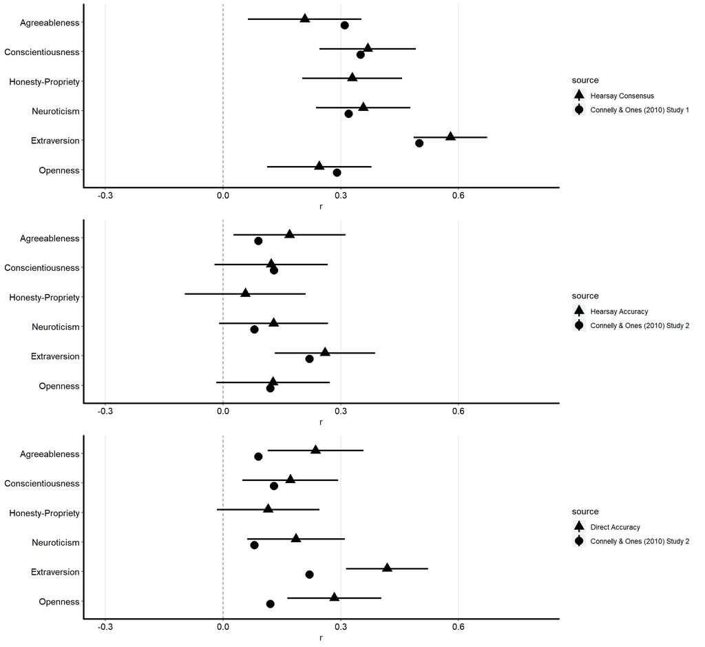

```r
plot_names <- plot_names[str_detect(plot_names, "^plot")]
cowplot::plot_grid(get(plot_names[1]), get(plot_names[2]),
                   get(plot_names[3]), nrow = 3)
```

## Distinctive Hearsay Accuracy

### Agreeableness

The model and results for distinctive hearsay accuracy of Agreeableness.

#### Full Model

```r
# specify the model
agreeableness_distinctive_hearsay_accuracy <-'
# distinctive hearsay accuracy and distinctive direct accuracy paths
C_C_agreeableness ~ DHA*B_C_agreeableness + DDA*A_C_agreeableness
A_A_agreeableness ~ DHA*D_A_agreeableness + DDA*C_A_agreeableness

# hearsay consensus
B_C_agreeableness ~~ HC*A_C_agreeableness
D_A_agreeableness ~~ HC*C_A_agreeableness

# variances (pooled)
C_C_agreeableness ~~ v_self*C_C_agreeableness
A_A_agreeableness ~~ v_self*A_A_agreeableness
A_C_agreeableness ~~ v_P1*A_C_agreeableness
C_A_agreeableness ~~ v_P1*C_A_agreeableness
B_C_agreeableness ~~ v_P2*B_C_agreeableness
D_A_agreeableness ~~ v_P2*D_A_agreeableness

# intercepts (pooled)
C_C_agreeableness ~ int_self*1
A_A_agreeableness ~ int_self*1
B_C_agreeableness ~ int_P1*1
D_A_agreeableness ~ int_P1*1
A_C_agreeableness ~ int_P2*1
C_A_agreeableness ~ int_P2*1
'
# fit the model
fit_agreeableness_distinctive_hearsay_accuracy <-
  sem(agreeableness_distinctive_hearsay_accuracy,
      data = study1,
      # missing = FIML critical due to planned missingness
      missing="FIML")

# display results
summary(fit_agreeableness_distinctive_hearsay_accuracy,
        # include standardized estimates
        standardized=TRUE)
```

```
## lavaan 0.6-4 ended normally after 33 iterations
##
##   Optimization method                           NLMINB
##   Number of free parameters                         19
##   Number of equality constraints                     9
##   Row rank of the constraints matrix                 9
##
##                                                   Used       Total
##   Number of observations                           122         124
##   Number of missing patterns                         7
##
##   Estimator                                         ML
##   Model Fit Test Statistic                      45.160
##   Degrees of freedom                                17
##   P-value (Chi-square)                           0.000
##
## Parameter Estimates:
##
##   Information                                 Observed
##   Observed information based on                Hessian
##   Standard Errors                             Standard
##
## Regressions:
##                       Estimate  Std.Err  z-value  P(>|z|)   Std.lv
##   C_C_agreeableness ~
##     B_C_grbl (DHA)       0.137    0.080    1.710    0.087    0.137
##     A_C_grbl (DDA)       0.243    0.077    3.165    0.002    0.243
##   A_A_agreeableness ~
##     D_A_grbl (DHA)       0.137    0.080    1.710    0.087    0.137
##     C_A_grbl (DDA)       0.243    0.077    3.165    0.002    0.243
##   Std.all
##
##     0.129
##     0.222
##
##     0.129
##     0.222
##
## Covariances:
##                        Estimate  Std.Err  z-value  P(>|z|)   Std.lv
```

[output cut: 16 more lines]

```
##    .C_C_grb (int_)    2.402    0.366    6.567    0.000    2.402    4.321
##    .A_A_grb (int_)    2.402    0.366    6.567    0.000    2.402    4.321
##     B_C_grb (i_P1)    3.700    0.038   97.626    0.000    3.700    7.036
##     D_A_grb (i_P1)    3.700    0.038   97.626    0.000    3.700    7.036
##     A_C_grb (i_P2)    3.964    0.033  121.224    0.000    3.964    7.790
##     C_A_grb (i_P2)    3.964    0.033  121.224    0.000    3.964    7.790
##
## Variances:
##                    Estimate  Std.Err  z-value  P(>|z|)   Std.lv  Std.all
##    .C_C_grb (v_sl)    0.285    0.026   10.856    0.000    0.285    0.922
##    .A_A_grb (v_sl)    0.285    0.026   10.856    0.000    0.285    0.922
##     A_C_grb (v_P1)    0.259    0.024   11.008    0.000    0.259    1.000
##     C_A_grb (v_P1)    0.259    0.024   11.008    0.000    0.259    1.000
##     B_C_grb (v_P2)    0.276    0.028    9.737    0.000    0.276    1.000
##     D_A_grb (v_P2)    0.276    0.028    9.737    0.000    0.276    1.000
```

#### Table of Results

Now get a table of the three main results we want:

- Distinctive Hearsay Accuracy
- Distinctive Direct Accuracy
- Hearsay Consensus

```r
agree_ha_table <- fit_agreeableness_distinctive_hearsay_accuracy@ParTable %>%
  as.data.frame() %>%
  select(label, lhs, op, rhs) %>%
  left_join(standardizedsolution(fit_agreeableness_distinctive_hearsay_accuracy)) %>%
  filter(label == "DHA" |
         label == "DDA" |
         label == "HC") %>%
  filter(duplicated(.[["label"]])) %>%
  mutate(
    label = str_replace_all(label, "DHA", "Distinctive Hearsay Accuracy"),
    label = str_replace_all(label, "DDA", "Distinctive Direct Accuracy"),
    label = str_replace_all(label, "HC", "Hearsay Consensus")) %>%
  select(label, est.std, ci.lower, ci.upper, pvalue)
```

### Conscientiousness

The model and results for distinctive hearsay accuracy of Conscientiousness.

#### Full Model

```r
# specify the model
conscientiousness_distinctive_hearsay_accuracy <-'
# distinctive hearsay accuracy and distinctive direct accuracy paths
C_C_conscientiousness ~ DHA*B_C_conscientiousness + DDA*A_C_conscientiousness
A_A_conscientiousness ~ DHA*D_A_conscientiousness + DDA*C_A_conscientiousness

# hearsay consensus
B_C_conscientiousness ~~ HC*A_C_conscientiousness
D_A_conscientiousness ~~ HC*C_A_conscientiousness

# variances (pooled)
C_C_conscientiousness ~~ v_self*C_C_conscientiousness
A_A_conscientiousness ~~ v_self*A_A_conscientiousness
A_C_conscientiousness ~~ v_P1*A_C_conscientiousness
C_A_conscientiousness ~~ v_P1*C_A_conscientiousness
B_C_conscientiousness ~~ v_P2*B_C_conscientiousness
D_A_conscientiousness ~~ v_P2*D_A_conscientiousness

# intercepts (pooled)
C_C_conscientiousness ~ int_self*1
A_A_conscientiousness ~ int_self*1
B_C_conscientiousness ~ int_P1*1
D_A_conscientiousness ~ int_P1*1
A_C_conscientiousness ~ int_P2*1
C_A_conscientiousness ~ int_P2*1
'
# fit the model
fit_conscientiousness_distinctive_hearsay_accuracy <-
  sem(conscientiousness_distinctive_hearsay_accuracy,
      data=study1,
      # missing = FIML critical due to planned missingness
      missing="FIML")

# display results
summary(fit_conscientiousness_distinctive_hearsay_accuracy,
        # include standardized estimates
        standardized=TRUE)
```

```
## lavaan 0.6-4 ended normally after 26 iterations
##
##   Optimization method                           NLMINB
##   Number of free parameters                         19
##   Number of equality constraints                     9
##   Row rank of the constraints matrix                 9
##
##                                                   Used       Total
##   Number of observations                           122         124
##   Number of missing patterns                         7
##
##   Estimator                                         ML
##   Model Fit Test Statistic                      38.258
##   Degrees of freedom                                17
##   P-value (Chi-square)                           0.002
##
## Parameter Estimates:
##
##   Information                                 Observed
##   Observed information based on                Hessian
##   Standard Errors                             Standard
##
## Regressions:
##                           Estimate  Std.Err  z-value  P(>|z|)   Std.lv
##   C_C_conscientiousness ~
##     B_C_cnsc (DHA)           0.063    0.081    0.780    0.435    0.063
##     A_C_cnsc (DDA)           0.209    0.085    2.459    0.014    0.209
##   A_A_conscientiousness ~
##     D_A_cnsc (DHA)           0.063    0.081    0.780    0.435    0.063
##     C_A_cnsc (DDA)           0.209    0.085    2.459    0.014    0.209
##   Std.all
##
##     0.061
##     0.177
##
##     0.061
##     0.177
##
## Covariances:
##                            Estimate  Std.Err  z-value  P(>|z|)   Std.lv
```

[output cut: 16 more lines]

```
##    .C_C_cns (int_)    2.527    0.339    7.448    0.000    2.527    3.921
##    .A_A_cns (int_)    2.527    0.339    7.448    0.000    2.527    3.921
##     B_C_cns (i_P1)    3.564    0.044   80.414    0.000    3.564    5.739
##     D_A_cns (i_P1)    3.564    0.044   80.414    0.000    3.564    5.739
##     A_C_cns (i_P2)    3.699    0.035  105.583    0.000    3.699    6.783
##     C_A_cns (i_P2)    3.699    0.035  105.583    0.000    3.699    6.783
##
## Variances:
##                    Estimate  Std.Err  z-value  P(>|z|)   Std.lv  Std.all
##    .C_C_cns (v_sl)    0.397    0.037   10.754    0.000    0.397    0.957
##    .A_A_cns (v_sl)    0.397    0.037   10.754    0.000    0.397    0.957
##     A_C_cns (v_P1)    0.297    0.027   11.005    0.000    0.297    1.000
##     C_A_cns (v_P1)    0.297    0.027   11.005    0.000    0.297    1.000
##     B_C_cns (v_P2)    0.386    0.040    9.749    0.000    0.386    1.000
##     D_A_cns (v_P2)    0.386    0.040    9.749    0.000    0.386    1.000
```

#### Table of Results

Now get a table of the three main results we want:

- Distinctive Hearsay Accuracy
- Distinctive Direct Accuracy
- Hearsay Consensus

```r
consc_ha_table <- fit_conscientiousness_distinctive_hearsay_accuracy@ParTable %>%
  as.data.frame() %>%
  select(label, lhs, op, rhs) %>%
  left_join(standardizedsolution(fit_conscientiousness_distinctive_hearsay_accuracy)) %>%
  filter(label == "DHA" |
         label == "DDA" |
         label == "HC") %>%
  filter(duplicated(.[["label"]])) %>%
  mutate(
    label = str_replace_all(label, "DHA", "Distinctive Hearsay Accuracy"),
    label = str_replace_all(label, "DDA", "Distinctive Direct Accuracy"),
    label = str_replace_all(label, "HC", "Hearsay Consensus")) %>%
  select(label, est.std, ci.lower, ci.upper, pvalue)
```

### HP

The model and results for distinctive hearsay accuracy of HP.

#### Full Model

```r
# specify the model
hp_distinctive_hearsay_accuracy <-'
# distinctive hearsay accuracy and distinctive direct accuracy paths
C_C_hp ~ DHA*B_C_hp + DDA*A_C_hp
A_A_hp ~ DHA*D_A_hp + DDA*C_A_hp

# hearsay consensus
B_C_hp ~~ HC*A_C_hp
D_A_hp ~~ HC*C_A_hp

# variances (pooled)
C_C_hp ~~ v_self*C_C_hp
A_A_hp ~~ v_self*A_A_hp
A_C_hp ~~ v_P1*A_C_hp
C_A_hp ~~ v_P1*C_A_hp
B_C_hp ~~ v_P2*B_C_hp
D_A_hp ~~ v_P2*D_A_hp

# intercepts (pooled)
C_C_hp ~ int_self*1
A_A_hp ~ int_self*1
B_C_hp ~ int_P1*1
D_A_hp ~ int_P1*1
A_C_hp ~ int_P2*1
C_A_hp ~ int_P2*1
'
# fit the model
fit_hp_distinctive_hearsay_accuracy <-
  sem(hp_distinctive_hearsay_accuracy,
      data=study1,
      # missing = FIML critical due to planned missingness
      missing="FIML")

# display results
summary(fit_hp_distinctive_hearsay_accuracy,
        # include standardized estimates
        standardized=TRUE)
```

```
## lavaan 0.6-4 ended normally after 29 iterations
##
##   Optimization method                           NLMINB
##   Number of free parameters                         19
##   Number of equality constraints                     9
##   Row rank of the constraints matrix                 9
##
##                                                   Used       Total
##   Number of observations                           122         124
##   Number of missing patterns                         7
##
##   Estimator                                         ML
##   Model Fit Test Statistic                      24.288
##   Degrees of freedom                                17
##   P-value (Chi-square)                           0.112
##
## Parameter Estimates:
##
##   Information                                 Observed
##   Observed information based on                Hessian
##   Standard Errors                             Standard
##
## Regressions:
##                    Estimate  Std.Err  z-value  P(>|z|)   Std.lv  Std.all
##   C_C_hp ~
##     B_C_hp   (DHA)    0.047    0.084    0.555    0.579    0.047    0.045
##     A_C_hp   (DDA)    0.113    0.084    1.348    0.178    0.113    0.099
##   A_A_hp ~
##     D_A_hp   (DHA)    0.047    0.084    0.555    0.579    0.047    0.045
##     C_A_hp   (DDA)    0.113    0.084    1.348    0.178    0.113    0.099
##
## Covariances:
##                    Estimate  Std.Err  z-value  P(>|z|)   Std.lv  Std.all
##   B_C_hp ~~
##     A_C_hp    (HC)    0.098    0.021    4.731    0.000    0.098    0.353
##   D_A_hp ~~
##     C_A_hp    (HC)    0.098    0.021    4.731    0.000    0.098    0.353
##  .C_C_hp ~~
##    .A_A_hp           -0.042    0.030   -1.404    0.160   -0.042   -0.132
##
## Intercepts:
##                    Estimate  Std.Err  z-value  P(>|z|)   Std.lv  Std.all
##    .C_C_hp  (int_)    3.141    0.336    9.353    0.000    3.141    5.518
##    .A_A_hp  (int_)    3.141    0.336    9.353    0.000    3.141    5.518
##     B_C_hp  (i_P1)    3.427    0.039   86.893    0.000    3.427    6.220
##     D_A_hp  (i_P1)    3.427    0.039   86.893    0.000    3.427    6.220
##     A_C_hp  (i_P2)    3.790    0.032  117.482    0.000    3.790    7.548
##     C_A_hp  (i_P2)    3.790    0.032  117.482    0.000    3.790    7.548
##
## Variances:
##                    Estimate  Std.Err  z-value  P(>|z|)   Std.lv  Std.all
##    .C_C_hp  (v_sl)    0.319    0.029   10.848    0.000    0.319    0.985
##    .A_A_hp  (v_sl)    0.319    0.029   10.848    0.000    0.319    0.985
##     A_C_hp  (v_P1)    0.252    0.023   11.010    0.000    0.252    1.000
##     C_A_hp  (v_P1)    0.252    0.023   11.010    0.000    0.252    1.000
##     B_C_hp  (v_P2)    0.304    0.031    9.768    0.000    0.304    1.000
##     D_A_hp  (v_P2)    0.304    0.031    9.768    0.000    0.304    1.000
```

#### Table of Results

Now get a table of the three main results we want:

- Distinctive Hearsay Accuracy
- Distinctive Direct Accuracy
- Hearsay Consensus

```r
hp_ha_table <- fit_hp_distinctive_hearsay_accuracy@ParTable %>%
  as.data.frame() %>%
  select(label, lhs, op, rhs) %>%
  left_join(standardizedsolution(fit_hp_distinctive_hearsay_accuracy)) %>%
  filter(label == "DHA" |
         label == "DDA" |
         label == "HC") %>%
  filter(duplicated(.[["label"]])) %>%
  mutate(
    label = str_replace_all(label, "DHA", "Distinctive Hearsay Accuracy"),
    label = str_replace_all(label, "DDA", "Distinctive Direct Accuracy"),
    label = str_replace_all(label, "HC", "Hearsay Consensus")) %>%
  select(label, est.std, ci.lower, ci.upper, pvalue)
```

### Neuroticism

The model and results for distinctive hearsay accuracy of Neuroticism.

#### Full Model

```r
# specify the model
neuroticism_distinctive_hearsay_accuracy <-'
# distinctive hearsay accuracy and distinctive direct accuracy paths
C_C_neuroticism ~ DHA*B_C_neuroticism + DDA*A_C_neuroticism
A_A_neuroticism ~ DHA*D_A_neuroticism + DDA*C_A_neuroticism

# hearsay consensus
B_C_neuroticism ~~ HC*A_C_neuroticism
D_A_neuroticism ~~ HC*C_A_neuroticism

# variances (pooled)
C_C_neuroticism ~~ v_self*C_C_neuroticism
A_A_neuroticism ~~ v_self*A_A_neuroticism
A_C_neuroticism ~~ v_P1*A_C_neuroticism
C_A_neuroticism ~~ v_P1*C_A_neuroticism
B_C_neuroticism ~~ v_P2*B_C_neuroticism
D_A_neuroticism ~~ v_P2*D_A_neuroticism

# intercepts (pooled)
C_C_neuroticism ~ int_self*1
A_A_neuroticism ~ int_self*1
B_C_neuroticism ~ int_P1*1
D_A_neuroticism ~ int_P1*1
A_C_neuroticism ~ int_P2*1
C_A_neuroticism ~ int_P2*1
'
# fit the model
fit_neuroticism_distinctive_hearsay_accuracy <-
  sem(neuroticism_distinctive_hearsay_accuracy,
      data=study1,
      # missing = FIML critical due to planned missingness
      missing="FIML")

# display results
summary(fit_neuroticism_distinctive_hearsay_accuracy,
        # include standardized estimates
        standardized=TRUE)
```

```
## lavaan 0.6-4 ended normally after 22 iterations
##
##   Optimization method                           NLMINB
##   Number of free parameters                         19
##   Number of equality constraints                     9
##   Row rank of the constraints matrix                 9
##
##                                                   Used       Total
##   Number of observations                           122         124
##   Number of missing patterns                         7
##
##   Estimator                                         ML
##   Model Fit Test Statistic                      39.801
##   Degrees of freedom                                17
##   P-value (Chi-square)                           0.001
##
## Parameter Estimates:
##
##   Information                                 Observed
##   Observed information based on                Hessian
##   Standard Errors                             Standard
##
## Regressions:
##                     Estimate  Std.Err  z-value  P(>|z|)   Std.lv  Std.all
##   C_C_neuroticism ~
##     B_C_nrtc (DHA)     0.111    0.105    1.055    0.292    0.111    0.080
##     A_C_nrtc (DDA)     0.255    0.122    2.088    0.037    0.255    0.149
##   A_A_neuroticism ~
##     D_A_nrtc (DHA)     0.111    0.105    1.055    0.292    0.111    0.080
##     C_A_nrtc (DDA)     0.255    0.122    2.088    0.037    0.255    0.149
##
## Covariances:
##                      Estimate  Std.Err  z-value  P(>|z|)   Std.lv  Std.all
##   B_C_neuroticism ~~
##     A_C_nrtcs (HC)      0.102    0.022    4.606    0.000    0.102    0.341
##   D_A_neuroticism ~~
##     C_A_nrtcs (HC)      0.102    0.022    4.606    0.000    0.102    0.341
##  .C_C_neuroticism ~~
##    .A_A_nrtcs           0.041    0.066    0.628    0.530    0.041    0.060
##
## Intercepts:
##                    Estimate  Std.Err  z-value  P(>|z|)   Std.lv  Std.all
##    .C_C_nrt (int_)    1.934    0.343    5.637    0.000    1.934    2.288
##    .A_A_nrt (int_)    1.934    0.343    5.637    0.000    1.934    2.288
##     B_C_nrt (i_P1)    2.737    0.043   63.011    0.000    2.737    4.519
##     D_A_nrt (i_P1)    2.737    0.043   63.011    0.000    2.737    4.519
##     A_C_nrt (i_P2)    2.534    0.032   80.162    0.000    2.534    5.150
##     C_A_nrt (i_P2)    2.534    0.032   80.162    0.000    2.534    5.150
##
## Variances:
##                    Estimate  Std.Err  z-value  P(>|z|)   Std.lv  Std.all
##    .C_C_nrt (v_sl)    0.688    0.063   10.917    0.000    0.688    0.964
##    .A_A_nrt (v_sl)    0.688    0.063   10.917    0.000    0.688    0.964
##     A_C_nrt (v_P1)    0.242    0.022   11.011    0.000    0.242    1.000
##     C_A_nrt (v_P1)    0.242    0.022   11.011    0.000    0.242    1.000
##     B_C_nrt (v_P2)    0.367    0.037    9.789    0.000    0.367    1.000
##     D_A_nrt (v_P2)    0.367    0.037    9.789    0.000    0.367    1.000
```

#### Table of Results

Now get a table of the three main results we want:

- Distinctive Hearsay Accuracy
- Distinctive Direct Accuracy
- Hearsay Consensus

```r
neur_ha_table <- fit_neuroticism_distinctive_hearsay_accuracy@ParTable %>%
  as.data.frame() %>%
  select(label, lhs, op, rhs) %>%
  left_join(standardizedsolution(fit_neuroticism_distinctive_hearsay_accuracy)) %>%
  filter(label == "DHA" |
         label == "DDA" |
         label == "HC") %>%
  filter(duplicated(.[["label"]])) %>%
  mutate(
    label = str_replace_all(label, "DHA", "Distinctive Hearsay Accuracy"),
    label = str_replace_all(label, "DDA", "Distinctive Direct Accuracy"),
    label = str_replace_all(label, "HC", "Hearsay Consensus")) %>%
  select(label, est.std, ci.lower, ci.upper, pvalue)
```

### Extraversion

The model and results for distinctive hearsay accuracy of Extraversion.

#### Full Model

```r
# specify the model
extraversion_distinctive_hearsay_accuracy <-'
# distinctive hearsay accuracy and distinctive direct accuracy paths
C_C_extraversion ~ DHA*B_C_extraversion + DDA*A_C_extraversion
A_A_extraversion ~ DHA*D_A_extraversion + DDA*C_A_extraversion

# hearsay consensus
B_C_extraversion ~~ HC*A_C_extraversion
D_A_extraversion ~~ HC*C_A_extraversion

# variances (pooled)
C_C_extraversion ~~ v_self*C_C_extraversion
A_A_extraversion ~~ v_self*A_A_extraversion
A_C_extraversion ~~ v_P1*A_C_extraversion
C_A_extraversion ~~ v_P1*C_A_extraversion
B_C_extraversion ~~ v_P2*B_C_extraversion
D_A_extraversion ~~ v_P2*D_A_extraversion

# intercepts (pooled)
C_C_extraversion ~ int_self*1
A_A_extraversion ~ int_self*1
B_C_extraversion ~ int_P1*1
D_A_extraversion ~ int_P1*1
A_C_extraversion ~ int_P2*1
C_A_extraversion ~ int_P2*1
'
# fit the model
fit_extraversion_distinctive_hearsay_accuracy <-
  sem(extraversion_distinctive_hearsay_accuracy,
      data=study1,
      # missing = FIML critical due to planned missingness
      missing="FIML")

# display results
summary(fit_extraversion_distinctive_hearsay_accuracy,
        # include standardized estimates
        standardized=TRUE)
```

```
## lavaan 0.6-4 ended normally after 24 iterations
##
##   Optimization method                           NLMINB
##   Number of free parameters                         19
##   Number of equality constraints                     9
##   Row rank of the constraints matrix                 9
##
##                                                   Used       Total
##   Number of observations                           122         124
##   Number of missing patterns                         7
##
##   Estimator                                         ML
##   Model Fit Test Statistic                      32.032
##   Degrees of freedom                                17
##   P-value (Chi-square)                           0.015
##
## Parameter Estimates:
##
##   Information                                 Observed
##   Observed information based on                Hessian
##   Standard Errors                             Standard
##
## Regressions:
##                      Estimate  Std.Err  z-value  P(>|z|)   Std.lv  Std.all
##   C_C_extraversion ~
##     B_C_xtrv (DHA)      0.032    0.082    0.390    0.697    0.032    0.032
##     A_C_xtrv (DDA)      0.403    0.080    5.009    0.000    0.403    0.389
##   A_A_extraversion ~
##     D_A_xtrv (DHA)      0.032    0.082    0.390    0.697    0.032    0.032
##     C_A_xtrv (DDA)      0.403    0.080    5.009    0.000    0.403    0.389
##
## Covariances:
##                       Estimate  Std.Err  z-value  P(>|z|)   Std.lv
##   B_C_extraversion ~~
##     A_C_xtrvr (HC)       0.304    0.042    7.311    0.000    0.304
##   D_A_extraversion ~~
##     C_A_xtrvr (HC)       0.304    0.042    7.311    0.000    0.304
##  .C_C_extraversion ~~
##    .A_A_xtrvr           -0.065    0.043   -1.529    0.126   -0.065
##   Std.all
```

[output cut: 9 more lines]

```
##    .C_C_xtr (int_)    2.009    0.227    8.858    0.000    2.009    2.732
##    .A_A_xtr (int_)    2.009    0.227    8.858    0.000    2.009    2.732
##     B_C_xtr (i_P1)    3.260    0.052   63.216    0.000    3.260    4.418
##     D_A_xtr (i_P1)    3.260    0.052   63.216    0.000    3.260    4.418
##     A_C_xtr (i_P2)    3.213    0.046   70.542    0.000    3.213    4.527
##     C_A_xtr (i_P2)    3.213    0.046   70.542    0.000    3.213    4.527
##
## Variances:
##                    Estimate  Std.Err  z-value  P(>|z|)   Std.lv  Std.all
##    .C_C_xtr (v_sl)    0.451    0.042   10.808    0.000    0.451    0.833
##    .A_A_xtr (v_sl)    0.451    0.042   10.808    0.000    0.451    0.833
##     A_C_xtr (v_P1)    0.504    0.046   10.984    0.000    0.504    1.000
##     C_A_xtr (v_P1)    0.504    0.046   10.984    0.000    0.504    1.000
##     B_C_xtr (v_P2)    0.544    0.055    9.847    0.000    0.544    1.000
##     D_A_xtr (v_P2)    0.544    0.055    9.847    0.000    0.544    1.000
```

#### Table of Results

Now get a table of the three main results we want:

- Distinctive Hearsay Accuracy
- Distinctive Direct Accuracy
- Hearsay Consensus

```r
extra_ha_table <- fit_extraversion_distinctive_hearsay_accuracy@ParTable %>%
  as.data.frame() %>%
  select(label, lhs, op, rhs) %>%
  left_join(standardizedsolution(fit_extraversion_distinctive_hearsay_accuracy)) %>%
  filter(label == "DHA" |
         label == "DDA" |
         label == "HC") %>%
  filter(duplicated(.[["label"]])) %>%
  mutate(
    label = str_replace_all(label, "DHA", "Distinctive Hearsay Accuracy"),
    label = str_replace_all(label, "DDA", "Distinctive Direct Accuracy"),
    label = str_replace_all(label, "HC", "Hearsay Consensus")) %>%
  select(label, est.std, ci.lower, ci.upper, pvalue)
```

### Openness

The model and results for distinctive hearsay accuracy of Openness.

#### Full Model

```r
# specify the model
openness_distinctive_hearsay_accuracy <-'
# distinctive hearsay accuracy and distinctive direct accuracy paths
C_C_openness ~ DHA*B_C_openness + DDA*A_C_openness
A_A_openness ~ DHA*D_A_openness + DDA*C_A_openness

# hearsay consensus
B_C_openness ~~ HC*A_C_openness
D_A_openness ~~ HC*C_A_openness

# variances (pooled)
C_C_openness ~~ v_self*C_C_openness
A_A_openness ~~ v_self*A_A_openness
A_C_openness ~~ v_P1*A_C_openness
C_A_openness ~~ v_P1*C_A_openness
B_C_openness ~~ v_P2*B_C_openness
D_A_openness ~~ v_P2*D_A_openness

# intercepts (pooled)
C_C_openness ~ int_self*1
A_A_openness ~ int_self*1
B_C_openness ~ int_P1*1
D_A_openness ~ int_P1*1
A_C_openness ~ int_P2*1
C_A_openness ~ int_P2*1
'
# fit the model
fit_openness_distinctive_hearsay_accuracy <-
  sem(openness_distinctive_hearsay_accuracy,
      data=study1,
      # missing = FIML critical due to planned missingness
      missing="FIML")

# display results
summary(fit_openness_distinctive_hearsay_accuracy,
        # include standardized estimates
        standardized=TRUE)
```

```
## lavaan 0.6-4 ended normally after 29 iterations
##
##   Optimization method                           NLMINB
##   Number of free parameters                         19
##   Number of equality constraints                     9
##   Row rank of the constraints matrix                 9
##
##                                                   Used       Total
##   Number of observations                           122         124
##   Number of missing patterns                         7
##
##   Estimator                                         ML
##   Model Fit Test Statistic                      51.953
##   Degrees of freedom                                17
##   P-value (Chi-square)                           0.000
##
## Parameter Estimates:
##
##   Information                                 Observed
##   Observed information based on                Hessian
##   Standard Errors                             Standard
##
## Regressions:
##                    Estimate  Std.Err  z-value  P(>|z|)   Std.lv  Std.all
##   C_C_openness ~
##     B_C_pnns (DHA)    0.070    0.091    0.761    0.446    0.070    0.056
##     A_C_pnns (DDA)    0.373    0.086    4.363    0.000    0.373    0.293
##   A_A_openness ~
##     D_A_pnns (DHA)    0.070    0.091    0.761    0.446    0.070    0.056
##     C_A_pnns (DDA)    0.373    0.086    4.363    0.000    0.373    0.293
##
## Covariances:
##                    Estimate  Std.Err  z-value  P(>|z|)   Std.lv  Std.all
##   B_C_openness ~~
##     A_C_pnnss (HC)    0.055    0.016    3.357    0.001    0.055    0.244
##   D_A_openness ~~
##     C_A_pnnss (HC)    0.055    0.016    3.357    0.001    0.055    0.244
##  .C_C_openness ~~
##    .A_A_pnnss        -0.069    0.033   -2.113    0.035   -0.069   -0.216
##
## Intercepts:
##                    Estimate  Std.Err  z-value  P(>|z|)   Std.lv  Std.all
##    .C_C_pnn (int_)    2.281    0.356    6.414    0.000    2.281    3.831
##    .A_A_pnn (int_)    2.281    0.356    6.414    0.000    2.281    3.831
##     B_C_pnn (i_P1)    3.320    0.035   95.590    0.000    3.320    6.908
##     D_A_pnn (i_P1)    3.320    0.035   95.590    0.000    3.320    6.908
##     A_C_pnn (i_P2)    3.459    0.030  115.416    0.000    3.459    7.415
##     C_A_pnn (i_P2)    3.459    0.030  115.416    0.000    3.459    7.415
##
## Variances:
##                    Estimate  Std.Err  z-value  P(>|z|)   Std.lv  Std.all
##    .C_C_pnn (v_sl)    0.320    0.030   10.641    0.000    0.320    0.903
##    .A_A_pnn (v_sl)    0.320    0.030   10.641    0.000    0.320    0.903
##     A_C_pnn (v_P1)    0.218    0.020   10.990    0.000    0.218    1.000
##     C_A_pnn (v_P1)    0.218    0.020   10.990    0.000    0.218    1.000
##     B_C_pnn (v_P2)    0.231    0.024    9.773    0.000    0.231    1.000
##     D_A_pnn (v_P2)    0.231    0.024    9.773    0.000    0.231    1.000
```

#### Table of Results

Now get a table of the three main results we want:

- Distinctive Hearsay Accuracy
- Distinctive Direct Accuracy
- Hearsay Consensus

```r
open_ha_table <- fit_openness_distinctive_hearsay_accuracy@ParTable %>%
  as.data.frame() %>%
  select(label, lhs, op, rhs) %>%
  left_join(standardizedsolution(fit_openness_distinctive_hearsay_accuracy)) %>%
  filter(label == "DHA" |
         label == "DDA" |
         label == "HC") %>%
  filter(duplicated(.[["label"]])) %>%
  mutate(
    label = str_replace_all(label, "DHA", "Distinctive Hearsay Accuracy"),
    label = str_replace_all(label, "DDA", "Distinctive Direct Accuracy"),
    label = str_replace_all(label, "HC", "Hearsay Consensus")) %>%
  select(label, est.std, ci.lower, ci.upper, pvalue)
```

### Table of All Big Six together

And finally a table of all of the results together. This is akin to Table 2 in the manuscript, but is organized a bit differently.

```r
agree_ha_table$domain = "Agreeableness"
consc_ha_table$domain = "Conscientiousness"
hp_ha_table$domain = "Honesty-Propriety"
neur_ha_table$domain = "Neuroticism"
extra_ha_table$domain = "Extraversion"
open_ha_table$domain = "Openness"

agree_ha_table %>%
  full_join(consc_ha_table) %>%
  full_join(hp_ha_table) %>%
  full_join(neur_ha_table) %>%
  full_join(extra_ha_table) %>%
  full_join(open_ha_table) %>%
  mutate(parameter = fct_relevel(label,
                                 "Distinctive Hearsay Accuracy",
                                 "Distinctive Direct Accuracy",
                                 "Hearsay Consensus"),
         pvalue = ifelse(pvalue >= .001,
                         str_pad(str_replace(round(pvalue, 3), "0.", "."),
                                 4, side = "right", pad ="0"), "< .001")) %>%
  arrange(parameter) %>%
  select(domain, parameter, est.std, ci.lower, ci.upper, pvalue) %>%
  knitr::kable(digits = c(NA, NA, 2, 2, 2, NA),
               caption = "Distinctive Hearsay Accuracy: All Big Six",
               format = "html", escape = F) %>%
  kable_styling("striped", full_width = F)
```

Distinctive Hearsay Accuracy: All Big Six

| domain | parameter | est.std | ci.lower | ci.upper | pvalue |
| --- | --- | --- | --- | --- | --- |
| Agreeableness | Distinctive Hearsay Accuracy | 0.13 | -0.02 | 0.28 | .086 |
| Conscientiousness | Distinctive Hearsay Accuracy | 0.06 | -0.09 | 0.21 | .435 |
| Honesty-Propriety | Distinctive Hearsay Accuracy | 0.05 | -0.11 | 0.20 | .579 |
| Neuroticism | Distinctive Hearsay Accuracy | 0.08 | -0.07 | 0.23 | .290 |
| Extraversion | Distinctive Hearsay Accuracy | 0.03 | -0.13 | 0.19 | .697 |
| Openness | Distinctive Hearsay Accuracy | 0.06 | -0.09 | 0.20 | .447 |
| Agreeableness | Distinctive Direct Accuracy | 0.22 | 0.09 | 0.36 | .001 |
| Conscientiousness | Distinctive Direct Accuracy | 0.18 | 0.04 | 0.32 | .012 |
| Honesty-Propriety | Distinctive Direct Accuracy | 0.10 | -0.04 | 0.24 | .175 |
| Neuroticism | Distinctive Direct Accuracy | 0.15 | 0.01 | 0.29 | .035 |
| Extraversion | Distinctive Direct Accuracy | 0.39 | 0.24 | 0.53 | < .001 |
| Openness | Distinctive Direct Accuracy | 0.29 | 0.17 | 0.42 | < .001 |
| Agreeableness | Hearsay Consensus | 0.21 | 0.07 | 0.36 | .003 |
| Conscientiousness | Hearsay Consensus | 0.38 | 0.26 | 0.50 | < .001 |
| Honesty-Propriety | Hearsay Consensus | 0.35 | 0.23 | 0.48 | < .001 |
| Neuroticism | Hearsay Consensus | 0.34 | 0.22 | 0.46 | < .001 |
| Extraversion | Hearsay Consensus | 0.58 | 0.49 | 0.67 | < .001 |
| Openness | Hearsay Consensus | 0.24 | 0.11 | 0.38 | < .001 |

## Extraversion Moderating Hearsay Consensus

I’ll start with Extraversion moderating hearsay consensus, which predicts P1 reports from P2 reports, (Target, P1, and P2 ) self-reported Extraversion, and their interaction.

### Target Extraversion

Starting with targets’ self-reported Extraversion moderating hearsay consensus for each of the Big Six.

#### Agreeableness

```r
agreeableness_Textmod_hc <- rep_consensus_id_mods(study1,
                      p1_reports = c("A_C_agreeableness",
                                     "C_A_agreeableness"),
                      p2_reports = c("B_C_agreeableness_cent",
                                     "D_A_agreeableness_cent"),
                      id_mod_variable = c("C_C_extraversion_cent",
                                          "A_A_extraversion_cent"),
                      interaction_term = c("extraXagree_CB",
                                           "extraXagree_AD"))
summary(agreeableness_Textmod_hc, standardized = TRUE)
```

```
## lavaan 0.6-4 ended normally after 24 iterations
##
##   Optimization method                           NLMINB
##   Number of free parameters                         23
##   Number of equality constraints                    11
##   Row rank of the constraints matrix                11
##
##                                                   Used       Total
##   Number of observations                           122         124
##   Number of missing patterns                         7
##
##   Estimator                                         ML
##   Model Fit Test Statistic                      61.089
##   Degrees of freedom                                32
##   P-value (Chi-square)                           0.001
##
## Parameter Estimates:
##
##   Information                                 Observed
##   Observed information based on                Hessian
##   Standard Errors                             Standard
##
## Regressions:
##                       Estimate  Std.Err  z-value  P(>|z|)   Std.lv
##   A_C_agreeableness ~
##     B_C_gr_ (hc_m)       0.171    0.072    2.367    0.018    0.171
##     C_C_xt_ (md_m)      -0.075    0.045   -1.674    0.094   -0.075
##     extX_CB (intr)       0.262    0.104    2.512    0.012    0.262
##   C_A_agreeableness ~
##     D_A_gr_ (hc_m)       0.171    0.072    2.367    0.018    0.171
##     A_A_xt_ (md_m)      -0.075    0.045   -1.674    0.094   -0.075
##     extX_AD (intr)       0.262    0.104    2.512    0.012    0.262
##   Std.all
##
##     0.178
##    -0.108
##     0.189
##
##     0.178
##    -0.108
```

[output cut: 16 more lines]

```
##    .C_A_gr  (in_1)    3.971    0.033  119.671    0.000    3.971    7.844
##     D_A_g_  (in_2)    0.001    0.038    0.018    0.986    0.001    0.001
##     A_A_x_ (int_m)    0.000    0.047    0.009    0.993    0.000    0.001
##     exX_AD (int_n)   -0.029    0.027   -1.078    0.281   -0.029   -0.079
##
## Variances:
##                    Estimate  Std.Err  z-value  P(>|z|)   Std.lv  Std.all
##    .A_C_grb (v_p1)    0.236    0.022   10.635    0.000    0.236    0.921
##     B_C_gr_ (v_p2)    0.277    0.029    9.710    0.000    0.277    1.000
##     C_C_xt_ (v_md)    0.537    0.049   10.955    0.000    0.537    1.000
##     extX_CB (v_nt)    0.133    0.014    9.602    0.000    0.133    1.000
##    .C_A_grb (v_p1)    0.236    0.022   10.635    0.000    0.236    0.921
##     D_A_gr_ (v_p2)    0.277    0.029    9.710    0.000    0.277    1.000
##     A_A_xt_ (v_md)    0.537    0.049   10.955    0.000    0.537    1.000
##     extX_AD (v_nt)    0.133    0.014    9.602    0.000    0.133    1.000
```

#### Conscientiousness

```r
conscientiousness_Textmod_hc <- rep_consensus_id_mods(study1,
                      p1_reports = c("A_C_conscientiousness",
                                     "C_A_conscientiousness"),
                      p2_reports = c("B_C_conscientiousness_cent",
                                     "D_A_conscientiousness_cent"),
                      id_mod_variable = c("C_C_extraversion_cent",
                                          "A_A_extraversion_cent"),
                      interaction_term = c("extraXconsc_CB",
                                           "extraXconsc_AD"))
summary(conscientiousness_Textmod_hc, standardized = TRUE)
```

```
## lavaan 0.6-4 ended normally after 24 iterations
##
##   Optimization method                           NLMINB
##   Number of free parameters                         23
##   Number of equality constraints                    11
##   Row rank of the constraints matrix                11
##
##                                                   Used       Total
##   Number of observations                           122         124
##   Number of missing patterns                         7
##
##   Estimator                                         ML
##   Model Fit Test Statistic                      60.701
##   Degrees of freedom                                32
##   P-value (Chi-square)                           0.002
##
## Parameter Estimates:
##
##   Information                                 Observed
##   Observed information based on                Hessian
##   Standard Errors                             Standard
##
## Regressions:
##                           Estimate  Std.Err  z-value  P(>|z|)   Std.lv
##   A_C_conscientiousness ~
##     B_C_cn_ (hc_m)           0.342    0.058    5.889    0.000    0.342
##     C_C_xt_ (md_m)           0.024    0.048    0.504    0.614    0.024
##     extX_CB (intr)          -0.054    0.089   -0.609    0.542   -0.054
##   C_A_conscientiousness ~
##     D_A_cn_ (hc_m)           0.342    0.058    5.889    0.000    0.342
##     A_A_xt_ (md_m)           0.024    0.048    0.504    0.614    0.024
##     extX_AD (intr)          -0.054    0.089   -0.609    0.542   -0.054
##   Std.all
##
##     0.383
##     0.032
##    -0.041
##
##     0.383
##     0.032
```

[output cut: 16 more lines]

```
##    .C_A_cn  (in_1)    3.698    0.035  105.032    0.000    3.698    6.752
##     D_A_c_  (in_2)   -0.001    0.044   -0.033    0.974   -0.001   -0.002
##     A_A_x_ (int_m)    0.000    0.047    0.003    0.997    0.000    0.000
##     exX_AD (int_n)   -0.019    0.030   -0.633    0.527   -0.019   -0.046
##
## Variances:
##                    Estimate  Std.Err  z-value  P(>|z|)   Std.lv  Std.all
##    .A_C_cns (v_p1)    0.255    0.024   10.540    0.000    0.255    0.851
##     B_C_cn_ (v_p2)    0.376    0.038    9.794    0.000    0.376    1.000
##     C_C_xt_ (v_md)    0.537    0.049   10.954    0.000    0.537    1.000
##     extX_CB (v_nt)    0.171    0.018    9.644    0.000    0.171    1.000
##    .C_A_cns (v_p1)    0.255    0.024   10.540    0.000    0.255    0.851
##     D_A_cn_ (v_p2)    0.376    0.038    9.794    0.000    0.376    1.000
##     A_A_xt_ (v_md)    0.537    0.049   10.954    0.000    0.537    1.000
##     extX_AD (v_nt)    0.171    0.018    9.644    0.000    0.171    1.000
```

#### Honesty-Propriety

```r
hp_Textmod_hc <- rep_consensus_id_mods(study1,
                      p1_reports = c("A_C_hp",
                                     "C_A_hp"),
                      p2_reports = c("B_C_hp_cent",
                                     "D_A_hp_cent"),
                      id_mod_variable = c("C_C_extraversion_cent",
                                          "A_A_extraversion_cent"),
                      interaction_term = c("extraXhp_CB",
                                           "extraXhp_AD"))
summary(hp_Textmod_hc, standardized = TRUE)
```

```
## lavaan 0.6-4 ended normally after 33 iterations
##
##   Optimization method                           NLMINB
##   Number of free parameters                         23
##   Number of equality constraints                    11
##   Row rank of the constraints matrix                11
##
##                                                   Used       Total
##   Number of observations                           122         124
##   Number of missing patterns                         7
##
##   Estimator                                         ML
##   Model Fit Test Statistic                      57.809
##   Degrees of freedom                                32
##   P-value (Chi-square)                           0.003
##
## Parameter Estimates:
##
##   Information                                 Observed
##   Observed information based on                Hessian
##   Standard Errors                             Standard
##
## Regressions:
##                    Estimate  Std.Err  z-value  P(>|z|)   Std.lv  Std.all
##   A_C_hp ~
##     B_C_hp_ (hc_m)    0.304    0.060    5.045    0.000    0.304    0.336
##     C_C_xt_ (md_m)   -0.100    0.044   -2.263    0.024   -0.100   -0.146
##     extX_CB (intr)    0.224    0.097    2.305    0.021    0.224    0.159
##   C_A_hp ~
##     D_A_hp_ (hc_m)    0.304    0.060    5.045    0.000    0.304    0.336
##     A_A_xt_ (md_m)   -0.100    0.044   -2.263    0.024   -0.100   -0.146
##     extX_AD (intr)    0.224    0.097    2.305    0.021    0.224    0.159
##
## Covariances:
##                    Estimate  Std.Err  z-value  P(>|z|)   Std.lv  Std.all
##  .A_C_hp ~~
##    .C_A_hp           -0.002    0.020   -0.087    0.931   -0.002   -0.009
##
## Intercepts:
##                    Estimate  Std.Err  z-value  P(>|z|)   Std.lv  Std.all
##    .A_C_hp  (in_1)    3.806    0.031  123.951    0.000    3.806    7.634
##     B_C_h_  (in_2)   -0.004    0.039   -0.095    0.924   -0.004   -0.007
##     C_C_x_ (int_m)    0.002    0.047    0.039    0.969    0.002    0.003
##     exX_CB (int_n)   -0.071    0.026   -2.748    0.006   -0.071   -0.201
##    .C_A_hp  (in_1)    3.806    0.031  123.951    0.000    3.806    7.634
##     D_A_h_  (in_2)   -0.004    0.039   -0.095    0.924   -0.004   -0.007
##     A_A_x_ (int_m)    0.002    0.047    0.039    0.969    0.002    0.003
##     exX_AD (int_n)   -0.071    0.026   -2.748    0.006   -0.071   -0.201
##
## Variances:
##                    Estimate  Std.Err  z-value  P(>|z|)   Std.lv  Std.all
##    .A_C_hp  (v_p1)    0.209    0.020   10.579    0.000    0.209    0.840
##     B_C_hp_ (v_p2)    0.303    0.031    9.777    0.000    0.303    1.000
##     C_C_xt_ (v_md)    0.538    0.049   10.940    0.000    0.538    1.000
##     extX_CB (v_nt)    0.126    0.013    9.630    0.000    0.126    1.000
##    .C_A_hp  (v_p1)    0.209    0.020   10.579    0.000    0.209    0.840
##     D_A_hp_ (v_p2)    0.303    0.031    9.777    0.000    0.303    1.000
##     A_A_xt_ (v_md)    0.538    0.049   10.940    0.000    0.538    1.000
##     extX_AD (v_nt)    0.126    0.013    9.630    0.000    0.126    1.000
```

#### Neuroticism

```r
neuroticism_Textmod_hc <- rep_consensus_id_mods(study1,
                      p1_reports = c("A_C_neuroticism",
                                     "C_A_neuroticism"),
                      p2_reports = c("B_C_neuroticism_cent",
                                     "D_A_neuroticism_cent"),
                      id_mod_variable = c("C_C_extraversion_cent",
                                          "A_A_extraversion_cent"),
                      interaction_term = c("extraXneuro_CB",
                                           "extraXneuro_AD"))
summary(neuroticism_Textmod_hc, standardized = TRUE)
```

```
## lavaan 0.6-4 ended normally after 26 iterations
##
##   Optimization method                           NLMINB
##   Number of free parameters                         23
##   Number of equality constraints                    11
##   Row rank of the constraints matrix                11
##
##                                                   Used       Total
##   Number of observations                           122         124
##   Number of missing patterns                         7
##
##   Estimator                                         ML
##   Model Fit Test Statistic                      64.132
##   Degrees of freedom                                32
##   P-value (Chi-square)                           0.001
##
## Parameter Estimates:
##
##   Information                                 Observed
##   Observed information based on                Hessian
##   Standard Errors                             Standard
##
## Regressions:
##                     Estimate  Std.Err  z-value  P(>|z|)   Std.lv  Std.all
##   A_C_neuroticism ~
##     B_C_nr_ (hc_m)     0.310    0.056    5.507    0.000    0.310    0.376
##     C_C_xt_ (md_m)    -0.069    0.042   -1.640    0.101   -0.069   -0.101
##     extX_CB (intr)     0.025    0.078    0.321    0.748    0.025    0.022
##   C_A_neuroticism ~
##     D_A_nr_ (hc_m)     0.310    0.056    5.507    0.000    0.310    0.376
##     A_A_xt_ (md_m)    -0.069    0.042   -1.640    0.101   -0.069   -0.101
##     extX_AD (intr)     0.025    0.078    0.321    0.748    0.025    0.022
##
## Covariances:
##                      Estimate  Std.Err  z-value  P(>|z|)   Std.lv  Std.all
##  .A_C_neuroticism ~~
##    .C_A_neuroticsm     -0.029    0.022   -1.358    0.175   -0.029   -0.139
##
## Intercepts:
##                    Estimate  Std.Err  z-value  P(>|z|)   Std.lv  Std.all
##    .A_C_nr  (in_1)    2.535    0.028   90.124    0.000    2.535    5.089
##     B_C_n_  (in_2)   -0.010    0.043   -0.231    0.818   -0.010   -0.016
##     C_C_x_ (int_m)   -0.001    0.047   -0.024    0.981   -0.001   -0.002
##     exX_CB (int_n)    0.027    0.032    0.851    0.395    0.027    0.062
##    .C_A_nr  (in_1)    2.535    0.028   90.124    0.000    2.535    5.089
##     D_A_n_  (in_2)   -0.010    0.043   -0.231    0.818   -0.010   -0.016
##     A_A_x_ (int_m)   -0.001    0.047   -0.024    0.981   -0.001   -0.002
##     exX_AD (int_n)    0.027    0.032    0.851    0.395    0.027    0.062
##
## Variances:
##                    Estimate  Std.Err  z-value  P(>|z|)   Std.lv  Std.all
##    .A_C_nrt (v_p1)    0.210    0.020   10.598    0.000    0.210    0.848
##     B_C_nr_ (v_p2)    0.365    0.037    9.807    0.000    0.365    1.000
##     C_C_xt_ (v_md)    0.537    0.049   10.955    0.000    0.537    1.000
##     extX_CB (v_nt)    0.189    0.020    9.644    0.000    0.189    1.000
##    .C_A_nrt (v_p1)    0.210    0.020   10.598    0.000    0.210    0.848
##     D_A_nr_ (v_p2)    0.365    0.037    9.807    0.000    0.365    1.000
##     A_A_xt_ (v_md)    0.537    0.049   10.955    0.000    0.537    1.000
##     extX_AD (v_nt)    0.189    0.020    9.644    0.000    0.189    1.000
```

#### Extraversion

```r
extraversion_Textmod_hc <- rep_consensus_id_mods(study1,
                      p1_reports = c("A_C_extraversion",
                                     "C_A_extraversion"),
                      p2_reports = c("B_C_extraversion_cent",
                                     "D_A_extraversion_cent"),
                      id_mod_variable = c("C_C_extraversion_cent",
                                          "A_A_extraversion_cent"),
                      interaction_term = c("extraXextra_CB",
                                           "extraXextra_AD"))
summary(extraversion_Textmod_hc, standardized = TRUE)
```

```
## lavaan 0.6-4 ended normally after 19 iterations
##
##   Optimization method                           NLMINB
##   Number of free parameters                         23
##   Number of equality constraints                    11
##   Row rank of the constraints matrix                11
##
##                                                   Used       Total
##   Number of observations                           122         124
##   Number of missing patterns                         7
##
##   Estimator                                         ML
##   Model Fit Test Statistic                      67.014
##   Degrees of freedom                                32
##   P-value (Chi-square)                           0.000
##
## Parameter Estimates:
##
##   Information                                 Observed
##   Observed information based on                Hessian
##   Standard Errors                             Standard
##
## Regressions:
##                      Estimate  Std.Err  z-value  P(>|z|)   Std.lv  Std.all
##   A_C_extraversion ~
##     B_C_xt_ (hc_m)      0.448    0.053    8.421    0.000    0.448    0.482
##     C_C_xt_ (md_m)      0.297    0.052    5.692    0.000    0.297    0.319
##     extX_CB (intr)     -0.101    0.073   -1.375    0.169   -0.101   -0.084
##   C_A_extraversion ~
##     D_A_xt_ (hc_m)      0.448    0.053    8.421    0.000    0.448    0.482
##     A_A_xt_ (md_m)      0.297    0.052    5.692    0.000    0.297    0.319
##     extX_AD (intr)     -0.101    0.073   -1.375    0.169   -0.101   -0.084
##
## Covariances:
##                       Estimate  Std.Err  z-value  P(>|z|)   Std.lv
##  .A_C_extraversion ~~
##    .C_A_extraversn      -0.074    0.031   -2.382    0.017   -0.074
##   Std.all
##
##    -0.242
##
## Intercepts:
##                    Estimate  Std.Err  z-value  P(>|z|)   Std.lv  Std.all
##    .A_C_xt  (in_1)    3.219    0.034   93.819    0.000    3.219    4.708
##     B_C_x_  (in_2)    0.021    0.052    0.401    0.689    0.021    0.028
##     C_C_x_ (int_m)   -0.002    0.047   -0.037    0.970   -0.002   -0.002
##     exX_CB (int_n)    0.139    0.042    3.325    0.001    0.139    0.244
##    .C_A_xt  (in_1)    3.219    0.034   93.819    0.000    3.219    4.708
##     D_A_x_  (in_2)    0.021    0.052    0.401    0.689    0.021    0.028
##     A_A_x_ (int_m)   -0.002    0.047   -0.037    0.970   -0.002   -0.002
##     exX_AD (int_n)    0.139    0.042    3.325    0.001    0.139    0.244
##
## Variances:
##                    Estimate  Std.Err  z-value  P(>|z|)   Std.lv  Std.all
##    .A_C_xtr (v_p1)    0.308    0.031   10.019    0.000    0.308    0.659
##     B_C_xt_ (v_p2)    0.542    0.055    9.804    0.000    0.542    1.000
##     C_C_xt_ (v_md)    0.538    0.049   10.944    0.000    0.538    1.000
##     extX_CB (v_nt)    0.323    0.034    9.642    0.000    0.323    1.000
##    .C_A_xtr (v_p1)    0.308    0.031   10.019    0.000    0.308    0.659
##     D_A_xt_ (v_p2)    0.542    0.055    9.804    0.000    0.542    1.000
##     A_A_xt_ (v_md)    0.538    0.049   10.944    0.000    0.538    1.000
##     extX_AD (v_nt)    0.323    0.034    9.642    0.000    0.323    1.000
```

#### Openness

```r
openness_Textmod_hc <- rep_consensus_id_mods(study1,
                      p1_reports = c("A_C_openness",
                                     "C_A_openness"),
                      p2_reports = c("B_C_openness_cent",
                                     "D_A_openness_cent"),
                      id_mod_variable = c("C_C_extraversion_cent",
                                          "A_A_extraversion_cent"),
                      interaction_term = c("extraXopen_CB",
                                           "extraXopen_AD"))
summary(openness_Textmod_hc, standardized = TRUE)
```

```
## lavaan 0.6-4 ended normally after 30 iterations
##
##   Optimization method                           NLMINB
##   Number of free parameters                         23
##   Number of equality constraints                    11
##   Row rank of the constraints matrix                11
##
##                                                   Used       Total
##   Number of observations                           122         124
##   Number of missing patterns                         7
##
##   Estimator                                         ML
##   Model Fit Test Statistic                      88.353
##   Degrees of freedom                                32
##   P-value (Chi-square)                           0.000
##
## Parameter Estimates:
##
##   Information                                 Observed
##   Observed information based on                Hessian
##   Standard Errors                             Standard
##
## Regressions:
##                    Estimate  Std.Err  z-value  P(>|z|)   Std.lv  Std.all
##   A_C_openness ~
##     B_C_pn_ (hc_m)    0.281    0.067    4.180    0.000    0.281    0.285
##     C_C_xt_ (md_m)    0.015    0.041    0.352    0.725    0.015    0.023
##     extX_CB (intr)    0.270    0.104    2.602    0.009    0.270    0.183
##   C_A_openness ~
##     D_A_pn_ (hc_m)    0.281    0.067    4.180    0.000    0.281    0.285
##     A_A_xt_ (md_m)    0.015    0.041    0.352    0.725    0.015    0.023
##     extX_AD (intr)    0.270    0.104    2.602    0.009    0.270    0.183
##
## Covariances:
##                    Estimate  Std.Err  z-value  P(>|z|)   Std.lv  Std.all
##  .A_C_openness ~~
##    .C_A_openness      0.023    0.019    1.202    0.229    0.023    0.119
##
## Intercepts:
##                    Estimate  Std.Err  z-value  P(>|z|)   Std.lv  Std.all
##    .A_C_pn  (in_1)    3.453    0.031  112.291    0.000    3.453    7.332
##     B_C_p_  (in_2)    0.012    0.034    0.351    0.725    0.012    0.025
##     C_C_x_ (int_m)    0.000    0.047    0.005    0.996    0.000    0.000
##     exX_CB (int_n)    0.014    0.023    0.582    0.561    0.014    0.043
##    .C_A_pn  (in_1)    3.453    0.031  112.291    0.000    3.453    7.332
##     D_A_p_  (in_2)    0.012    0.034    0.351    0.725    0.012    0.025
##     A_A_x_ (int_m)    0.000    0.047    0.005    0.996    0.000    0.000
##     exX_AD (int_n)    0.014    0.023    0.582    0.561    0.014    0.043
##
## Variances:
##                    Estimate  Std.Err  z-value  P(>|z|)   Std.lv  Std.all
##    .A_C_pnn (v_p1)    0.196    0.018   10.625    0.000    0.196    0.885
##     B_C_pn_ (v_p2)    0.228    0.023    9.774    0.000    0.228    1.000
##     C_C_xt_ (v_md)    0.537    0.049   10.954    0.000    0.537    1.000
##     extX_CB (v_nt)    0.102    0.011    9.654    0.000    0.102    1.000
##    .C_A_pnn (v_p1)    0.196    0.018   10.625    0.000    0.196    0.885
##     D_A_pn_ (v_p2)    0.228    0.023    9.774    0.000    0.228    1.000
##     A_A_xt_ (v_md)    0.537    0.049   10.954    0.000    0.537    1.000
##     extX_AD (v_nt)    0.102    0.011    9.654    0.000    0.102    1.000
```

### P1 Extraversion

Next up, P1s’ self-reported Extraversion moderating hearsay consensus for each of the Big Six.

#### Agreeableness

```r
agreeableness_P1extmod_hc <- rep_consensus_id_mods(study1,
                      p1_reports = c("A_C_agreeableness",
                                     "C_A_agreeableness"),
                      p2_reports = c("B_C_agreeableness_cent",
                                     "D_A_agreeableness_cent"),
                      id_mod_variable = c("A_A_extraversion_cent",
                                          "C_C_extraversion_cent"),
                      interaction_term = c("extraXagree_AB",
                                           "extraXagree_CD"))
summary(agreeableness_P1extmod_hc, standardized = TRUE)
```

```
## lavaan 0.6-4 ended normally after 26 iterations
##
##   Optimization method                           NLMINB
##   Number of free parameters                         23
##   Number of equality constraints                    11
##   Row rank of the constraints matrix                11
##
##                                                   Used       Total
##   Number of observations                           122         124
##   Number of missing patterns                         7
##
##   Estimator                                         ML
##   Model Fit Test Statistic                      47.481
##   Degrees of freedom                                32
##   P-value (Chi-square)                           0.038
##
## Parameter Estimates:
##
##   Information                                 Observed
##   Observed information based on                Hessian
##   Standard Errors                             Standard
##
## Regressions:
##                       Estimate  Std.Err  z-value  P(>|z|)   Std.lv
##   A_C_agreeableness ~
##     B_C_gr_ (hc_m)       0.186    0.071    2.613    0.009    0.186
##     A_A_xt_ (md_m)       0.127    0.043    2.928    0.003    0.127
##     extX_AB (intr)      -0.051    0.096   -0.528    0.597   -0.051
##   C_A_agreeableness ~
##     D_A_gr_ (hc_m)       0.186    0.071    2.613    0.009    0.186
##     C_C_xt_ (md_m)       0.127    0.043    2.928    0.003    0.127
##     extX_CD (intr)      -0.051    0.096   -0.528    0.597   -0.051
##   Std.all
##
##     0.194
##     0.183
##    -0.039
##
##     0.194
##     0.183
```

[output cut: 16 more lines]

```
##    .C_A_gr  (in_1)    3.967    0.034  117.653    0.000    3.967    7.820
##     D_A_g_  (in_2)    0.002    0.038    0.044    0.965    0.002    0.003
##     C_C_x_ (int_m)   -0.001    0.047   -0.022    0.982   -0.001   -0.001
##     exX_CD (int_n)    0.058    0.029    2.014    0.044    0.058    0.148
##
## Variances:
##                    Estimate  Std.Err  z-value  P(>|z|)   Std.lv  Std.all
##    .A_C_grb (v_p1)    0.239    0.022   10.734    0.000    0.239    0.927
##     B_C_gr_ (v_p2)    0.277    0.029    9.697    0.000    0.277    1.000
##     A_A_xt_ (v_md)    0.537    0.049   10.955    0.000    0.537    1.000
##     extX_AB (v_nt)    0.155    0.016    9.641    0.000    0.155    1.000
##    .C_A_grb (v_p1)    0.239    0.022   10.734    0.000    0.239    0.927
##     D_A_gr_ (v_p2)    0.277    0.029    9.697    0.000    0.277    1.000
##     C_C_xt_ (v_md)    0.537    0.049   10.955    0.000    0.537    1.000
##     extX_CD (v_nt)    0.155    0.016    9.641    0.000    0.155    1.000
```

#### Conscientiousness

```r
conscientiousness_P1extmod_hc <- rep_consensus_id_mods(study1,
                      p1_reports = c("A_C_conscientiousness",
                                     "C_A_conscientiousness"),
                      p2_reports = c("B_C_conscientiousness_cent",
                                     "D_A_conscientiousness_cent"),
                      id_mod_variable = c("A_A_extraversion_cent",
                                          "C_C_extraversion_cent"),
                      interaction_term = c("extraXconsc_AB",
                                           "extraXconsc_CD"))
summary(conscientiousness_P1extmod_hc, standardized = TRUE)
```

```
## lavaan 0.6-4 ended normally after 24 iterations
##
##   Optimization method                           NLMINB
##   Number of free parameters                         23
##   Number of equality constraints                    11
##   Row rank of the constraints matrix                11
##
##                                                   Used       Total
##   Number of observations                           122         124
##   Number of missing patterns                         7
##
##   Estimator                                         ML
##   Model Fit Test Statistic                      45.518
##   Degrees of freedom                                32
##   P-value (Chi-square)                           0.057
##
## Parameter Estimates:
##
##   Information                                 Observed
##   Observed information based on                Hessian
##   Standard Errors                             Standard
##
## Regressions:
##                           Estimate  Std.Err  z-value  P(>|z|)   Std.lv
##   A_C_conscientiousness ~
##     B_C_cn_ (hc_m)           0.291    0.058    4.999    0.000    0.291
##     A_A_xt_ (md_m)           0.164    0.044    3.747    0.000    0.164
##     extX_AB (intr)           0.183    0.075    2.425    0.015    0.183
##   C_A_conscientiousness ~
##     D_A_cn_ (hc_m)           0.291    0.058    4.999    0.000    0.291
##     C_C_xt_ (md_m)           0.164    0.044    3.747    0.000    0.164
##     extX_CD (intr)           0.183    0.075    2.425    0.015    0.183
##   Std.all
##
##     0.333
##     0.223
##     0.162
##
##     0.333
##     0.223
```

[output cut: 16 more lines]

```
##    .C_A_cn  (in_1)    3.687    0.033  110.481    0.000    3.687    6.849
##     D_A_c_  (in_2)    0.002    0.044    0.050    0.960    0.002    0.004
##     C_C_x_ (int_m)   -0.000    0.047   -0.005    0.996   -0.000   -0.000
##     exX_CD (int_n)    0.056    0.035    1.600    0.110    0.056    0.117
##
## Variances:
##                    Estimate  Std.Err  z-value  P(>|z|)   Std.lv  Std.all
##    .A_C_cns (v_p1)    0.236    0.022   10.586    0.000    0.236    0.813
##     B_C_cn_ (v_p2)    0.377    0.039    9.767    0.000    0.377    1.000
##     A_A_xt_ (v_md)    0.537    0.049   10.959    0.000    0.537    1.000
##     extX_AB (v_nt)    0.228    0.024    9.649    0.000    0.228    1.000
##    .C_A_cns (v_p1)    0.236    0.022   10.586    0.000    0.236    0.813
##     D_A_cn_ (v_p2)    0.377    0.039    9.767    0.000    0.377    1.000
##     C_C_xt_ (v_md)    0.537    0.049   10.959    0.000    0.537    1.000
##     extX_CD (v_nt)    0.228    0.024    9.649    0.000    0.228    1.000
```

#### Honesty-Propriety

```r
hp_P1extmod_hc <- rep_consensus_id_mods(study1,
                      p1_reports = c("A_C_hp",
                                     "C_A_hp"),
                      p2_reports = c("B_C_hp_cent",
                                     "D_A_hp_cent"),
                      id_mod_variable = c("A_A_extraversion_cent",
                                          "C_C_extraversion_cent"),
                      interaction_term = c("extraXhp_AB",
                                           "extraXhp_CD"))
summary(hp_P1extmod_hc, standardized = TRUE)
```

```
## lavaan 0.6-4 ended normally after 25 iterations
##
##   Optimization method                           NLMINB
##   Number of free parameters                         23
##   Number of equality constraints                    11
##   Row rank of the constraints matrix                11
##
##                                                   Used       Total
##   Number of observations                           122         124
##   Number of missing patterns                         7
##
##   Estimator                                         ML
##   Model Fit Test Statistic                      78.088
##   Degrees of freedom                                32
##   P-value (Chi-square)                           0.000
##
## Parameter Estimates:
##
##   Information                                 Observed
##   Observed information based on                Hessian
##   Standard Errors                             Standard
##
## Regressions:
##                    Estimate  Std.Err  z-value  P(>|z|)   Std.lv  Std.all
##   A_C_hp ~
##     B_C_hp_ (hc_m)    0.306    0.063    4.839    0.000    0.306    0.337
##     A_A_xt_ (md_m)    0.103    0.043    2.385    0.017    0.103    0.151
##     extX_AB (intr)   -0.105    0.083   -1.255    0.209   -0.105   -0.089
##   C_A_hp ~
##     D_A_hp_ (hc_m)    0.306    0.063    4.839    0.000    0.306    0.337
##     C_C_xt_ (md_m)    0.103    0.043    2.385    0.017    0.103    0.151
##     extX_CD (intr)   -0.105    0.083   -1.255    0.209   -0.105   -0.089
##
## Covariances:
##                    Estimate  Std.Err  z-value  P(>|z|)   Std.lv  Std.all
##  .A_C_hp ~~
##    .C_A_hp            0.005    0.021    0.228    0.819    0.005    0.023
##
## Intercepts:
##                    Estimate  Std.Err  z-value  P(>|z|)   Std.lv  Std.all
##    .A_C_hp  (in_1)    3.802    0.032  119.546    0.000    3.802    7.611
##     B_C_h_  (in_2)   -0.003    0.039   -0.068    0.945   -0.003   -0.005
##     A_A_x_ (int_m)   -0.001    0.047   -0.029    0.977   -0.001   -0.002
##     exX_AB (int_n)    0.103    0.031    3.298    0.001    0.103    0.242
##    .C_A_hp  (in_1)    3.802    0.032  119.546    0.000    3.802    7.611
##     D_A_h_  (in_2)   -0.003    0.039   -0.068    0.945   -0.003   -0.005
##     C_C_x_ (int_m)   -0.001    0.047   -0.029    0.977   -0.001   -0.002
##     exX_CD (int_n)    0.103    0.031    3.298    0.001    0.103    0.242
##
## Variances:
##                    Estimate  Std.Err  z-value  P(>|z|)   Std.lv  Std.all
##    .A_C_hp  (v_p1)    0.213    0.020   10.652    0.000    0.213    0.856
##     B_C_hp_ (v_p2)    0.303    0.031    9.774    0.000    0.303    1.000
##     A_A_xt_ (v_md)    0.537    0.049   10.952    0.000    0.537    1.000
##     extX_AB (v_nt)    0.182    0.019    9.644    0.000    0.182    1.000
##    .C_A_hp  (v_p1)    0.213    0.020   10.652    0.000    0.213    0.856
##     D_A_hp_ (v_p2)    0.303    0.031    9.774    0.000    0.303    1.000
##     C_C_xt_ (v_md)    0.537    0.049   10.952    0.000    0.537    1.000
##     extX_CD (v_nt)    0.182    0.019    9.644    0.000    0.182    1.000
```

#### Neuroticism

```r
neuroticism_P1extmod_hc <- rep_consensus_id_mods(study1,
                      p1_reports = c("A_C_neuroticism",
                                     "C_A_neuroticism"),
                      p2_reports = c("B_C_neuroticism_cent",
                                     "D_A_neuroticism_cent"),
                      id_mod_variable = c("A_A_extraversion_cent",
                                          "C_C_extraversion_cent"),
                      interaction_term = c("extraXneuro_AB",
                                           "extraXneuro_CD"))
summary(neuroticism_P1extmod_hc, standardized = TRUE)
```

```
## lavaan 0.6-4 ended normally after 25 iterations
##
##   Optimization method                           NLMINB
##   Number of free parameters                         23
##   Number of equality constraints                    11
##   Row rank of the constraints matrix                11
##
##                                                   Used       Total
##   Number of observations                           122         124
##   Number of missing patterns                         7
##
##   Estimator                                         ML
##   Model Fit Test Statistic                      70.080
##   Degrees of freedom                                32
##   P-value (Chi-square)                           0.000
##
## Parameter Estimates:
##
##   Information                                 Observed
##   Observed information based on                Hessian
##   Standard Errors                             Standard
##
## Regressions:
##                     Estimate  Std.Err  z-value  P(>|z|)   Std.lv  Std.all
##   A_C_neuroticism ~
##     B_C_nr_ (hc_m)     0.312    0.056    5.552    0.000    0.312    0.379
##     A_A_xt_ (md_m)    -0.008    0.041   -0.204    0.838   -0.008   -0.012
##     extX_AB (intr)     0.111    0.070    1.585    0.113    0.111    0.106
##   C_A_neuroticism ~
##     D_A_nr_ (hc_m)     0.312    0.056    5.552    0.000    0.312    0.379
##     C_C_xt_ (md_m)    -0.008    0.041   -0.204    0.838   -0.008   -0.012
##     extX_CD (intr)     0.111    0.070    1.585    0.113    0.111    0.106
##
## Covariances:
##                      Estimate  Std.Err  z-value  P(>|z|)   Std.lv  Std.all
##  .A_C_neuroticism ~~
##    .C_A_neuroticsm     -0.028    0.022   -1.295    0.195   -0.028   -0.134
##
## Intercepts:
##                    Estimate  Std.Err  z-value  P(>|z|)   Std.lv  Std.all
##    .A_C_nr  (in_1)    2.539    0.028   90.092    0.000    2.539    5.095
##     B_C_n_  (in_2)   -0.010    0.043   -0.242    0.809   -0.010   -0.017
##     A_A_x_ (int_m)   -0.000    0.047   -0.002    0.999   -0.000   -0.000
##     exX_AB (int_n)   -0.016    0.035   -0.470    0.638   -0.016   -0.034
##    .C_A_nr  (in_1)    2.539    0.028   90.092    0.000    2.539    5.095
##     D_A_n_  (in_2)   -0.010    0.043   -0.242    0.809   -0.010   -0.017
##     C_C_x_ (int_m)   -0.000    0.047   -0.002    0.999   -0.000   -0.000
##     exX_CD (int_n)   -0.016    0.035   -0.470    0.638   -0.016   -0.034
##
## Variances:
##                    Estimate  Std.Err  z-value  P(>|z|)   Std.lv  Std.all
##    .A_C_nrt (v_p1)    0.210    0.020   10.570    0.000    0.210    0.845
##     B_C_nr_ (v_p2)    0.365    0.037    9.804    0.000    0.365    1.000
##     A_A_xt_ (v_md)    0.537    0.049   10.954    0.000    0.537    1.000
##     extX_AB (v_nt)    0.228    0.024    9.647    0.000    0.228    1.000
##    .C_A_nrt (v_p1)    0.210    0.020   10.570    0.000    0.210    0.845
##     D_A_nr_ (v_p2)    0.365    0.037    9.804    0.000    0.365    1.000
##     C_C_xt_ (v_md)    0.537    0.049   10.954    0.000    0.537    1.000
##     extX_CD (v_nt)    0.228    0.024    9.647    0.000    0.228    1.000
```

#### Extraversion

```r
extraversion_P1extmod_hc <- rep_consensus_id_mods(study1,
                      p1_reports = c("A_C_extraversion",
                                     "C_A_extraversion"),
                      p2_reports = c("B_C_extraversion_cent",
                                     "D_A_extraversion_cent"),
                      id_mod_variable = c("A_A_extraversion_cent",
                                          "C_C_extraversion_cent"),
                      interaction_term = c("extraXextra_AB",
                                           "extraXextra_CD"))
summary(extraversion_P1extmod_hc, standardized = TRUE)
```

```
## lavaan 0.6-4 ended normally after 17 iterations
##
##   Optimization method                           NLMINB
##   Number of free parameters                         23
##   Number of equality constraints                    11
##   Row rank of the constraints matrix                11
##
##                                                   Used       Total
##   Number of observations                           122         124
##   Number of missing patterns                         7
##
##   Estimator                                         ML
##   Model Fit Test Statistic                     101.305
##   Degrees of freedom                                32
##   P-value (Chi-square)                           0.000
##
## Parameter Estimates:
##
##   Information                                 Observed
##   Observed information based on                Hessian
##   Standard Errors                             Standard
##
## Regressions:
##                      Estimate  Std.Err  z-value  P(>|z|)   Std.lv  Std.all
##   A_C_extraversion ~
##     B_C_xt_ (hc_m)      0.528    0.054    9.746    0.000    0.528    0.552
##     A_A_xt_ (md_m)      0.037    0.060    0.623    0.533    0.037    0.039
##     extX_AB (intr)      0.145    0.068    2.125    0.034    0.145    0.127
##   C_A_extraversion ~
##     D_A_xt_ (hc_m)      0.528    0.054    9.746    0.000    0.528    0.552
##     C_C_xt_ (md_m)      0.037    0.060    0.623    0.533    0.037    0.039
##     extX_CD (intr)      0.145    0.068    2.125    0.034    0.145    0.127
##
## Covariances:
##                       Estimate  Std.Err  z-value  P(>|z|)   Std.lv
##  .A_C_extraversion ~~
##    .C_A_extraversn      -0.064    0.039   -1.629    0.103   -0.064
##   Std.all
##
##    -0.191
##
## Intercepts:
##                    Estimate  Std.Err  z-value  P(>|z|)   Std.lv  Std.all
##    .A_C_xt  (in_1)    3.202    0.036   90.139    0.000    3.202    4.553
##     B_C_x_  (in_2)    0.024    0.052    0.463    0.644    0.024    0.032
##     A_A_x_ (int_m)    0.000    0.047    0.002    0.998    0.000    0.000
##     exX_AB (int_n)   -0.027    0.045   -0.591    0.554   -0.027   -0.043
##    .C_A_xt  (in_1)    3.202    0.036   90.139    0.000    3.202    4.553
##     D_A_x_  (in_2)    0.024    0.052    0.463    0.644    0.024    0.032
##     C_C_x_ (int_m)    0.000    0.047    0.002    0.998    0.000    0.000
##     exX_CD (int_n)   -0.027    0.045   -0.591    0.554   -0.027   -0.043
##
## Variances:
##                    Estimate  Std.Err  z-value  P(>|z|)   Std.lv  Std.all
##    .A_C_xtr (v_p1)    0.335    0.034    9.953    0.000    0.335    0.678
##     B_C_xt_ (v_p2)    0.541    0.055    9.835    0.000    0.541    1.000
##     A_A_xt_ (v_md)    0.537    0.049   10.955    0.000    0.537    1.000
##     extX_AB (v_nt)    0.377    0.039    9.644    0.000    0.377    1.000
##    .C_A_xtr (v_p1)    0.335    0.034    9.953    0.000    0.335    0.678
##     D_A_xt_ (v_p2)    0.541    0.055    9.835    0.000    0.541    1.000
##     C_C_xt_ (v_md)    0.537    0.049   10.955    0.000    0.537    1.000
##     extX_CD (v_nt)    0.377    0.039    9.644    0.000    0.377    1.000
```

#### Openness

```r
openness_P1extmod_hc <- rep_consensus_id_mods(study1,
                      p1_reports = c("A_C_openness",
                                     "C_A_openness"),
                      p2_reports = c("B_C_openness_cent",
                                     "D_A_openness_cent"),
                      id_mod_variable = c("A_A_extraversion_cent",
                                          "C_C_extraversion_cent"),
                      interaction_term = c("extraXopen_AB",
                                           "extraXopen_CD"))
summary(openness_P1extmod_hc, standardized = TRUE)
```

```
## lavaan 0.6-4 ended normally after 28 iterations
##
##   Optimization method                           NLMINB
##   Number of free parameters                         23
##   Number of equality constraints                    11
##   Row rank of the constraints matrix                11
##
##                                                   Used       Total
##   Number of observations                           122         124
##   Number of missing patterns                         7
##
##   Estimator                                         ML
##   Model Fit Test Statistic                      76.351
##   Degrees of freedom                                32
##   P-value (Chi-square)                           0.000
##
## Parameter Estimates:
##
##   Information                                 Observed
##   Observed information based on                Hessian
##   Standard Errors                             Standard
##
## Regressions:
##                    Estimate  Std.Err  z-value  P(>|z|)   Std.lv  Std.all
##   A_C_openness ~
##     B_C_pn_ (hc_m)    0.208    0.066    3.150    0.002    0.208    0.215
##     A_A_xt_ (md_m)    0.131    0.039    3.318    0.001    0.131    0.207
##     extX_AB (intr)    0.067    0.098    0.687    0.492    0.067    0.048
##   C_A_openness ~
##     D_A_pn_ (hc_m)    0.208    0.066    3.150    0.002    0.208    0.215
##     C_C_xt_ (md_m)    0.131    0.039    3.318    0.001    0.131    0.207
##     extX_CD (intr)    0.067    0.098    0.687    0.492    0.067    0.048
##
## Covariances:
##                    Estimate  Std.Err  z-value  P(>|z|)   Std.lv  Std.all
##  .A_C_openness ~~
##    .C_A_openness      0.019    0.018    1.031    0.303    0.019    0.096
##
## Intercepts:
##                    Estimate  Std.Err  z-value  P(>|z|)   Std.lv  Std.all
##    .A_C_pn  (in_1)    3.455    0.030  114.223    0.000    3.455    7.475
##     B_C_p_  (in_2)    0.011    0.035    0.312    0.755    0.011    0.023
##     A_A_x_ (int_m)    0.000    0.047    0.010    0.992    0.000    0.001
##     exX_AB (int_n)    0.048    0.024    1.975    0.048    0.048    0.146
##    .C_A_pn  (in_1)    3.455    0.030  114.223    0.000    3.455    7.475
##     D_A_p_  (in_2)    0.011    0.035    0.312    0.755    0.011    0.023
##     C_C_x_ (int_m)    0.000    0.047    0.010    0.992    0.000    0.001
##     exX_CD (int_n)    0.048    0.024    1.975    0.048    0.048    0.146
##
## Variances:
##                    Estimate  Std.Err  z-value  P(>|z|)   Std.lv  Std.all
##    .A_C_pnn (v_p1)    0.194    0.018   10.826    0.000    0.194    0.909
##     B_C_pn_ (v_p2)    0.228    0.023    9.765    0.000    0.228    1.000
##     A_A_xt_ (v_md)    0.537    0.049   10.958    0.000    0.537    1.000
##     extX_AB (v_nt)    0.109    0.011    9.645    0.000    0.109    1.000
##    .C_A_pnn (v_p1)    0.194    0.018   10.826    0.000    0.194    0.909
##     D_A_pn_ (v_p2)    0.228    0.023    9.765    0.000    0.228    1.000
##     C_C_xt_ (v_md)    0.537    0.049   10.958    0.000    0.537    1.000
##     extX_CD (v_nt)    0.109    0.011    9.645    0.000    0.109    1.000
```

### P2 Extraversion

Next, P2s’ self-reported Extraversion moderating hearsay consensus for each of the Big Six.

#### Agreeableness

```r
agreeableness_P2extmod_hc <- rep_consensus_id_mods(study1,
                      p1_reports = c("A_C_agreeableness",
                                     "C_A_agreeableness"),
                      p2_reports = c("B_C_agreeableness_cent",
                                     "D_A_agreeableness_cent"),
                      id_mod_variable = c("B_B_extraversion_cent",
                                          "D_D_extraversion_cent"),
                      interaction_term = c("extraXagree_BB",
                                           "extraXagree_DD"))
summary(agreeableness_P2extmod_hc, standardized = TRUE)
```

```
## lavaan 0.6-4 ended normally after 24 iterations
##
##   Optimization method                           NLMINB
##   Number of free parameters                         23
##   Number of equality constraints                    11
##   Row rank of the constraints matrix                11
##
##                                                   Used       Total
##   Number of observations                           122         124
##   Number of missing patterns                         7
##
##   Estimator                                         ML
##   Model Fit Test Statistic                      39.672
##   Degrees of freedom                                32
##   P-value (Chi-square)                           0.165
##
## Parameter Estimates:
##
##   Information                                 Observed
##   Observed information based on                Hessian
##   Standard Errors                             Standard
##
## Regressions:
##                       Estimate  Std.Err  z-value  P(>|z|)   Std.lv
##   A_C_agreeableness ~
##     B_C_gr_ (hc_m)       0.203    0.070    2.889    0.004    0.203
##     B_B_xt_ (md_m)      -0.093    0.050   -1.854    0.064   -0.093
##     extX_BB (intr)      -0.118    0.102   -1.159    0.247   -0.118
##   C_A_agreeableness ~
##     D_A_gr_ (hc_m)       0.203    0.070    2.889    0.004    0.203
##     D_D_xt_ (md_m)      -0.093    0.050   -1.854    0.064   -0.093
##     extX_DD (intr)      -0.118    0.102   -1.159    0.247   -0.118
##   Std.all
##
##     0.211
##    -0.138
##    -0.087
##
##     0.211
##    -0.138
```

[output cut: 16 more lines]

```
##    .C_A_gr  (in_1)    3.960    0.033  120.002    0.000    3.960    7.811
##     D_A_g_  (in_2)    0.001    0.038    0.014    0.989    0.001    0.001
##     D_D_x_ (int_m)   -0.000    0.055   -0.001    0.999   -0.000   -0.000
##     exX_DD (int_n)   -0.029    0.027   -1.075    0.282   -0.029   -0.078
##
## Variances:
##                    Estimate  Std.Err  z-value  P(>|z|)   Std.lv  Std.all
##    .A_C_grb (v_p1)    0.239    0.022   10.672    0.000    0.239    0.929
##     B_C_gr_ (v_p2)    0.277    0.029    9.700    0.000    0.277    1.000
##     B_B_xt_ (v_md)    0.568    0.059    9.676    0.000    0.568    1.000
##     extX_BB (v_nt)    0.140    0.014    9.688    0.000    0.140    1.000
##    .C_A_grb (v_p1)    0.239    0.022   10.672    0.000    0.239    0.929
##     D_A_gr_ (v_p2)    0.277    0.029    9.700    0.000    0.277    1.000
##     D_D_xt_ (v_md)    0.568    0.059    9.676    0.000    0.568    1.000
##     extX_DD (v_nt)    0.140    0.014    9.688    0.000    0.140    1.000
```

#### Conscientiousness

```r
conscientiousness_P2extmod_hc <- rep_consensus_id_mods(study1,
                      p1_reports = c("A_C_conscientiousness",
                                     "C_A_conscientiousness"),
                      p2_reports = c("B_C_conscientiousness_cent",
                                     "D_A_conscientiousness_cent"),
                      id_mod_variable = c("B_B_extraversion_cent",
                                          "D_D_extraversion_cent"),
                      interaction_term = c("extraXconsc_BB",
                                           "extraXconsc_DD"))
summary(conscientiousness_P2extmod_hc, standardized = TRUE)
```

```
## lavaan 0.6-4 ended normally after 27 iterations
##
##   Optimization method                           NLMINB
##   Number of free parameters                         23
##   Number of equality constraints                    11
##   Row rank of the constraints matrix                11
##
##                                                   Used       Total
##   Number of observations                           122         124
##   Number of missing patterns                         7
##
##   Estimator                                         ML
##   Model Fit Test Statistic                      63.991
##   Degrees of freedom                                32
##   P-value (Chi-square)                           0.001
##
## Parameter Estimates:
##
##   Information                                 Observed
##   Observed information based on                Hessian
##   Standard Errors                             Standard
##
## Regressions:
##                           Estimate  Std.Err  z-value  P(>|z|)   Std.lv
##   A_C_conscientiousness ~
##     B_C_cn_ (hc_m)           0.300    0.058    5.179    0.000    0.300
##     B_B_xt_ (md_m)          -0.192    0.048   -4.036    0.000   -0.192
##     extX_BB (intr)          -0.137    0.076   -1.800    0.072   -0.137
##   C_A_conscientiousness ~
##     D_A_cn_ (hc_m)           0.300    0.058    5.179    0.000    0.300
##     D_D_xt_ (md_m)          -0.192    0.048   -4.036    0.000   -0.192
##     extX_DD (intr)          -0.137    0.076   -1.800    0.072   -0.137
##   Std.all
##
##     0.341
##    -0.267
##    -0.122
##
##     0.341
##    -0.267
```

[output cut: 16 more lines]

```
##    .C_A_cn  (in_1)    3.692    0.033  113.291    0.000    3.692    6.837
##     D_A_c_  (in_2)   -0.001    0.044   -0.013    0.989   -0.001   -0.001
##     D_D_x_ (int_m)   -0.002    0.054   -0.032    0.975   -0.002   -0.002
##     exX_DD (int_n)   -0.038    0.035   -1.088    0.277   -0.038   -0.079
##
## Variances:
##                    Estimate  Std.Err  z-value  P(>|z|)   Std.lv  Std.all
##    .A_C_cns (v_p1)    0.232    0.022   10.457    0.000    0.232    0.797
##     B_C_cn_ (v_p2)    0.377    0.039    9.765    0.000    0.377    1.000
##     B_B_xt_ (v_md)    0.567    0.058    9.703    0.000    0.567    1.000
##     extX_BB (v_nt)    0.233    0.024    9.696    0.000    0.233    1.000
##    .C_A_cns (v_p1)    0.232    0.022   10.457    0.000    0.232    0.797
##     D_A_cn_ (v_p2)    0.377    0.039    9.765    0.000    0.377    1.000
##     D_D_xt_ (v_md)    0.567    0.058    9.703    0.000    0.567    1.000
##     extX_DD (v_nt)    0.233    0.024    9.696    0.000    0.233    1.000
```

#### Honesty-Propriety

```r
hp_P2extmod_hc <- rep_consensus_id_mods(study1,
                      p1_reports = c("A_C_hp",
                                     "C_A_hp"),
                      p2_reports = c("B_C_hp_cent",
                                     "D_A_hp_cent"),
                      id_mod_variable = c("B_B_extraversion_cent",
                                          "D_D_extraversion_cent"),
                      interaction_term = c("extraXhp_BB",
                                           "extraXhp_DD"))
summary(hp_P2extmod_hc, standardized = TRUE)
```

```
## lavaan 0.6-4 ended normally after 23 iterations
##
##   Optimization method                           NLMINB
##   Number of free parameters                         23
##   Number of equality constraints                    11
##   Row rank of the constraints matrix                11
##
##                                                   Used       Total
##   Number of observations                           122         124
##   Number of missing patterns                         7
##
##   Estimator                                         ML
##   Model Fit Test Statistic                      69.208
##   Degrees of freedom                                32
##   P-value (Chi-square)                           0.000
##
## Parameter Estimates:
##
##   Information                                 Observed
##   Observed information based on                Hessian
##   Standard Errors                             Standard
##
## Regressions:
##                    Estimate  Std.Err  z-value  P(>|z|)   Std.lv  Std.all
##   A_C_hp ~
##     B_C_hp_ (hc_m)    0.293    0.064    4.571    0.000    0.293    0.324
##     B_B_xt_ (md_m)    0.009    0.045    0.202    0.840    0.009    0.014
##     extX_BB (intr)   -0.136    0.078   -1.733    0.083   -0.136   -0.120
##   C_A_hp ~
##     D_A_hp_ (hc_m)    0.293    0.064    4.571    0.000    0.293    0.324
##     D_D_xt_ (md_m)    0.009    0.045    0.202    0.840    0.009    0.014
##     extX_DD (intr)   -0.136    0.078   -1.733    0.083   -0.136   -0.120
##
## Covariances:
##                    Estimate  Std.Err  z-value  P(>|z|)   Std.lv  Std.all
##  .A_C_hp ~~
##    .C_A_hp           -0.010    0.021   -0.470    0.638   -0.010   -0.046
##
## Intercepts:
##                    Estimate  Std.Err  z-value  P(>|z|)   Std.lv  Std.all
##    .A_C_hp  (in_1)    3.787    0.030  126.349    0.000    3.787    7.603
##     B_C_h_  (in_2)   -0.004    0.040   -0.097    0.923   -0.004   -0.007
##     B_B_x_ (int_m)   -0.000    0.055   -0.003    0.998   -0.000   -0.000
##     exX_BB (int_n)   -0.029    0.032   -0.890    0.374   -0.029   -0.065
##    .C_A_hp  (in_1)    3.787    0.030  126.349    0.000    3.787    7.603
##     D_A_h_  (in_2)   -0.004    0.040   -0.097    0.923   -0.004   -0.007
##     D_D_x_ (int_m)   -0.000    0.055   -0.003    0.998   -0.000   -0.000
##     exX_DD (int_n)   -0.029    0.032   -0.890    0.374   -0.029   -0.065
##
## Variances:
##                    Estimate  Std.Err  z-value  P(>|z|)   Std.lv  Std.all
##    .A_C_hp  (v_p1)    0.219    0.021   10.657    0.000    0.219    0.881
##     B_C_hp_ (v_p2)    0.303    0.031    9.771    0.000    0.303    1.000
##     B_B_xt_ (v_md)    0.567    0.058    9.695    0.000    0.567    1.000
##     extX_BB (v_nt)    0.195    0.020    9.698    0.000    0.195    1.000
##    .C_A_hp  (v_p1)    0.219    0.021   10.657    0.000    0.219    0.881
##     D_A_hp_ (v_p2)    0.303    0.031    9.771    0.000    0.303    1.000
##     D_D_xt_ (v_md)    0.567    0.058    9.695    0.000    0.567    1.000
##     extX_DD (v_nt)    0.195    0.020    9.698    0.000    0.195    1.000
```

#### Neuroticism

```r
neuroticism_P2extmod_hc <- rep_consensus_id_mods(study1,
                      p1_reports = c("A_C_neuroticism",
                                     "C_A_neuroticism"),
                      p2_reports = c("B_C_neuroticism_cent",
                                     "D_A_neuroticism_cent"),
                      id_mod_variable = c("B_B_extraversion_cent",
                                          "D_D_extraversion_cent"),
                      interaction_term = c("extraXneuro_BB",
                                           "extraXneuro_DD"))
summary(neuroticism_P2extmod_hc, standardized = TRUE)
```

```
## lavaan 0.6-4 ended normally after 22 iterations
##
##   Optimization method                           NLMINB
##   Number of free parameters                         23
##   Number of equality constraints                    11
##   Row rank of the constraints matrix                11
##
##                                                   Used       Total
##   Number of observations                           122         124
##   Number of missing patterns                         7
##
##   Estimator                                         ML
##   Model Fit Test Statistic                      62.221
##   Degrees of freedom                                32
##   P-value (Chi-square)                           0.001
##
## Parameter Estimates:
##
##   Information                                 Observed
##   Observed information based on                Hessian
##   Standard Errors                             Standard
##
## Regressions:
##                     Estimate  Std.Err  z-value  P(>|z|)   Std.lv  Std.all
##   A_C_neuroticism ~
##     B_C_nr_ (hc_m)     0.296    0.056    5.263    0.000    0.296    0.360
##     B_B_xt_ (md_m)     0.086    0.044    1.942    0.052    0.086    0.131
##     extX_BB (intr)     0.069    0.074    0.924    0.355    0.069    0.062
##   C_A_neuroticism ~
##     D_A_nr_ (hc_m)     0.296    0.056    5.263    0.000    0.296    0.360
##     D_D_xt_ (md_m)     0.086    0.044    1.942    0.052    0.086    0.131
##     extX_DD (intr)     0.069    0.074    0.924    0.355    0.069    0.062
##
## Covariances:
##                      Estimate  Std.Err  z-value  P(>|z|)   Std.lv  Std.all
##  .A_C_neuroticism ~~
##    .C_A_neuroticsm     -0.029    0.021   -1.358    0.175   -0.029   -0.138
##
## Intercepts:
##                    Estimate  Std.Err  z-value  P(>|z|)   Std.lv  Std.all
##    .A_C_nr  (in_1)    2.533    0.028   89.436    0.000    2.533    5.110
##     B_C_n_  (in_2)   -0.010    0.043   -0.224    0.823   -0.010   -0.016
##     B_B_x_ (int_m)   -0.005    0.055   -0.094    0.925   -0.005   -0.007
##     exX_BB (int_n)    0.062    0.033    1.903    0.057    0.062    0.139
##    .C_A_nr  (in_1)    2.533    0.028   89.436    0.000    2.533    5.110
##     D_A_n_  (in_2)   -0.010    0.043   -0.224    0.823   -0.010   -0.016
##     D_D_x_ (int_m)   -0.005    0.055   -0.094    0.925   -0.005   -0.007
##     exX_DD (int_n)    0.062    0.033    1.903    0.057    0.062    0.139
##
## Variances:
##                    Estimate  Std.Err  z-value  P(>|z|)   Std.lv  Std.all
##    .A_C_nrt (v_p1)    0.209    0.020   10.570    0.000    0.209    0.849
##     B_C_nr_ (v_p2)    0.365    0.037    9.794    0.000    0.365    1.000
##     B_B_xt_ (v_md)    0.567    0.058    9.700    0.000    0.567    1.000
##     extX_BB (v_nt)    0.201    0.021    9.696    0.000    0.201    1.000
##    .C_A_nrt (v_p1)    0.209    0.020   10.570    0.000    0.209    0.849
##     D_A_nr_ (v_p2)    0.365    0.037    9.794    0.000    0.365    1.000
##     D_D_xt_ (v_md)    0.567    0.058    9.700    0.000    0.567    1.000
##     extX_DD (v_nt)    0.201    0.021    9.696    0.000    0.201    1.000
```

#### Extraversion

```r
extraversion_P2extmod_hc <- rep_consensus_id_mods(study1,
                      p1_reports = c("A_C_extraversion",
                                     "C_A_extraversion"),
                      p2_reports = c("B_C_extraversion_cent",
                                     "D_A_extraversion_cent"),
                      id_mod_variable = c("B_B_extraversion_cent",
                                          "D_D_extraversion_cent"),
                      interaction_term = c("extraXextra_BB",
                                           "extraXextra_DD"))
summary(extraversion_P2extmod_hc, standardized = TRUE)
```

```
## lavaan 0.6-4 ended normally after 16 iterations
##
##   Optimization method                           NLMINB
##   Number of free parameters                         23
##   Number of equality constraints                    11
##   Row rank of the constraints matrix                11
##
##                                                   Used       Total
##   Number of observations                           122         124
##   Number of missing patterns                         7
##
##   Estimator                                         ML
##   Model Fit Test Statistic                      65.001
##   Degrees of freedom                                32
##   P-value (Chi-square)                           0.000
##
## Parameter Estimates:
##
##   Information                                 Observed
##   Observed information based on                Hessian
##   Standard Errors                             Standard
##
## Regressions:
##                      Estimate  Std.Err  z-value  P(>|z|)   Std.lv  Std.all
##   A_C_extraversion ~
##     B_C_xt_ (hc_m)      0.522    0.054    9.640    0.000    0.522    0.547
##     B_B_xt_ (md_m)     -0.140    0.057   -2.471    0.013   -0.140   -0.150
##     extX_BB (intr)     -0.022    0.066   -0.325    0.745   -0.022   -0.019
##   C_A_extraversion ~
##     D_A_xt_ (hc_m)      0.522    0.054    9.640    0.000    0.522    0.547
##     D_D_xt_ (md_m)     -0.140    0.057   -2.471    0.013   -0.140   -0.150
##     extX_DD (intr)     -0.022    0.066   -0.325    0.745   -0.022   -0.019
##
## Covariances:
##                       Estimate  Std.Err  z-value  P(>|z|)   Std.lv
##  .A_C_extraversion ~~
##    .C_A_extraversn      -0.070    0.035   -1.999    0.046   -0.070
##   Std.all
##
##    -0.208
##
## Intercepts:
##                    Estimate  Std.Err  z-value  P(>|z|)   Std.lv  Std.all
##    .A_C_xt  (in_1)    3.197    0.035   90.793    0.000    3.197    4.550
##     B_C_x_  (in_2)    0.022    0.052    0.418    0.676    0.022    0.029
##     B_B_x_ (int_m)   -0.008    0.055   -0.138    0.890   -0.008   -0.010
##     exX_BB (int_n)   -0.038    0.046   -0.816    0.414   -0.038   -0.060
##    .C_A_xt  (in_1)    3.197    0.035   90.793    0.000    3.197    4.550
##     D_A_x_  (in_2)    0.022    0.052    0.418    0.676    0.022    0.029
##     D_D_x_ (int_m)   -0.008    0.055   -0.138    0.890   -0.008   -0.010
##     exX_DD (int_n)   -0.038    0.046   -0.816    0.414   -0.038   -0.060
##
## Variances:
##                    Estimate  Std.Err  z-value  P(>|z|)   Std.lv  Std.all
##    .A_C_xtr (v_p1)    0.335    0.034    9.995    0.000    0.335    0.678
##     B_C_xt_ (v_p2)    0.541    0.055    9.832    0.000    0.541    1.000
##     B_B_xt_ (v_md)    0.567    0.059    9.692    0.000    0.567    1.000
##     extX_BB (v_nt)    0.399    0.041    9.695    0.000    0.399    1.000
##    .C_A_xtr (v_p1)    0.335    0.034    9.995    0.000    0.335    0.678
##     D_A_xt_ (v_p2)    0.541    0.055    9.832    0.000    0.541    1.000
##     D_D_xt_ (v_md)    0.567    0.059    9.692    0.000    0.567    1.000
##     extX_DD (v_nt)    0.399    0.041    9.695    0.000    0.399    1.000
```

#### Openness

```r
openness_P2extmod_hc <- rep_consensus_id_mods(study1,
                      p1_reports = c("A_C_openness",
                                     "C_A_openness"),
                      p2_reports = c("B_C_openness_cent",
                                     "D_A_openness_cent"),
                      id_mod_variable = c("B_B_extraversion_cent",
                                          "D_D_extraversion_cent"),
                      interaction_term = c("extraXopen_BB",
                                           "extraXopen_DD"))
summary(openness_P2extmod_hc, standardized = TRUE)
```

```
## lavaan 0.6-4 ended normally after 23 iterations
##
##   Optimization method                           NLMINB
##   Number of free parameters                         23
##   Number of equality constraints                    11
##   Row rank of the constraints matrix                11
##
##                                                   Used       Total
##   Number of observations                           122         124
##   Number of missing patterns                         7
##
##   Estimator                                         ML
##   Model Fit Test Statistic                     154.307
##   Degrees of freedom                                32
##   P-value (Chi-square)                           0.000
##
## Parameter Estimates:
##
##   Information                                 Observed
##   Observed information based on                Hessian
##   Standard Errors                             Standard
##
## Regressions:
##                    Estimate  Std.Err  z-value  P(>|z|)   Std.lv  Std.all
##   A_C_openness ~
##     B_C_pn_ (hc_m)    0.240    0.070    3.404    0.001    0.240    0.246
##     B_B_xt_ (md_m)   -0.110    0.042   -2.612    0.009   -0.110   -0.178
##     extX_BB (intr)    0.003    0.073    0.047    0.963    0.003    0.003
##   C_A_openness ~
##     D_A_pn_ (hc_m)    0.240    0.070    3.404    0.001    0.240    0.246
##     D_D_xt_ (md_m)   -0.110    0.042   -2.612    0.009   -0.110   -0.178
##     extX_DD (intr)    0.003    0.073    0.047    0.963    0.003    0.003
##
## Covariances:
##                    Estimate  Std.Err  z-value  P(>|z|)   Std.lv  Std.all
##  .A_C_openness ~~
##    .C_A_openness      0.024    0.019    1.280    0.201    0.024    0.122
##
## Intercepts:
##                    Estimate  Std.Err  z-value  P(>|z|)   Std.lv  Std.all
##    .A_C_pn  (in_1)    3.457    0.031  112.744    0.000    3.457    7.417
##     B_C_p_  (in_2)    0.011    0.035    0.306    0.759    0.011    0.022
##     B_B_x_ (int_m)   -0.013    0.055   -0.235    0.814   -0.013   -0.017
##     exX_BB (int_n)    0.006    0.034    0.161    0.872    0.006    0.012
##    .C_A_pn  (in_1)    3.457    0.031  112.744    0.000    3.457    7.417
##     D_A_p_  (in_2)    0.011    0.035    0.306    0.759    0.011    0.022
##     D_D_x_ (int_m)   -0.013    0.055   -0.235    0.814   -0.013   -0.017
##     exX_DD (int_n)    0.006    0.034    0.161    0.872    0.006    0.012
##
## Variances:
##                    Estimate  Std.Err  z-value  P(>|z|)   Std.lv  Std.all
##    .A_C_pnn (v_p1)    0.197    0.018   10.681    0.000    0.197    0.908
##     B_C_pn_ (v_p2)    0.229    0.023    9.765    0.000    0.229    1.000
##     B_B_xt_ (v_md)    0.567    0.058    9.700    0.000    0.567    1.000
##     extX_BB (v_nt)    0.218    0.023    9.695    0.000    0.218    1.000
##    .C_A_pnn (v_p1)    0.197    0.018   10.681    0.000    0.197    0.908
##     D_A_pn_ (v_p2)    0.229    0.023    9.765    0.000    0.229    1.000
##     D_D_xt_ (v_md)    0.567    0.058    9.700    0.000    0.567    1.000
##     extX_DD (v_nt)    0.218    0.023    9.695    0.000    0.218    1.000
```

### Table of Extraversion Moderating Hearsay Consensus (Table S4)

First, search the environment for all of the objects ending in _hc, which is how all of the Extraversion moderating Heaesay Consensus models end.

```r
extra_mod_hc <- ls() %>%
  .[str_detect(., "_hc$")]

extra_mod_hc %>%
  map(get) %>%
  map_df(ez_id_mod_table) %>%
  cbind(domain = rep(as.character(str_extract_all(extra_mod_hc, "^[:alpha:]*")), each = 3)) %>%
  mutate(moderator = rep(str_extract(extra_mod_hc, "_[:alnum:]*"), each = 3),
         moderator = str_remove_all(moderator, "_"),
         moderator = str_remove_all(moderator, "extmod"),
  moderator = paste(moderator, "Extraversion"),
  moderator = fct_relevel(moderator,
                          "T Extraversion",
                          "P1 Extraversion",
                          "P2 Extraversion"),
  domain = fct_relevel(domain,
                       "agreeableness",
                       "conscientiousness",
                       "hp",
                       "neuroticism",
                       "extraversion",
                       "openness"),
  pvalue = ifelse(pvalue >= .001,
                         str_pad(str_replace(round(pvalue, 3),
                                             "0.", "."), 4,
                                 side = "right", pad ="0"),
                         "< .001")) %>%
  filter(parameter == "interaction effect") %>%
  select(moderator, domain, everything(), -parameter) %>%
  arrange(moderator, domain) %>%
  knitr::kable(caption = "Extraversion Moderating Hearsay Consensus (akin to Table S4)",
               digits = c(NA, NA, 2, 2, 2, NA)) %>%
  kable_styling("striped", full_width = F)
```

Extraversion Moderating Hearsay Consensus (akin to Table S4)

| moderator | domain | beta | ci_lower | ci_upper | pvalue |
| --- | --- | --- | --- | --- | --- |
| T Extraversion | agreeableness | 0.19 | 0.04 | 0.34 | .012 |
| T Extraversion | conscientiousness | -0.04 | -0.17 | 0.09 | .542 |
| T Extraversion | hp | 0.16 | 0.02 | 0.29 | .021 |
| T Extraversion | neuroticism | 0.02 | -0.11 | 0.15 | .748 |
| T Extraversion | extraversion | -0.08 | -0.20 | 0.04 | .171 |
| T Extraversion | openness | 0.18 | 0.05 | 0.32 | .008 |
| P1 Extraversion | agreeableness | -0.04 | -0.19 | 0.11 | .597 |
| P1 Extraversion | conscientiousness | 0.16 | 0.03 | 0.29 | .015 |
| P1 Extraversion | hp | -0.09 | -0.23 | 0.05 | .206 |
| P1 Extraversion | neuroticism | 0.11 | -0.02 | 0.24 | .111 |
| P1 Extraversion | extraversion | 0.13 | 0.01 | 0.24 | .034 |
| P1 Extraversion | openness | 0.05 | -0.09 | 0.18 | .492 |
| P2 Extraversion | agreeableness | -0.09 | -0.23 | 0.06 | .246 |
| P2 Extraversion | conscientiousness | -0.12 | -0.26 | 0.01 | .072 |
| P2 Extraversion | hp | -0.12 | -0.26 | 0.02 | .084 |
| P2 Extraversion | neuroticism | 0.06 | -0.07 | 0.19 | .354 |
| P2 Extraversion | extraversion | -0.02 | -0.14 | 0.10 | .745 |
| P2 Extraversion | openness | 0.00 | -0.14 | 0.15 | .963 |

## Extraversion Moderating Hearsay Accuracy

Next up: Extraversion moderating hearsay accuracy. These models are almost identical to the one’s above, but instead have targets’ self-reports as the outcome variable in the regression equations.

### Target Extraversion

Starting with target Extraversion moderating hearsay accuracy for each of the Big Six.

#### Agreeableness

```r
agreeableness_Textmod_ha <- rep_accuracy_id_mods(study1,
                      target_self = c("C_C_agreeableness",
                                     "A_A_agreeableness"),
                      p2_reports = c("B_C_agreeableness_cent",
                                     "D_A_agreeableness_cent"),
                      id_mod_variable = c("C_C_extraversion_cent",
                                          "A_A_extraversion_cent"),
                      interaction_term = c("extraXagree_CB",
                                           "extraXagree_AD"))
summary(agreeableness_Textmod_ha, standardized = TRUE)
```

```
## lavaan 0.6-4 ended normally after 26 iterations
##
##   Optimization method                           NLMINB
##   Number of free parameters                         23
##   Number of equality constraints                    11
##   Row rank of the constraints matrix                11
##
##                                                   Used       Total
##   Number of observations                           122         124
##   Number of missing patterns                         6
##
##   Estimator                                         ML
##   Model Fit Test Statistic                      46.134
##   Degrees of freedom                                32
##   P-value (Chi-square)                           0.051
##
## Parameter Estimates:
##
##   Information                                 Observed
##   Observed information based on                Hessian
##   Standard Errors                             Standard
##
## Regressions:
##                       Estimate  Std.Err  z-value  P(>|z|)   Std.lv
##   C_C_agreeableness ~
##     B_C_gr_ (ha_m)       0.204    0.077    2.641    0.008    0.204
##     C_C_xt_ (md_m)      -0.009    0.048   -0.190    0.849   -0.009
##     extX_CB (intr)      -0.035    0.113   -0.314    0.753   -0.035
##   A_A_agreeableness ~
##     D_A_gr_ (ha_m)       0.204    0.077    2.641    0.008    0.204
##     A_A_xt_ (md_m)      -0.009    0.048   -0.190    0.849   -0.009
##     extX_AD (intr)      -0.035    0.113   -0.314    0.753   -0.035
##   Std.all
##
##     0.194
##    -0.012
##    -0.023
##
##     0.194
##    -0.012
```

[output cut: 16 more lines]

```
##    .A_A_gr (int_s)    3.869    0.037  104.651    0.000    3.869    6.975
##     D_A_g_  (in_2)    0.002    0.038    0.062    0.951    0.002    0.004
##     A_A_x_ (int_m)   -0.000    0.047   -0.000    1.000   -0.000   -0.000
##     exX_AD (int_n)   -0.029    0.027   -1.085    0.278   -0.029   -0.080
##
## Variances:
##                    Estimate  Std.Err  z-value  P(>|z|)   Std.lv  Std.all
##    .C_C_grb (v_sl)    0.296    0.027   10.776    0.000    0.296    0.962
##     B_C_gr_ (v_p2)    0.276    0.028    9.736    0.000    0.276    1.000
##     C_C_xt_ (v_md)    0.537    0.049   10.954    0.000    0.537    1.000
##     extX_CB (v_nt)    0.133    0.014    9.643    0.000    0.133    1.000
##    .A_A_grb (v_sl)    0.296    0.027   10.776    0.000    0.296    0.962
##     D_A_gr_ (v_p2)    0.276    0.028    9.736    0.000    0.276    1.000
##     A_A_xt_ (v_md)    0.537    0.049   10.954    0.000    0.537    1.000
##     extX_AD (v_nt)    0.133    0.014    9.643    0.000    0.133    1.000
```

#### Conscientiousness

```r
conscientiousness_Textmod_ha <- rep_accuracy_id_mods(study1,
                      target_self = c("C_C_conscientiousness",
                                     "A_A_conscientiousness"),
                      p2_reports = c("B_C_conscientiousness_cent",
                                     "D_A_conscientiousness_cent"),
                      id_mod_variable = c("C_C_extraversion_cent",
                                          "A_A_extraversion_cent"),
                      interaction_term = c("extraXconsc_CB",
                                           "extraXconsc_AD"))
summary(conscientiousness_Textmod_ha, standardized = TRUE)
```

```
## lavaan 0.6-4 ended normally after 23 iterations
##
##   Optimization method                           NLMINB
##   Number of free parameters                         23
##   Number of equality constraints                    11
##   Row rank of the constraints matrix                11
##
##                                                   Used       Total
##   Number of observations                           122         124
##   Number of missing patterns                         6
##
##   Estimator                                         ML
##   Model Fit Test Statistic                      47.674
##   Degrees of freedom                                32
##   P-value (Chi-square)                           0.037
##
## Parameter Estimates:
##
##   Information                                 Observed
##   Observed information based on                Hessian
##   Standard Errors                             Standard
##
## Regressions:
##                           Estimate  Std.Err  z-value  P(>|z|)   Std.lv
##   C_C_conscientiousness ~
##     B_C_cn_ (ha_m)           0.104    0.076    1.375    0.169    0.104
##     C_C_xt_ (md_m)           0.292    0.053    5.464    0.000    0.292
##     extX_CB (intr)          -0.028    0.115   -0.247    0.805   -0.028
##   A_A_conscientiousness ~
##     D_A_cn_ (ha_m)           0.104    0.076    1.375    0.169    0.104
##     A_A_xt_ (md_m)           0.292    0.053    5.464    0.000    0.292
##     extX_AD (intr)          -0.028    0.115   -0.247    0.805   -0.028
##   Std.all
##
##     0.100
##     0.335
##    -0.018
##
##     0.100
##     0.335
```

[output cut: 16 more lines]

```
##    .A_A_cn (int_s)    3.526    0.037   94.713    0.000    3.526    5.516
##     D_A_c_  (in_2)    0.001    0.045    0.028    0.978    0.001    0.002
##     A_A_x_ (int_m)   -0.000    0.047   -0.000    1.000   -0.000   -0.000
##     exX_AD (int_n)   -0.019    0.030   -0.636    0.525   -0.019   -0.047
##
## Variances:
##                    Estimate  Std.Err  z-value  P(>|z|)   Std.lv  Std.all
##    .C_C_cns (v_sl)    0.359    0.033   10.866    0.000    0.359    0.878
##     B_C_cn_ (v_p2)    0.378    0.039    9.733    0.000    0.378    1.000
##     C_C_xt_ (v_md)    0.537    0.049   10.954    0.000    0.537    1.000
##     extX_CB (v_nt)    0.171    0.018    9.643    0.000    0.171    1.000
##    .A_A_cns (v_sl)    0.359    0.033   10.866    0.000    0.359    0.878
##     D_A_cn_ (v_p2)    0.378    0.039    9.733    0.000    0.378    1.000
##     A_A_xt_ (v_md)    0.537    0.049   10.954    0.000    0.537    1.000
##     extX_AD (v_nt)    0.171    0.018    9.643    0.000    0.171    1.000
```

#### Honesty-Propriety

```r
hp_Textmod_ha <- rep_accuracy_id_mods(study1,
                      target_self = c("C_C_hp",
                                     "A_A_hp"),
                      p2_reports = c("B_C_hp_cent",
                                     "D_A_hp_cent"),
                      id_mod_variable = c("C_C_extraversion_cent",
                                          "A_A_extraversion_cent"),
                      interaction_term = c("extraXhp_CB",
                                           "extraXhp_AD"))
summary(hp_Textmod_ha, standardized = TRUE)
```

```
## lavaan 0.6-4 ended normally after 26 iterations
##
##   Optimization method                           NLMINB
##   Number of free parameters                         23
##   Number of equality constraints                    11
##   Row rank of the constraints matrix                11
##
##                                                   Used       Total
##   Number of observations                           122         124
##   Number of missing patterns                         6
##
##   Estimator                                         ML
##   Model Fit Test Statistic                      70.421
##   Degrees of freedom                                32
##   P-value (Chi-square)                           0.000
##
## Parameter Estimates:
##
##   Information                                 Observed
##   Observed information based on                Hessian
##   Standard Errors                             Standard
##
## Regressions:
##                    Estimate  Std.Err  z-value  P(>|z|)   Std.lv  Std.all
##   C_C_hp ~
##     B_C_hp_ (ha_m)    0.057    0.079    0.730    0.465    0.057    0.056
##     C_C_xt_ (md_m)   -0.076    0.051   -1.491    0.136   -0.076   -0.098
##     extX_CB (intr)    0.235    0.120    1.962    0.050    0.235    0.147
##   A_A_hp ~
##     D_A_hp_ (ha_m)    0.057    0.079    0.730    0.465    0.057    0.056
##     A_A_xt_ (md_m)   -0.076    0.051   -1.491    0.136   -0.076   -0.098
##     extX_AD (intr)    0.235    0.120    1.962    0.050    0.235    0.147
##
## Covariances:
##                    Estimate  Std.Err  z-value  P(>|z|)   Std.lv  Std.all
##  .C_C_hp ~~
##    .A_A_hp           -0.033    0.029   -1.151    0.250   -0.033   -0.107
##
## Intercepts:
##                    Estimate  Std.Err  z-value  P(>|z|)   Std.lv  Std.all
##    .C_C_hp (int_s)    3.745    0.035  106.893    0.000    3.745    6.608
##     B_C_h_  (in_2)    0.001    0.040    0.024    0.981    0.001    0.002
##     C_C_x_ (int_m)   -0.000    0.047   -0.000    1.000   -0.000   -0.000
##     exX_CB (int_n)   -0.067    0.026   -2.589    0.010   -0.067   -0.189
##    .A_A_hp (int_s)    3.745    0.035  106.893    0.000    3.745    6.608
##     D_A_h_  (in_2)    0.001    0.040    0.024    0.981    0.001    0.002
##     A_A_x_ (int_m)   -0.000    0.047   -0.000    1.000   -0.000   -0.000
##     exX_AD (int_n)   -0.067    0.026   -2.589    0.010   -0.067   -0.189
##
## Variances:
##                    Estimate  Std.Err  z-value  P(>|z|)   Std.lv  Std.all
##    .C_C_hp  (v_sl)    0.310    0.029   10.783    0.000    0.310    0.966
##     B_C_hp_ (v_p2)    0.304    0.031    9.743    0.000    0.304    1.000
##     C_C_xt_ (v_md)    0.537    0.049   10.954    0.000    0.537    1.000
##     extX_CB (v_nt)    0.126    0.013    9.620    0.000    0.126    1.000
##    .A_A_hp  (v_sl)    0.310    0.029   10.783    0.000    0.310    0.966
##     D_A_hp_ (v_p2)    0.304    0.031    9.743    0.000    0.304    1.000
##     A_A_xt_ (v_md)    0.537    0.049   10.954    0.000    0.537    1.000
##     extX_AD (v_nt)    0.126    0.013    9.620    0.000    0.126    1.000
```

#### Neuroticism

```r
neuroticism_Textmod_ha <- rep_accuracy_id_mods(study1,
                      target_self = c("C_C_neuroticism",
                                     "A_A_neuroticism"),
                      p2_reports = c("B_C_neuroticism_cent",
                                     "D_A_neuroticism_cent"),
                      id_mod_variable = c("C_C_extraversion_cent",
                                          "A_A_extraversion_cent"),
                      interaction_term = c("extraXneuro_CB",
                                           "extraXneuro_AD"))
summary(neuroticism_Textmod_ha, standardized = TRUE)
```

```
## lavaan 0.6-4 ended normally after 22 iterations
##
##   Optimization method                           NLMINB
##   Number of free parameters                         23
##   Number of equality constraints                    11
##   Row rank of the constraints matrix                11
##
##                                                   Used       Total
##   Number of observations                           122         124
##   Number of missing patterns                         6
##
##   Estimator                                         ML
##   Model Fit Test Statistic                      41.719
##   Degrees of freedom                                32
##   P-value (Chi-square)                           0.117
##
## Parameter Estimates:
##
##   Information                                 Observed
##   Observed information based on                Hessian
##   Standard Errors                             Standard
##
## Regressions:
##                     Estimate  Std.Err  z-value  P(>|z|)   Std.lv  Std.all
##   C_C_neuroticism ~
##     B_C_nr_ (ha_m)     0.221    0.089    2.488    0.013    0.221    0.157
##     C_C_xt_ (md_m)    -0.503    0.066   -7.623    0.000   -0.503   -0.433
##     extX_CB (intr)     0.241    0.122    1.973    0.049    0.241    0.123
##   A_A_neuroticism ~
##     D_A_nr_ (ha_m)     0.221    0.089    2.488    0.013    0.221    0.157
##     A_A_xt_ (md_m)    -0.503    0.066   -7.623    0.000   -0.503   -0.433
##     extX_AD (intr)     0.241    0.122    1.973    0.049    0.241    0.123
##
## Covariances:
##                      Estimate  Std.Err  z-value  P(>|z|)   Std.lv  Std.all
##  .C_C_neuroticism ~~
##    .A_A_neuroticsm      0.063    0.052    1.202    0.229    0.063    0.112
##
## Intercepts:
##                    Estimate  Std.Err  z-value  P(>|z|)   Std.lv  Std.all
##    .C_C_nr (int_s)    2.875    0.051   55.985    0.000    2.875    3.378
##     B_C_n_  (in_2)    0.004    0.044    0.096    0.923    0.004    0.007
##     C_C_x_ (int_m)    0.000    0.047    0.000    1.000    0.000    0.000
##     exX_CB (int_n)    0.030    0.032    0.936    0.349    0.030    0.069
##    .A_A_nr (int_s)    2.875    0.051   55.985    0.000    2.875    3.378
##     D_A_n_  (in_2)    0.004    0.044    0.096    0.923    0.004    0.007
##     A_A_x_ (int_m)    0.000    0.047    0.000    1.000    0.000    0.000
##     exX_AD (int_n)    0.030    0.032    0.936    0.349    0.030    0.069
##
## Variances:
##                    Estimate  Std.Err  z-value  P(>|z|)   Std.lv  Std.all
##    .C_C_nrt (v_sl)    0.560    0.052   10.754    0.000    0.560    0.773
##     B_C_nr_ (v_p2)    0.366    0.037    9.760    0.000    0.366    1.000
##     C_C_xt_ (v_md)    0.537    0.049   10.954    0.000    0.537    1.000
##     extX_CB (v_nt)    0.189    0.020    9.651    0.000    0.189    1.000
##    .A_A_nrt (v_sl)    0.560    0.052   10.754    0.000    0.560    0.773
##     D_A_nr_ (v_p2)    0.366    0.037    9.760    0.000    0.366    1.000
##     A_A_xt_ (v_md)    0.537    0.049   10.954    0.000    0.537    1.000
##     extX_AD (v_nt)    0.189    0.020    9.651    0.000    0.189    1.000
```

#### Extraversion

Extraversion is not possible, as it would be a predictor and outcome in the same equation.

#### Openness

```r
openness_Textmod_ha <- rep_accuracy_id_mods(study1,
                      target_self = c("C_C_openness",
                                     "A_A_openness"),
                      p2_reports = c("B_C_openness_cent",
                                     "D_A_openness_cent"),
                      id_mod_variable = c("C_C_extraversion_cent",
                                          "A_A_extraversion_cent"),
                      interaction_term = c("extraXopen_CB",
                                           "extraXopen_AD"))
summary(openness_Textmod_ha, standardized = TRUE)
```

```
## lavaan 0.6-4 ended normally after 28 iterations
##
##   Optimization method                           NLMINB
##   Number of free parameters                         23
##   Number of equality constraints                    11
##   Row rank of the constraints matrix                11
##
##                                                   Used       Total
##   Number of observations                           122         124
##   Number of missing patterns                         6
##
##   Estimator                                         ML
##   Model Fit Test Statistic                      78.535
##   Degrees of freedom                                32
##   P-value (Chi-square)                           0.000
##
## Parameter Estimates:
##
##   Information                                 Observed
##   Observed information based on                Hessian
##   Standard Errors                             Standard
##
## Regressions:
##                    Estimate  Std.Err  z-value  P(>|z|)   Std.lv  Std.all
##   C_C_openness ~
##     B_C_pn_ (ha_m)    0.224    0.088    2.555    0.011    0.224    0.181
##     C_C_xt_ (md_m)    0.220    0.049    4.513    0.000    0.220    0.273
##     extX_CB (intr)    0.376    0.130    2.895    0.004    0.376    0.203
##   A_A_openness ~
##     D_A_pn_ (ha_m)    0.224    0.088    2.555    0.011    0.224    0.181
##     A_A_xt_ (md_m)    0.220    0.049    4.513    0.000    0.220    0.273
##     extX_AD (intr)    0.376    0.130    2.895    0.004    0.376    0.203
##
## Covariances:
##                    Estimate  Std.Err  z-value  P(>|z|)   Std.lv  Std.all
##  .C_C_openness ~~
##    .A_A_openness     -0.013    0.028   -0.450    0.653   -0.013   -0.043
##
## Intercepts:
##                    Estimate  Std.Err  z-value  P(>|z|)   Std.lv  Std.all
##    .C_C_pn (int_s)    3.795    0.035  108.567    0.000    3.795    6.415
##     B_C_p_  (in_2)    0.002    0.035    0.055    0.956    0.002    0.004
##     C_C_x_ (int_m)   -0.000    0.047   -0.000    1.000   -0.000   -0.000
##     exX_CB (int_n)    0.009    0.023    0.370    0.711    0.009    0.027
##    .A_A_pn (int_s)    3.795    0.035  108.567    0.000    3.795    6.415
##     D_A_p_  (in_2)    0.002    0.035    0.055    0.956    0.002    0.004
##     A_A_x_ (int_m)   -0.000    0.047   -0.000    1.000   -0.000   -0.000
##     exX_AD (int_n)    0.009    0.023    0.370    0.711    0.009    0.027
##
## Variances:
##                    Estimate  Std.Err  z-value  P(>|z|)   Std.lv  Std.all
##    .C_C_pnn (v_sl)    0.298    0.028   10.643    0.000    0.298    0.852
##     B_C_pn_ (v_p2)    0.229    0.024    9.733    0.000    0.229    1.000
##     C_C_xt_ (v_md)    0.537    0.049   10.954    0.000    0.537    1.000
##     extX_CB (v_nt)    0.102    0.011    9.626    0.000    0.102    1.000
##    .A_A_pnn (v_sl)    0.298    0.028   10.643    0.000    0.298    0.852
##     D_A_pn_ (v_p2)    0.229    0.024    9.733    0.000    0.229    1.000
##     A_A_xt_ (v_md)    0.537    0.049   10.954    0.000    0.537    1.000
##     extX_AD (v_nt)    0.102    0.011    9.626    0.000    0.102    1.000
```

### P1 Extraversion

Next up: P1 self-reported Extraversion moderating hearsay accuracy for each of the Big Six. #### Agreeableness

```r
agreeableness_P1extmod_ha <- rep_accuracy_id_mods(study1,
                      target_self = c("C_C_agreeableness",
                                     "A_A_agreeableness"),
                      p2_reports = c("B_C_agreeableness_cent",
                                     "D_A_agreeableness_cent"),
                      id_mod_variable = c("A_A_extraversion_cent",
                                          "C_C_extraversion_cent"),
                      interaction_term = c("extraXagree_AB",
                                           "extraXagree_CD"))
summary(agreeableness_P1extmod_ha, standardized = TRUE)
```

```
## lavaan 0.6-4 ended normally after 25 iterations
##
##   Optimization method                           NLMINB
##   Number of free parameters                         23
##   Number of equality constraints                    11
##   Row rank of the constraints matrix                11
##
##                                                   Used       Total
##   Number of observations                           122         124
##   Number of missing patterns                         6
##
##   Estimator                                         ML
##   Model Fit Test Statistic                      37.838
##   Degrees of freedom                                32
##   P-value (Chi-square)                           0.220
##
## Parameter Estimates:
##
##   Information                                 Observed
##   Observed information based on                Hessian
##   Standard Errors                             Standard
##
## Regressions:
##                       Estimate  Std.Err  z-value  P(>|z|)   Std.lv
##   C_C_agreeableness ~
##     B_C_gr_ (ha_m)       0.204    0.076    2.668    0.008    0.204
##     A_A_xt_ (md_m)      -0.012    0.049   -0.241    0.810   -0.012
##     extX_AB (intr)      -0.015    0.106   -0.144    0.885   -0.015
##   A_A_agreeableness ~
##     D_A_gr_ (ha_m)       0.204    0.076    2.668    0.008    0.204
##     C_C_xt_ (md_m)      -0.012    0.049   -0.241    0.810   -0.012
##     extX_CD (intr)      -0.015    0.106   -0.144    0.885   -0.015
##   Std.all
##
##     0.193
##    -0.015
##    -0.011
##
##     0.193
##    -0.015
```

[output cut: 16 more lines]

```
##    .A_A_gr (int_s)    3.871    0.037  103.901    0.000    3.871    6.980
##     D_A_g_  (in_2)    0.002    0.038    0.059    0.953    0.002    0.004
##     C_C_x_ (int_m)    0.000    0.047    0.000    1.000    0.000    0.000
##     exX_CD (int_n)    0.058    0.029    2.014    0.044    0.058    0.148
##
## Variances:
##                    Estimate  Std.Err  z-value  P(>|z|)   Std.lv  Std.all
##    .C_C_grb (v_sl)    0.296    0.027   10.781    0.000    0.296    0.962
##     B_C_gr_ (v_p2)    0.276    0.028    9.735    0.000    0.276    1.000
##     A_A_xt_ (v_md)    0.537    0.049   10.954    0.000    0.537    1.000
##     extX_AB (v_nt)    0.155    0.016    9.644    0.000    0.155    1.000
##    .A_A_grb (v_sl)    0.296    0.027   10.781    0.000    0.296    0.962
##     D_A_gr_ (v_p2)    0.276    0.028    9.735    0.000    0.276    1.000
##     C_C_xt_ (v_md)    0.537    0.049   10.954    0.000    0.537    1.000
##     extX_CD (v_nt)    0.155    0.016    9.644    0.000    0.155    1.000
```

#### Conscientiousness

```r
conscientiousness_P1extmod_ha <- rep_accuracy_id_mods(study1,
                      target_self = c("C_C_conscientiousness",
                                     "A_A_conscientiousness"),
                      p2_reports = c("B_C_conscientiousness_cent",
                                     "D_A_conscientiousness_cent"),
                      id_mod_variable = c("A_A_extraversion_cent",
                                          "C_C_extraversion_cent"),
                      interaction_term = c("extraXconsc_AB",
                                           "extraXconsc_CD"))
summary(conscientiousness_P1extmod_ha, standardized = TRUE)
```

```
## lavaan 0.6-4 ended normally after 22 iterations
##
##   Optimization method                           NLMINB
##   Number of free parameters                         23
##   Number of equality constraints                    11
##   Row rank of the constraints matrix                11
##
##                                                   Used       Total
##   Number of observations                           122         124
##   Number of missing patterns                         6
##
##   Estimator                                         ML
##   Model Fit Test Statistic                      66.301
##   Degrees of freedom                                32
##   P-value (Chi-square)                           0.000
##
## Parameter Estimates:
##
##   Information                                 Observed
##   Observed information based on                Hessian
##   Standard Errors                             Standard
##
## Regressions:
##                           Estimate  Std.Err  z-value  P(>|z|)   Std.lv
##   C_C_conscientiousness ~
##     B_C_cn_ (ha_m)           0.065    0.079    0.819    0.413    0.065
##     A_A_xt_ (md_m)           0.002    0.064    0.034    0.973    0.002
##     extX_AB (intr)           0.194    0.103    1.889    0.059    0.194
##   A_A_conscientiousness ~
##     D_A_cn_ (ha_m)           0.065    0.079    0.819    0.413    0.065
##     C_C_xt_ (md_m)           0.002    0.064    0.034    0.973    0.002
##     extX_CD (intr)           0.194    0.103    1.889    0.059    0.194
##   Std.all
##
##     0.063
##     0.003
##     0.145
##
##     0.063
##     0.003
```

[output cut: 16 more lines]

```
##    .A_A_cn (int_s)    3.514    0.039   89.401    0.000    3.514    5.499
##     D_A_c_  (in_2)    0.001    0.045    0.019    0.985    0.001    0.001
##     C_C_x_ (int_m)    0.000    0.047    0.000    1.000    0.000    0.000
##     exX_CD (int_n)    0.057    0.035    1.633    0.102    0.057    0.120
##
## Variances:
##                    Estimate  Std.Err  z-value  P(>|z|)   Std.lv  Std.all
##    .C_C_cns (v_sl)    0.398    0.037   10.791    0.000    0.398    0.975
##     B_C_cn_ (v_p2)    0.378    0.039    9.744    0.000    0.378    1.000
##     A_A_xt_ (v_md)    0.537    0.049   10.954    0.000    0.537    1.000
##     extX_AB (v_nt)    0.228    0.024    9.631    0.000    0.228    1.000
##    .A_A_cns (v_sl)    0.398    0.037   10.791    0.000    0.398    0.975
##     D_A_cn_ (v_p2)    0.378    0.039    9.744    0.000    0.378    1.000
##     C_C_xt_ (v_md)    0.537    0.049   10.954    0.000    0.537    1.000
##     extX_CD (v_nt)    0.228    0.024    9.631    0.000    0.228    1.000
```

#### Honesty-Propriety

```r
hp_P1extmod_ha <- rep_accuracy_id_mods(study1,
                      target_self = c("C_C_hp",
                                     "A_A_hp"),
                      p2_reports = c("B_C_hp_cent",
                                     "D_A_hp_cent"),
                      id_mod_variable = c("A_A_extraversion_cent",
                                          "C_C_extraversion_cent"),
                      interaction_term = c("extraXhp_AB",
                                           "extraXhp_CD"))
summary(hp_P1extmod_ha, standardized = TRUE)
```

```
## lavaan 0.6-4 ended normally after 24 iterations
##
##   Optimization method                           NLMINB
##   Number of free parameters                         23
##   Number of equality constraints                    11
##   Row rank of the constraints matrix                11
##
##                                                   Used       Total
##   Number of observations                           122         124
##   Number of missing patterns                         6
##
##   Estimator                                         ML
##   Model Fit Test Statistic                      70.687
##   Degrees of freedom                                32
##   P-value (Chi-square)                           0.000
##
## Parameter Estimates:
##
##   Information                                 Observed
##   Observed information based on                Hessian
##   Standard Errors                             Standard
##
## Regressions:
##                    Estimate  Std.Err  z-value  P(>|z|)   Std.lv  Std.all
##   C_C_hp ~
##     B_C_hp_ (ha_m)    0.045    0.085    0.527    0.598    0.045    0.043
##     A_A_xt_ (md_m)    0.058    0.053    1.094    0.274    0.058    0.075
##     extX_AB (intr)    0.019    0.108    0.174    0.862    0.019    0.014
##   A_A_hp ~
##     D_A_hp_ (ha_m)    0.045    0.085    0.527    0.598    0.045    0.043
##     C_C_xt_ (md_m)    0.058    0.053    1.094    0.274    0.058    0.075
##     extX_CD (intr)    0.019    0.108    0.174    0.862    0.019    0.014
##
## Covariances:
##                    Estimate  Std.Err  z-value  P(>|z|)   Std.lv  Std.all
##  .C_C_hp ~~
##    .A_A_hp           -0.028    0.030   -0.941    0.347   -0.028   -0.088
##
## Intercepts:
##                    Estimate  Std.Err  z-value  P(>|z|)   Std.lv  Std.all
##    .C_C_hp (int_s)    3.728    0.037  102.034    0.000    3.728    6.571
##     B_C_h_  (in_2)    0.001    0.040    0.020    0.984    0.001    0.001
##     A_A_x_ (int_m)   -0.001    0.047   -0.011    0.991   -0.001   -0.001
##     exX_AB (int_n)    0.102    0.031    3.262    0.001    0.102    0.239
##    .A_A_hp (int_s)    3.728    0.037  102.034    0.000    3.728    6.571
##     D_A_h_  (in_2)    0.001    0.040    0.020    0.984    0.001    0.001
##     C_C_x_ (int_m)   -0.001    0.047   -0.011    0.991   -0.001   -0.001
##     exX_CD (int_n)    0.102    0.031    3.262    0.001    0.102    0.239
##
## Variances:
##                    Estimate  Std.Err  z-value  P(>|z|)   Std.lv  Std.all
##    .C_C_hp  (v_sl)    0.319    0.029   10.901    0.000    0.319    0.992
##     B_C_hp_ (v_p2)    0.304    0.031    9.744    0.000    0.304    1.000
##     A_A_xt_ (v_md)    0.537    0.049   10.955    0.000    0.537    1.000
##     extX_AB (v_nt)    0.182    0.019    9.643    0.000    0.182    1.000
##    .A_A_hp  (v_sl)    0.319    0.029   10.901    0.000    0.319    0.992
##     D_A_hp_ (v_p2)    0.304    0.031    9.744    0.000    0.304    1.000
##     C_C_xt_ (v_md)    0.537    0.049   10.955    0.000    0.537    1.000
##     extX_CD (v_nt)    0.182    0.019    9.643    0.000    0.182    1.000
```

#### Neuroticism

```r
neuroticism_P1extmod_ha <- rep_accuracy_id_mods(study1,
                      target_self = c("C_C_neuroticism",
                                     "A_A_neuroticism"),
                      p2_reports = c("B_C_neuroticism_cent",
                                     "D_A_neuroticism_cent"),
                      id_mod_variable = c("A_A_extraversion_cent",
                                          "C_C_extraversion_cent"),
                      interaction_term = c("extraXneuro_AB",
                                           "extraXneuro_CD"))
summary(neuroticism_P1extmod_ha, standardized = TRUE)
```

```
## lavaan 0.6-4 ended normally after 19 iterations
##
##   Optimization method                           NLMINB
##   Number of free parameters                         23
##   Number of equality constraints                    11
##   Row rank of the constraints matrix                11
##
##                                                   Used       Total
##   Number of observations                           122         124
##   Number of missing patterns                         6
##
##   Estimator                                         ML
##   Model Fit Test Statistic                      99.059
##   Degrees of freedom                                32
##   P-value (Chi-square)                           0.000
##
## Parameter Estimates:
##
##   Information                                 Observed
##   Observed information based on                Hessian
##   Standard Errors                             Standard
##
## Regressions:
##                     Estimate  Std.Err  z-value  P(>|z|)   Std.lv  Std.all
##   C_C_neuroticism ~
##     B_C_nr_ (ha_m)     0.196    0.099    1.982    0.048    0.196    0.139
##     A_A_xt_ (md_m)     0.099    0.087    1.131    0.258    0.099    0.085
##     extX_AB (intr)     0.231    0.123    1.882    0.060    0.231    0.129
##   A_A_neuroticism ~
##     D_A_nr_ (ha_m)     0.196    0.099    1.982    0.048    0.196    0.139
##     C_C_xt_ (md_m)     0.099    0.087    1.131    0.258    0.099    0.085
##     extX_CD (intr)     0.231    0.123    1.882    0.060    0.231    0.129
##
## Covariances:
##                      Estimate  Std.Err  z-value  P(>|z|)   Std.lv  Std.all
##  .C_C_neuroticism ~~
##    .A_A_neuroticsm      0.138    0.079    1.755    0.079    0.138    0.198
##
## Intercepts:
##                    Estimate  Std.Err  z-value  P(>|z|)   Std.lv  Std.all
##    .C_C_nr (int_s)    2.888    0.059   48.771    0.000    2.888    3.384
##     B_C_n_  (in_2)    0.002    0.044    0.051    0.960    0.002    0.004
##     A_A_x_ (int_m)   -0.000    0.047   -0.006    0.995   -0.000   -0.000
##     exX_AB (int_n)   -0.013    0.035   -0.382    0.703   -0.013   -0.028
##    .A_A_nr (int_s)    2.888    0.059   48.771    0.000    2.888    3.384
##     D_A_n_  (in_2)    0.002    0.044    0.051    0.960    0.002    0.004
##     C_C_x_ (int_m)   -0.000    0.047   -0.006    0.995   -0.000   -0.000
##     exX_CD (int_n)   -0.013    0.035   -0.382    0.703   -0.013   -0.028
##
## Variances:
##                    Estimate  Std.Err  z-value  P(>|z|)   Std.lv  Std.all
##    .C_C_nrt (v_sl)    0.697    0.066   10.561    0.000    0.697    0.957
##     B_C_nr_ (v_p2)    0.366    0.038    9.753    0.000    0.366    1.000
##     A_A_xt_ (v_md)    0.537    0.049   10.956    0.000    0.537    1.000
##     extX_AB (v_nt)    0.228    0.024    9.651    0.000    0.228    1.000
##    .A_A_nrt (v_sl)    0.697    0.066   10.561    0.000    0.697    0.957
##     D_A_nr_ (v_p2)    0.366    0.038    9.753    0.000    0.366    1.000
##     C_C_xt_ (v_md)    0.537    0.049   10.956    0.000    0.537    1.000
##     extX_CD (v_nt)    0.228    0.024    9.651    0.000    0.228    1.000
```

#### Extraversion

P1 Extraversion moderating hearsay accuracy is a little different than the others and doesn’t work well with the individual difference moderator function, because targets’ self-reported extraversion is an outcome in one equation (as the accuracy criterion for Extraversion) and a predictor in the other (as P1s’ Extraversion). That one needs to be written ‘by hand’ and passed to `Lavaan`.

```r
extraversion_P1extmod_ha <- '
C_C_extraversion_cent ~ ha_me*B_C_extraversion_cent + mod_me*A_A_extraversion_cent + interaction*extraXextra_AB
A_A_extraversion_cent ~ ha_me*D_A_extraversion_cent + mod_me*C_C_extraversion_cent + interaction*extraXextra_CD

C_C_extraversion_cent ~ int_se*1
A_A_extraversion_cent ~ int_se*1
B_C_extraversion_cent ~ int_p2*1
D_A_extraversion_cent ~ int_p2*1
C_C_extraversion ~ int_se2*1
A_A_extraversion ~ int_se2*1
extraXextra_AB ~ int_mod*1
extraXextra_CD ~ int_mod*1

B_C_extraversion_cent ~~ v_p2*B_C_extraversion_cent
D_A_extraversion_cent ~~ v_p2*D_A_extraversion_cent

A_A_extraversion_cent ~~ v_se*A_A_extraversion_cent
C_C_extraversion_cent ~~ v_se*C_C_extraversion_cent

extraXextra_AB ~~ v_mod*extraXextra_AB
extraXextra_CD ~~ v_mod*extraXextra_CD
'

extraversion_P1extmod_ha  <- sem(extraversion_P1extmod_ha,
                                  data = study1,
                                  missing="FIML", fixed.x = FALSE)
summary(extraversion_P1extmod_ha, standardized=TRUE)
```

```
## lavaan 0.6-4 ended normally after 14 iterations
##
##   Optimization method                           NLMINB
##   Number of free parameters                         22
##   Number of equality constraints                    10
##   Row rank of the constraints matrix                10
##
##                                                   Used       Total
##   Number of observations                           122         124
##   Number of missing patterns                         6
##
##   Estimator                                         ML
##   Model Fit Test Statistic                    4500.825
##   Degrees of freedom                                32
##   P-value (Chi-square)                           0.000
##
## Parameter Estimates:
##
##   Information                                 Observed
##   Observed information based on                Hessian
##   Standard Errors                             Standard
##
## Regressions:
##                           Estimate  Std.Err  z-value  P(>|z|)   Std.lv
##   C_C_extraversion_cent ~
##     B_C_xt_ (ha_m)           0.258    0.069    3.743    0.000    0.258
##     A_A_xt_ (md_m)          -0.052    0.046   -1.119    0.263   -0.052
##     extX_AB (intr)          -0.041    0.087   -0.477    0.634   -0.041
##   A_A_extraversion_cent ~
##     D_A_xt_ (ha_m)           0.258    0.069    3.743    0.000    0.258
##     C_C_xt_ (md_m)          -0.052    0.046   -1.119    0.263   -0.052
##     extX_CD (intr)          -0.041    0.087   -0.477    0.634   -0.041
##   Std.all
##
##     0.259
##    -0.052
##    -0.035
##
##     0.259
##    -0.052
```

[output cut: 8 more lines]

```
##     C_C_x (int_s2)    3.413    0.047   72.068    0.000    3.413    4.726
##     A_A_x (int_s2)    3.413    0.047   72.068    0.000    3.413    4.584
##     eX_AB  (int_m)   -0.032    0.045   -0.718    0.473   -0.032   -0.053
##     eX_CD  (int_m)   -0.032    0.045   -0.718    0.473   -0.032   -0.053
##
## Variances:
##                    Estimate  Std.Err  z-value  P(>|z|)   Std.lv  Std.all
##     B_C_xt_ (v_p2)    0.539    0.055    9.753    0.000    0.539    1.000
##     D_A_xt_ (v_p2)    0.539    0.055    9.753    0.000    0.539    1.000
##    .A_A_xt_ (v_se)    0.496    0.046   10.736    0.000    0.496    0.924
##    .C_C_xt_ (v_se)    0.496    0.046   10.736    0.000    0.496    0.924
##     extX_AB (v_md)    0.377    0.039    9.643    0.000    0.377    1.000
##     extX_CD (v_md)    0.377    0.039    9.643    0.000    0.377    1.000
##     C_C_xtr           0.522    0.067    7.775    0.000    0.522    1.000
##     A_A_xtr           0.554    0.072    7.710    0.000    0.554    1.000
```

#### Openness

```r
openness_P1extmod_ha <- rep_accuracy_id_mods(study1,
                      target_self = c("C_C_openness",
                                     "A_A_openness"),
                      p2_reports = c("B_C_openness_cent",
                                     "D_A_openness_cent"),
                      id_mod_variable = c("A_A_extraversion_cent",
                                          "C_C_extraversion_cent"),
                      interaction_term = c("extraXopen_AB",
                                           "extraXopen_CD"))
summary(openness_P1extmod_ha, standardized = TRUE)
```

```
## lavaan 0.6-4 ended normally after 33 iterations
##
##   Optimization method                           NLMINB
##   Number of free parameters                         23
##   Number of equality constraints                    11
##   Row rank of the constraints matrix                11
##
##                                                   Used       Total
##   Number of observations                           122         124
##   Number of missing patterns                         6
##
##   Estimator                                         ML
##   Model Fit Test Statistic                      88.060
##   Degrees of freedom                                32
##   P-value (Chi-square)                           0.000
##
## Parameter Estimates:
##
##   Information                                 Observed
##   Observed information based on                Hessian
##   Standard Errors                             Standard
##
## Regressions:
##                    Estimate  Std.Err  z-value  P(>|z|)   Std.lv  Std.all
##   C_C_openness ~
##     B_C_pn_ (ha_m)    0.156    0.092    1.699    0.089    0.156    0.128
##     A_A_xt_ (md_m)   -0.029    0.057   -0.497    0.619   -0.029   -0.036
##     extX_AB (intr)    0.311    0.136    2.277    0.023    0.311    0.175
##   A_A_openness ~
##     D_A_pn_ (ha_m)    0.156    0.092    1.699    0.089    0.156    0.128
##     C_C_xt_ (md_m)   -0.029    0.057   -0.497    0.619   -0.029   -0.036
##     extX_CD (intr)    0.311    0.136    2.277    0.023    0.311    0.175
##
## Covariances:
##                    Estimate  Std.Err  z-value  P(>|z|)   Std.lv  Std.all
##  .C_C_openness ~~
##    .A_A_openness     -0.005    0.033   -0.145    0.885   -0.005   -0.015
##
## Intercepts:
##                    Estimate  Std.Err  z-value  P(>|z|)   Std.lv  Std.all
##    .C_C_pn (int_s)    3.785    0.037  101.172    0.000    3.785    6.465
##     B_C_p_  (in_2)    0.001    0.035    0.040    0.968    0.001    0.003
##     A_A_x_ (int_m)    0.000    0.047    0.010    0.992    0.000    0.001
##     exX_AB (int_n)    0.046    0.024    1.916    0.055    0.046    0.140
##    .A_A_pn (int_s)    3.785    0.037  101.172    0.000    3.785    6.465
##     D_A_p_  (in_2)    0.001    0.035    0.040    0.968    0.001    0.003
##     C_C_x_ (int_m)    0.000    0.047    0.010    0.992    0.000    0.001
##     exX_CD (int_n)    0.046    0.024    1.916    0.055    0.046    0.140
##
## Variances:
##                    Estimate  Std.Err  z-value  P(>|z|)   Std.lv  Std.all
##    .C_C_pnn (v_sl)    0.326    0.030   10.750    0.000    0.326    0.952
##     B_C_pn_ (v_p2)    0.229    0.024    9.736    0.000    0.229    1.000
##     A_A_xt_ (v_md)    0.537    0.049   10.954    0.000    0.537    1.000
##     extX_AB (v_nt)    0.109    0.011    9.620    0.000    0.109    1.000
##    .A_A_pnn (v_sl)    0.326    0.030   10.750    0.000    0.326    0.952
##     D_A_pn_ (v_p2)    0.229    0.024    9.736    0.000    0.229    1.000
##     C_C_xt_ (v_md)    0.537    0.049   10.954    0.000    0.537    1.000
##     extX_CD (v_nt)    0.109    0.011    9.620    0.000    0.109    1.000
```

### P2 Extraversion

Next: P2 self-reported Extraversion moderating hearsay accuracy for each of the Big Six. #### Agreeableness

```r
agreeableness_P2extmod_ha <- rep_accuracy_id_mods(study1,
                      target_self = c("C_C_agreeableness",
                                     "A_A_agreeableness"),
                      p2_reports = c("B_C_agreeableness_cent",
                                     "D_A_agreeableness_cent"),
                      id_mod_variable = c("B_B_extraversion_cent",
                                          "D_D_extraversion_cent"),
                      interaction_term = c("extraXagree_BB",
                                           "extraXagree_DD"))
summary(agreeableness_P2extmod_ha, standardized = TRUE)
```

```
## lavaan 0.6-4 ended normally after 25 iterations
##
##   Optimization method                           NLMINB
##   Number of free parameters                         23
##   Number of equality constraints                    11
##   Row rank of the constraints matrix                11
##
##                                                   Used       Total
##   Number of observations                           122         124
##   Number of missing patterns                         7
##
##   Estimator                                         ML
##   Model Fit Test Statistic                      35.097
##   Degrees of freedom                                32
##   P-value (Chi-square)                           0.323
##
## Parameter Estimates:
##
##   Information                                 Observed
##   Observed information based on                Hessian
##   Standard Errors                             Standard
##
## Regressions:
##                       Estimate  Std.Err  z-value  P(>|z|)   Std.lv
##   C_C_agreeableness ~
##     B_C_gr_ (ha_m)       0.196    0.075    2.605    0.009    0.196
##     B_B_xt_ (md_m)      -0.027    0.054   -0.495    0.621   -0.027
##     extX_BB (intr)      -0.167    0.108   -1.548    0.122   -0.167
##   A_A_agreeableness ~
##     D_A_gr_ (ha_m)       0.196    0.075    2.605    0.009    0.196
##     D_D_xt_ (md_m)      -0.027    0.054   -0.495    0.621   -0.027
##     extX_DD (intr)      -0.167    0.108   -1.548    0.122   -0.167
##   Std.all
##
##     0.186
##    -0.037
##    -0.113
##
##     0.186
##    -0.037
```

[output cut: 16 more lines]

```
##    .A_A_gr (int_s)    3.865    0.037  104.865    0.000    3.865    6.977
##     D_A_g_  (in_2)    0.002    0.038    0.060    0.952    0.002    0.004
##     D_D_x_ (int_m)   -0.001    0.055   -0.012    0.991   -0.001   -0.001
##     exX_DD (int_n)   -0.030    0.027   -1.111    0.267   -0.030   -0.081
##
## Variances:
##                    Estimate  Std.Err  z-value  P(>|z|)   Std.lv  Std.all
##    .C_C_grb (v_sl)    0.292    0.027   10.737    0.000    0.292    0.951
##     B_C_gr_ (v_p2)    0.276    0.028    9.736    0.000    0.276    1.000
##     B_B_xt_ (v_md)    0.567    0.058    9.695    0.000    0.567    1.000
##     extX_BB (v_nt)    0.139    0.014    9.692    0.000    0.139    1.000
##    .A_A_grb (v_sl)    0.292    0.027   10.737    0.000    0.292    0.951
##     D_A_gr_ (v_p2)    0.276    0.028    9.736    0.000    0.276    1.000
##     D_D_xt_ (v_md)    0.567    0.058    9.695    0.000    0.567    1.000
##     extX_DD (v_nt)    0.139    0.014    9.692    0.000    0.139    1.000
```

#### Conscientiousness

```r
conscientiousness_P2extmod_ha <- rep_accuracy_id_mods(study1,
                      target_self = c("C_C_conscientiousness",
                                     "A_A_conscientiousness"),
                      p2_reports = c("B_C_conscientiousness_cent",
                                     "D_A_conscientiousness_cent"),
                      id_mod_variable = c("B_B_extraversion_cent",
                                          "D_D_extraversion_cent"),
                      interaction_term = c("extraXconsc_BB",
                                           "extraXconsc_DD"))
summary(conscientiousness_P2extmod_ha, standardized = TRUE)
```

```
## lavaan 0.6-4 ended normally after 22 iterations
##
##   Optimization method                           NLMINB
##   Number of free parameters                         23
##   Number of equality constraints                    11
##   Row rank of the constraints matrix                11
##
##                                                   Used       Total
##   Number of observations                           122         124
##   Number of missing patterns                         7
##
##   Estimator                                         ML
##   Model Fit Test Statistic                      61.288
##   Degrees of freedom                                32
##   P-value (Chi-square)                           0.001
##
## Parameter Estimates:
##
##   Information                                 Observed
##   Observed information based on                Hessian
##   Standard Errors                             Standard
##
## Regressions:
##                           Estimate  Std.Err  z-value  P(>|z|)   Std.lv
##   C_C_conscientiousness ~
##     B_C_cn_ (ha_m)           0.071    0.079    0.892    0.372    0.071
##     B_B_xt_ (md_m)          -0.086    0.066   -1.292    0.196   -0.086
##     extX_BB (intr)          -0.136    0.100   -1.357    0.175   -0.136
##   A_A_conscientiousness ~
##     D_A_cn_ (ha_m)           0.071    0.079    0.892    0.372    0.071
##     D_D_xt_ (md_m)          -0.086    0.066   -1.292    0.196   -0.086
##     extX_DD (intr)          -0.136    0.100   -1.357    0.175   -0.136
##   Std.all
##
##     0.068
##    -0.101
##    -0.102
##
##     0.068
##    -0.101
```

[output cut: 16 more lines]

```
##    .A_A_cn (int_s)    3.520    0.039   91.434    0.000    3.520    5.498
##     D_A_c_  (in_2)    0.001    0.045    0.022    0.983    0.001    0.002
##     D_D_x_ (int_m)   -0.001    0.055   -0.024    0.981   -0.001   -0.002
##     exX_DD (int_n)   -0.039    0.035   -1.097    0.273   -0.039   -0.080
##
## Variances:
##                    Estimate  Std.Err  z-value  P(>|z|)   Std.lv  Std.all
##    .C_C_cns (v_sl)    0.400    0.037   10.787    0.000    0.400    0.975
##     B_C_cn_ (v_p2)    0.378    0.039    9.743    0.000    0.378    1.000
##     B_B_xt_ (v_md)    0.567    0.059    9.689    0.000    0.567    1.000
##     extX_BB (v_nt)    0.233    0.024    9.689    0.000    0.233    1.000
##    .A_A_cns (v_sl)    0.400    0.037   10.787    0.000    0.400    0.975
##     D_A_cn_ (v_p2)    0.378    0.039    9.743    0.000    0.378    1.000
##     D_D_xt_ (v_md)    0.567    0.059    9.689    0.000    0.567    1.000
##     extX_DD (v_nt)    0.233    0.024    9.689    0.000    0.233    1.000
```

#### Honesty-Propriety

```r
hp_P2extmod_ha <- rep_accuracy_id_mods(study1,
                      target_self = c("C_C_hp",
                                     "A_A_hp"),
                      p2_reports = c("B_C_hp_cent",
                                     "D_A_hp_cent"),
                      id_mod_variable = c("B_B_extraversion_cent",
                                          "D_D_extraversion_cent"),
                      interaction_term = c("extraXhp_BB",
                                           "extraXhp_DD"))
summary(hp_P2extmod_ha, standardized = TRUE)
```

```
## lavaan 0.6-4 ended normally after 22 iterations
##
##   Optimization method                           NLMINB
##   Number of free parameters                         23
##   Number of equality constraints                    11
##   Row rank of the constraints matrix                11
##
##                                                   Used       Total
##   Number of observations                           122         124
##   Number of missing patterns                         7
##
##   Estimator                                         ML
##   Model Fit Test Statistic                      70.045
##   Degrees of freedom                                32
##   P-value (Chi-square)                           0.000
##
## Parameter Estimates:
##
##   Information                                 Observed
##   Observed information based on                Hessian
##   Standard Errors                             Standard
##
## Regressions:
##                    Estimate  Std.Err  z-value  P(>|z|)   Std.lv  Std.all
##   C_C_hp ~
##     B_C_hp_ (ha_m)    0.059    0.082    0.721    0.471    0.059    0.058
##     B_B_xt_ (md_m)   -0.039    0.059   -0.662    0.508   -0.039   -0.052
##     extX_BB (intr)   -0.022    0.103   -0.211    0.833   -0.022   -0.017
##   A_A_hp ~
##     D_A_hp_ (ha_m)    0.059    0.082    0.721    0.471    0.059    0.058
##     D_D_xt_ (md_m)   -0.039    0.059   -0.662    0.508   -0.039   -0.052
##     extX_DD (intr)   -0.022    0.103   -0.211    0.833   -0.022   -0.017
##
## Covariances:
##                    Estimate  Std.Err  z-value  P(>|z|)   Std.lv  Std.all
##  .C_C_hp ~~
##    .A_A_hp           -0.035    0.030   -1.180    0.238   -0.035   -0.110
##
## Intercepts:
##                    Estimate  Std.Err  z-value  P(>|z|)   Std.lv  Std.all
##    .C_C_hp (int_s)    3.728    0.035  107.557    0.000    3.728    6.565
##     B_C_h_  (in_2)    0.001    0.040    0.024    0.981    0.001    0.002
##     B_B_x_ (int_m)   -0.001    0.055   -0.022    0.982   -0.001   -0.002
##     exX_BB (int_n)   -0.030    0.032   -0.918    0.359   -0.030   -0.067
##    .A_A_hp (int_s)    3.728    0.035  107.557    0.000    3.728    6.565
##     D_A_h_  (in_2)    0.001    0.040    0.024    0.981    0.001    0.002
##     D_D_x_ (int_m)   -0.001    0.055   -0.022    0.982   -0.001   -0.002
##     exX_DD (int_n)   -0.030    0.032   -0.918    0.359   -0.030   -0.067
##
## Variances:
##                    Estimate  Std.Err  z-value  P(>|z|)   Std.lv  Std.all
##    .C_C_hp  (v_sl)    0.321    0.030   10.861    0.000    0.321    0.994
##     B_C_hp_ (v_p2)    0.304    0.031    9.742    0.000    0.304    1.000
##     B_B_xt_ (v_md)    0.567    0.058    9.692    0.000    0.567    1.000
##     extX_BB (v_nt)    0.195    0.020    9.695    0.000    0.195    1.000
##    .A_A_hp  (v_sl)    0.321    0.030   10.861    0.000    0.321    0.994
##     D_A_hp_ (v_p2)    0.304    0.031    9.742    0.000    0.304    1.000
##     D_D_xt_ (v_md)    0.567    0.058    9.692    0.000    0.567    1.000
##     extX_DD (v_nt)    0.195    0.020    9.695    0.000    0.195    1.000
```

#### Neuroticism

```r
neuroticism_P2extmod_ha <- rep_accuracy_id_mods(study1,
                      target_self = c("C_C_neuroticism",
                                     "A_A_neuroticism"),
                      p2_reports = c("B_C_neuroticism_cent",
                                     "D_A_neuroticism_cent"),
                      id_mod_variable = c("B_B_extraversion_cent",
                                          "D_D_extraversion_cent"),
                      interaction_term = c("extraXneuro_BB",
                                           "extraXneuro_DD"))
summary(neuroticism_P2extmod_ha, standardized = TRUE)
```

```
## lavaan 0.6-4 ended normally after 23 iterations
##
##   Optimization method                           NLMINB
##   Number of free parameters                         23
##   Number of equality constraints                    11
##   Row rank of the constraints matrix                11
##
##                                                   Used       Total
##   Number of observations                           122         124
##   Number of missing patterns                         7
##
##   Estimator                                         ML
##   Model Fit Test Statistic                      49.717
##   Degrees of freedom                                32
##   P-value (Chi-square)                           0.024
##
## Parameter Estimates:
##
##   Information                                 Observed
##   Observed information based on                Hessian
##   Standard Errors                             Standard
##
## Regressions:
##                     Estimate  Std.Err  z-value  P(>|z|)   Std.lv  Std.all
##   C_C_neuroticism ~
##     B_C_nr_ (ha_m)     0.192    0.101    1.893    0.058    0.192    0.137
##     B_B_xt_ (md_m)    -0.030    0.082   -0.372    0.710   -0.030   -0.027
##     extX_BB (intr)     0.133    0.138    0.964    0.335    0.133    0.070
##   A_A_neuroticism ~
##     D_A_nr_ (ha_m)     0.192    0.101    1.893    0.058    0.192    0.137
##     D_D_xt_ (md_m)    -0.030    0.082   -0.372    0.710   -0.030   -0.027
##     extX_DD (intr)     0.133    0.138    0.964    0.335    0.133    0.070
##
## Covariances:
##                      Estimate  Std.Err  z-value  P(>|z|)   Std.lv  Std.all
##  .C_C_neuroticism ~~
##    .A_A_neuroticsm      0.084    0.065    1.294    0.196    0.084    0.120
##
## Intercepts:
##                    Estimate  Std.Err  z-value  P(>|z|)   Std.lv  Std.all
##    .C_C_nr (int_s)    2.874    0.058   49.641    0.000    2.874    3.393
##     B_C_n_  (in_2)    0.002    0.044    0.049    0.961    0.002    0.004
##     B_B_x_ (int_m)   -0.001    0.055   -0.011    0.991   -0.001   -0.001
##     exX_BB (int_n)    0.065    0.033    1.977    0.048    0.065    0.144
##    .A_A_nr (int_s)    2.874    0.058   49.641    0.000    2.874    3.393
##     D_A_n_  (in_2)    0.002    0.044    0.049    0.961    0.002    0.004
##     D_D_x_ (int_m)   -0.001    0.055   -0.011    0.991   -0.001   -0.001
##     exX_DD (int_n)    0.065    0.033    1.977    0.048    0.065    0.144
##
## Variances:
##                    Estimate  Std.Err  z-value  P(>|z|)   Std.lv  Std.all
##    .C_C_nrt (v_sl)    0.700    0.065   10.802    0.000    0.700    0.976
##     B_C_nr_ (v_p2)    0.366    0.038    9.750    0.000    0.366    1.000
##     B_B_xt_ (v_md)    0.567    0.058    9.695    0.000    0.567    1.000
##     extX_BB (v_nt)    0.201    0.021    9.696    0.000    0.201    1.000
##    .A_A_nrt (v_sl)    0.700    0.065   10.802    0.000    0.700    0.976
##     D_A_nr_ (v_p2)    0.366    0.038    9.750    0.000    0.366    1.000
##     D_D_xt_ (v_md)    0.567    0.058    9.695    0.000    0.567    1.000
##     extX_DD (v_nt)    0.201    0.021    9.696    0.000    0.201    1.000
```

#### Extraversion

```r
extraversion_P2extmod_ha <- rep_accuracy_id_mods(study1,
                      target_self = c("C_C_extraversion",
                                     "A_A_extraversion"),
                      p2_reports = c("B_C_extraversion_cent",
                                     "D_A_extraversion_cent"),
                      id_mod_variable = c("B_B_extraversion_cent",
                                          "D_D_extraversion_cent"),
                      interaction_term = c("extraXextra_BB",
                                           "extraXextra_DD"))
summary(extraversion_P2extmod_ha, standardized = TRUE)
```

```
## lavaan 0.6-4 ended normally after 15 iterations
##
##   Optimization method                           NLMINB
##   Number of free parameters                         23
##   Number of equality constraints                    11
##   Row rank of the constraints matrix                11
##
##                                                   Used       Total
##   Number of observations                           122         124
##   Number of missing patterns                         7
##
##   Estimator                                         ML
##   Model Fit Test Statistic                      38.387
##   Degrees of freedom                                32
##   P-value (Chi-square)                           0.202
##
## Parameter Estimates:
##
##   Information                                 Observed
##   Observed information based on                Hessian
##   Standard Errors                             Standard
##
## Regressions:
##                      Estimate  Std.Err  z-value  P(>|z|)   Std.lv  Std.all
##   C_C_extraversion ~
##     B_C_xt_ (ha_m)      0.254    0.069    3.674    0.000    0.254    0.255
##     B_B_xt_ (md_m)      0.048    0.069    0.690    0.490    0.048    0.049
##     extX_BB (intr)     -0.059    0.081   -0.727    0.467   -0.059   -0.051
##   A_A_extraversion ~
##     D_A_xt_ (ha_m)      0.254    0.069    3.674    0.000    0.254    0.255
##     D_D_xt_ (md_m)      0.048    0.069    0.690    0.490    0.048    0.049
##     extX_DD (intr)     -0.059    0.081   -0.727    0.467   -0.059   -0.051
##
## Covariances:
##                       Estimate  Std.Err  z-value  P(>|z|)   Std.lv
##  .C_C_extraversion ~~
##    .A_A_extraversn      -0.045    0.047   -0.950    0.342   -0.045
##   Std.all
##
##    -0.090
##
## Intercepts:
##                    Estimate  Std.Err  z-value  P(>|z|)   Std.lv  Std.all
##    .C_C_xt (int_s)    3.408    0.044   77.267    0.000    3.408    4.653
##     B_C_x_  (in_2)    0.001    0.053    0.018    0.986    0.001    0.001
##     B_B_x_ (int_m)   -0.000    0.055   -0.001    0.999   -0.000   -0.000
##     exX_BB (int_n)   -0.037    0.046   -0.799    0.424   -0.037   -0.058
##    .A_A_xt (int_s)    3.408    0.044   77.267    0.000    3.408    4.653
##     D_A_x_  (in_2)    0.001    0.053    0.018    0.986    0.001    0.001
##     D_D_x_ (int_m)   -0.000    0.055   -0.001    0.999   -0.000   -0.000
##     exX_DD (int_n)   -0.037    0.046   -0.799    0.424   -0.037   -0.058
##
## Variances:
##                    Estimate  Std.Err  z-value  P(>|z|)   Std.lv  Std.all
##    .C_C_xtr (v_sl)    0.499    0.047   10.698    0.000    0.499    0.930
##     B_C_xt_ (v_p2)    0.540    0.055    9.749    0.000    0.540    1.000
##     B_B_xt_ (v_md)    0.567    0.058    9.695    0.000    0.567    1.000
##     extX_BB (v_nt)    0.399    0.041    9.695    0.000    0.399    1.000
##    .A_A_xtr (v_sl)    0.499    0.047   10.698    0.000    0.499    0.930
##     D_A_xt_ (v_p2)    0.540    0.055    9.749    0.000    0.540    1.000
##     D_D_xt_ (v_md)    0.567    0.058    9.695    0.000    0.567    1.000
##     extX_DD (v_nt)    0.399    0.041    9.695    0.000    0.399    1.000
```

#### Openness

```r
openness_P2extmod_ha <- rep_accuracy_id_mods(study1,
                      target_self = c("C_C_openness",
                                     "A_A_openness"),
                      p2_reports = c("B_C_openness_cent",
                                     "D_A_openness_cent"),
                      id_mod_variable = c("B_B_extraversion_cent",
                                          "D_D_extraversion_cent"),
                      interaction_term = c("extraXopen_BB",
                                           "extraXopen_DD"))
summary(openness_P2extmod_ha, standardized = TRUE)
```

```
## lavaan 0.6-4 ended normally after 23 iterations
##
##   Optimization method                           NLMINB
##   Number of free parameters                         23
##   Number of equality constraints                    11
##   Row rank of the constraints matrix                11
##
##                                                   Used       Total
##   Number of observations                           122         124
##   Number of missing patterns                         7
##
##   Estimator                                         ML
##   Model Fit Test Statistic                     169.500
##   Degrees of freedom                                32
##   P-value (Chi-square)                           0.000
##
## Parameter Estimates:
##
##   Information                                 Observed
##   Observed information based on                Hessian
##   Standard Errors                             Standard
##
## Regressions:
##                    Estimate  Std.Err  z-value  P(>|z|)   Std.lv  Std.all
##   C_C_openness ~
##     B_C_pn_ (ha_m)    0.159    0.097    1.648    0.099    0.159    0.130
##     B_B_xt_ (md_m)   -0.258    0.054   -4.812    0.000   -0.258   -0.332
##     extX_BB (intr)   -0.062    0.097   -0.635    0.525   -0.062   -0.049
##   A_A_openness ~
##     D_A_pn_ (ha_m)    0.159    0.097    1.648    0.099    0.159    0.130
##     D_D_xt_ (md_m)   -0.258    0.054   -4.812    0.000   -0.258   -0.332
##     extX_DD (intr)   -0.062    0.097   -0.635    0.525   -0.062   -0.049
##
## Covariances:
##                    Estimate  Std.Err  z-value  P(>|z|)   Std.lv  Std.all
##  .C_C_openness ~~
##    .A_A_openness     -0.022    0.030   -0.732    0.464   -0.022   -0.072
##
## Intercepts:
##                    Estimate  Std.Err  z-value  P(>|z|)   Std.lv  Std.all
##    .C_C_pn (int_s)    3.796    0.035  109.273    0.000    3.796    6.481
##     B_C_p_  (in_2)    0.001    0.035    0.043    0.966    0.001    0.003
##     B_B_x_ (int_m)   -0.008    0.054   -0.139    0.890   -0.008   -0.010
##     exX_BB (int_n)    0.005    0.034    0.137    0.891    0.005    0.010
##    .A_A_pn (int_s)    3.796    0.035  109.273    0.000    3.796    6.481
##     D_A_p_  (in_2)    0.001    0.035    0.043    0.966    0.001    0.003
##     D_D_x_ (int_m)   -0.008    0.054   -0.139    0.890   -0.008   -0.010
##     exX_DD (int_n)    0.005    0.034    0.137    0.891    0.005    0.010
##
## Variances:
##                    Estimate  Std.Err  z-value  P(>|z|)   Std.lv  Std.all
##    .C_C_pnn (v_sl)    0.299    0.029   10.461    0.000    0.299    0.870
##     B_C_pn_ (v_p2)    0.229    0.024    9.735    0.000    0.229    1.000
##     B_B_xt_ (v_md)    0.571    0.059    9.645    0.000    0.571    1.000
##     extX_BB (v_nt)    0.218    0.023    9.694    0.000    0.218    1.000
##    .A_A_pnn (v_sl)    0.299    0.029   10.461    0.000    0.299    0.870
##     D_A_pn_ (v_p2)    0.229    0.024    9.735    0.000    0.229    1.000
##     D_D_xt_ (v_md)    0.571    0.059    9.645    0.000    0.571    1.000
##     extX_DD (v_nt)    0.218    0.023    9.694    0.000    0.218    1.000
```

### Table of Extraversion Moderating Hearsay Accuracy

```r
extra_mod_ha <- ls() %>%
  .[str_detect(., "_ha$")]

extra_mod_ha %>%
  map(get) %>%
  map_df(ez_id_mod_table) %>%
  cbind(domain = rep(as.character(str_extract_all(extra_mod_ha, "^[:alpha:]*")),
                     each = 3)) %>%
  mutate(moderator = rep(str_extract(extra_mod_ha, "_[:alnum:]*"), each = 3),
         moderator = str_remove_all(moderator, "_"),
         moderator = str_remove_all(moderator, "extmod"),
  moderator = paste(moderator, "Extraversion"),
  moderator = fct_relevel(moderator,
                          "T Extraversion",
                          "P1 Extraversion",
                          "P2 Extraversion"),
  domain = fct_relevel(domain,
                       "agreeableness",
                       "conscientiousness",
                       "hp",
                       "neuroticism",
                       "extraversion",
                       "openness"),
  pvalue = ifelse(pvalue >= .001,
                         str_pad(str_replace(round(pvalue, 3),
                                             "0.", "."), 4,
                                 side = "right", pad ="0"),
                         "< .001")) %>%
  filter(parameter == "interaction effect") %>%
  select(moderator, domain, everything(), -parameter) %>%
  arrange(moderator, domain) %>%
  knitr::kable(caption = "Extraversion Moderating Hearsay Accuracy (akin to Table S5)",
               digits = c(NA, NA, 2, 2, 2, NA)) %>%
  kable_styling("striped", full_width = F)
```

Extraversion Moderating Hearsay Accuracy (akin to Table S5)

| moderator | domain | beta | ci_lower | ci_upper | pvalue |
| --- | --- | --- | --- | --- | --- |
| T Extraversion | agreeableness | -0.02 | -0.17 | 0.12 | .753 |
| T Extraversion | conscientiousness | -0.02 | -0.16 | 0.13 | .805 |
| T Extraversion | hp | 0.15 | 0.00 | 0.29 | .049 |
| T Extraversion | neuroticism | 0.12 | 0.00 | 0.24 | .047 |
| T Extraversion | openness | 0.20 | 0.07 | 0.34 | .003 |
| P1 Extraversion | agreeableness | -0.01 | -0.16 | 0.14 | .885 |
| P1 Extraversion | conscientiousness | 0.14 | 0.00 | 0.29 | .057 |
| P1 Extraversion | hp | 0.01 | -0.15 | 0.17 | .862 |
| P1 Extraversion | neuroticism | 0.13 | 0.00 | 0.26 | .058 |
| P1 Extraversion | extraversion | -0.03 | -0.18 | 0.11 | .634 |
| P1 Extraversion | openness | 0.17 | 0.03 | 0.32 | .022 |
| P2 Extraversion | agreeableness | -0.11 | -0.25 | 0.03 | .120 |
| P2 Extraversion | conscientiousness | -0.10 | -0.25 | 0.05 | .174 |
| P2 Extraversion | hp | -0.02 | -0.17 | 0.14 | .833 |
| P2 Extraversion | neuroticism | 0.07 | -0.07 | 0.21 | .334 |
| P2 Extraversion | extraversion | -0.05 | -0.19 | 0.09 | .467 |
| P2 Extraversion | openness | -0.05 | -0.20 | 0.10 | .526 |

## Empathy Moderating Hearsay Consensus

Next up: P2s’ self-reported Empathy (as assessed by the IRI; Davis, 1980) moderating hearsay consensus for each of the Big Six.

### Perspective Taking

Starting with perspective taking. #### Agreeableness

```r
agreeableness_PTmod_hc <- rep_consensus_id_mods(study1,
                      p1_reports = c("A_C_agreeableness",
                                     "C_A_agreeableness"),
                      p2_reports = c("B_C_agreeableness_cent",
                                     "D_A_agreeableness_cent"),
                      id_mod_variable = c("B_iri_perspective_cent",
                                          "D_iri_perspective_cent"),
                      interaction_term = c("PTxA_B",
                                           "PTxA_D"))
summary(agreeableness_PTmod_hc, standardized = TRUE)
```

```
## lavaan 0.6-4 ended normally after 26 iterations
##
##   Optimization method                           NLMINB
##   Number of free parameters                         23
##   Number of equality constraints                    11
##   Row rank of the constraints matrix                11
##
##   Number of observations                           124
##   Number of missing patterns                        14
##
##   Estimator                                         ML
##   Model Fit Test Statistic                      44.914
##   Degrees of freedom                                32
##   P-value (Chi-square)                           0.064
##
## Parameter Estimates:
##
##   Information                                 Observed
##   Observed information based on                Hessian
##   Standard Errors                             Standard
##
## Regressions:
##                       Estimate  Std.Err  z-value  P(>|z|)   Std.lv
##   A_C_agreeableness ~
##     B_C_gr_ (hc_m)       0.187    0.069    2.721    0.007    0.187
##     B_r_pr_ (md_m)       0.282    0.068    4.128    0.000    0.282
##     PTxA_B  (intr)       0.271    0.137    1.977    0.048    0.271
##   C_A_agreeableness ~
##     D_A_gr_ (hc_m)       0.187    0.069    2.721    0.007    0.187
##     D_r_pr_ (md_m)       0.282    0.068    4.128    0.000    0.282
##     PTxA_D  (intr)       0.271    0.137    1.977    0.048    0.271
##   Std.all
##
##     0.195
##     0.348
##     0.178
##
##     0.195
##     0.348
##     0.178
```

[output cut: 15 more lines]

```
##    .C_A_gr  (in_1)    3.950    0.033  118.881    0.000    3.950    7.815
##     D_A_g_  (in_2)    0.000    0.038    0.005    0.996    0.000    0.000
##     D_r_p_ (int_m)    0.010    0.058    0.174    0.862    0.010    0.016
##     PTxA_D (int_n)    0.042    0.032    1.290    0.197    0.042    0.126
##
## Variances:
##                    Estimate  Std.Err  z-value  P(>|z|)   Std.lv  Std.all
##    .A_C_grb (v_p1)    0.207    0.022    9.209    0.000    0.207    0.810
##     B_C_gr_ (v_p2)    0.277    0.029    9.706    0.000    0.277    1.000
##     B_r_pr_ (v_md)    0.389    0.053    7.326    0.000    0.389    1.000
##     PTxA_B  (v_nt)    0.110    0.015    7.168    0.000    0.110    1.000
##    .C_A_grb (v_p1)    0.207    0.022    9.209    0.000    0.207    0.810
##     D_A_gr_ (v_p2)    0.277    0.029    9.706    0.000    0.277    1.000
##     D_r_pr_ (v_md)    0.389    0.053    7.326    0.000    0.389    1.000
##     PTxA_D  (v_nt)    0.110    0.015    7.168    0.000    0.110    1.000
```

#### Conscientiousness

```r
conscientiousness_PTmod_hc <- rep_consensus_id_mods(study1,
                      p1_reports = c("A_C_conscientiousness",
                                     "C_A_conscientiousness"),
                      p2_reports = c("B_C_conscientiousness_cent",
                                     "D_A_conscientiousness_cent"),
                      id_mod_variable = c("B_iri_perspective_cent",
                                          "D_iri_perspective_cent"),
                      interaction_term = c("PTxC_B",
                                           "PTxC_D"))
summary(conscientiousness_PTmod_hc, standardized = TRUE)
```

```
## lavaan 0.6-4 ended normally after 27 iterations
##
##   Optimization method                           NLMINB
##   Number of free parameters                         23
##   Number of equality constraints                    11
##   Row rank of the constraints matrix                11
##
##   Number of observations                           124
##   Number of missing patterns                        14
##
##   Estimator                                         ML
##   Model Fit Test Statistic                      51.551
##   Degrees of freedom                                32
##   P-value (Chi-square)                           0.016
##
## Parameter Estimates:
##
##   Information                                 Observed
##   Observed information based on                Hessian
##   Standard Errors                             Standard
##
## Regressions:
##                           Estimate  Std.Err  z-value  P(>|z|)   Std.lv
##   A_C_conscientiousness ~
##     B_C_cn_ (hc_m)           0.329    0.059    5.611    0.000    0.329
##     B_r_pr_ (md_m)           0.112    0.076    1.476    0.140    0.112
##     PTxC_B  (intr)           0.127    0.126    1.005    0.315    0.127
##   C_A_conscientiousness ~
##     D_A_cn_ (hc_m)           0.329    0.059    5.611    0.000    0.329
##     D_r_pr_ (md_m)           0.112    0.076    1.476    0.140    0.112
##     PTxC_D  (intr)           0.127    0.126    1.005    0.315    0.127
##   Std.all
##
##     0.370
##     0.127
##     0.089
##
##     0.370
##     0.127
##     0.089
```

[output cut: 15 more lines]

```
##    .C_A_cn  (in_1)    3.692    0.036  103.096    0.000    3.692    6.771
##     D_A_c_  (in_2)   -0.001    0.044   -0.027    0.978   -0.001   -0.002
##     D_r_p_ (int_m)    0.003    0.060    0.045    0.964    0.003    0.004
##     PTxC_D (int_n)    0.050    0.038    1.318    0.187    0.050    0.130
##
## Variances:
##                    Estimate  Std.Err  z-value  P(>|z|)   Std.lv  Std.all
##    .A_C_cns (v_p1)    0.249    0.024   10.243    0.000    0.249    0.839
##     B_C_cn_ (v_p2)    0.377    0.038    9.784    0.000    0.377    1.000
##     B_r_pr_ (v_md)    0.388    0.053    7.325    0.000    0.388    1.000
##     PTxC_B  (v_nt)    0.147    0.020    7.182    0.000    0.147    1.000
##    .C_A_cns (v_p1)    0.249    0.024   10.243    0.000    0.249    0.839
##     D_A_cn_ (v_p2)    0.377    0.038    9.784    0.000    0.377    1.000
##     D_r_pr_ (v_md)    0.388    0.053    7.325    0.000    0.388    1.000
##     PTxC_D  (v_nt)    0.147    0.020    7.182    0.000    0.147    1.000
```